# Missing Not at Random Models for Multilevel Analyses

A Blimp and rblimp Tutorial

Craig K. Enders, Brian T. Keller, and J.P. Laurenceau

October 30, 2026

# Overview

This tutorial accompanies “Missing Not at Random Models for Multilevel Analyses of Longitudinal and Intensive Longitudinal Data.” The paper describes how to specify shared parameter and selection models for multilevel analyses of longitudinal change and intensive longitudinal data, and this document walks through every analysis in the paper with executable code and annotated output. The two documents are meant to be read together: the paper explains the models, and this tutorial explains the syntax. Section headings here follow the paper, so a reader can move from a paper section to the matching code, and the model numbers correspond to Tables 2 through 5 in the paper.

Every analysis is presented twice, as a Blimp script and as the equivalent `rblimp()` function call in R. The two specifications are identical: each Blimp command maps onto an `rblimp` argument of the same name, and both run the same Blimp computational engine and produce the same output. The one difference is graphics. The missingness-probability figures and model-implied trajectories in this tutorial are drawn with R plotting functions that operate on `rblimp` model objects, so those sections are R-only; everything else can be run from either interface.

**Software.** Blimp is a free download for macOS, Windows, and Linux from https://www.appliedmissingdata.com/blimp; rblimp is on CRAN (`install.packages("rblimp")`) and requires Blimp to be installed first. Two short documents in the repository cover the setup: the Blimp Installation Guide walks through installing Blimp, Blimp Studio, and rblimp on each platform, and the Blimp Scripting Quick Start introduces the scripting language and the correspondence between Blimp commands and `rblimp()` arguments. Readers new to Blimp should skim both before the Blimp and rblimp section below, which explains the specific commands this tutorial uses.

**Online materials.** The GitHub repository at https://github.com/blimp-stats/mnar-mlm includes a PDF of the paper, the four example data sets (`data/`), the R scripts (`rblimp/`), the Blimp scripts (`blimp/`), this tutorial and the companion documents (`docs/`), including a document on the equivalence between dummy-coded missingness models and item response theory (IRT) missingness models.

# Illustrative Data

The paper uses simulated data because no single real data set includes the full range of features that influence the specification of MNAR models. Two designs are crossed with two missing data patterns, giving four data sets.

| Data set | File | *N* | *T* | Design | Missingness |
| --- | --- | --- | --- | --- | --- |
| Growth, dropout | `growth-dropout.csv` | 500 | 5 | Linear growth | Monotone attrition after baseline |
| Growth, intermittent | `growth-intermittent.csv` | 500 | 5 | Linear growth | Intermittent at every occasion |
| Intensive, dropout | `intensive-dropout.csv` | 125 | 20 | Stationary process with a time-varying covariate and heterogeneous variance | Monotone attrition after occasion 7 |
| Intensive, intermittent | `intensive-intermittent.csv` | 125 | 20 | Same | Intermittent at every occasion |

Each file has 2,500 rows in stacked (long) format, one row per person per occasion, with missing values coded `NA`.

| Variable | Definition | Data sets |
| --- | --- | --- |
| `l2id` | Person identifier (level-2 cluster) | All |
| `time` | Occasion index, coded 0, 1, …, *T* – 1 | All |
| `group` | Binary grouping variable (0/1), e.g., an intervention indicator | All |
| `y` | Outcome with missing values | All |
| `x` | Time-varying covariate with missing values | Intensive |

The growth model is a two-level linear growth curve with random intercepts and slopes, with `group` predicting both.

$$Y_{ti} = \alpha_i +
\beta_i(\mathit{TIME}_{ti}) + \varepsilon_{ti}$$

The intensive repeated measures model regresses the outcome on a time-varying covariate centered at its latent person mean (so the slope reflects only within-person variation), with a random intercept, a random slope, and a random within-person log-variance $\omega_i$ (a location-scale model).

$$Y_{ti} = \alpha_i + \beta_i\left(X_{ti}
- \mu_{Xi}\right) + \varepsilon_{ti} = \alpha_i +
\beta_i\left(X^{w}_{ti}\right) + \varepsilon_{ti}$$

In both designs, the level-2 model includes a binary grouping variable that predicts the random intercepts and slopes.

$$\alpha_i = \gamma_{0\alpha} +
\gamma_{1\alpha}(\mathit{GROUP}_i) + \zeta_{\alpha i} \qquad \beta_i =
\gamma_{0\beta} + \gamma_{1\beta}(\mathit{GROUP}_i) + \zeta_{\beta i}
\qquad \omega_i = \gamma_{0\omega} + \zeta_{\omega i}$$

Missingness was generated from a probit selection model in which time indicators, the grouping variable, random effects, and observed and unobserved outcome scores predicted nonresponse. The data-generation scripts are in the repository.

# Blimp and rblimp

Each analysis below is shown twice: as a Blimp script and as the equivalent `rblimp()` function call in R. The two are interchangeable. A Blimp script is a plain-text file with a `.imp` extension in which major commands end with a colon and the specifications within each command end with a semicolon; `#` begins a comment. Each Blimp command becomes an argument of the same name to `rblimp()`. The `DATA` and `MISSING` commands have no counterpart because the data and missing value codes are already encoded in the R data frame. Text inputs such as variable lists and equations are quoted in R; numeric inputs are not.

| Blimp command | rblimp argument | Description |
| --- | --- | --- |
| `DATA` | `data` | Data file (Blimp) or R data frame (rblimp) |
| `MISSING` | — | Missing value code (not needed in R) |
| `CLUSTERID` | `clusterid` | Level-2 identifier variable |
| `TIMEID` | `timeid` | Integer variable indexing repeated measurement occasions; required for lagged variables and for the `DROPOUT` command |
| `DROPOUT` | `dropout` | Creates the binary missingness or dropout indicator from an incomplete outcome |
| `LATENT` | `latent` | Defines level-2 latent variables (random effects) |
| `FIXED` | `fixed` | Declares completely observed predictors; speeds estimation by omitting their distributional models |
| `CENTER` | `center` | Latent group-mean centering for a level-1 predictor |
| `MODEL` | `model` | Focal model and missingness model regression equations |
| `PARAMETERS` | `parameters` | Derived quantities computed from model parameters at each iteration |
| `WALDTEST` | `waldtest` | Joint Wald test of a set of coefficients |
| `SEED` | `seed` | Random number seed |
| `BURN` | `burn` | Warm-up iterations per chain (discarded) |
| `ITER` | `iter` | Post-warm-up iterations used for parameter summaries |
| `NIMPS` | `nimps` | Number of imputed data sets to save (used for plotting predicted probabilities) |
| `CHAINS` | `chains` | Number of MCMC chains; the default of 4 is used throughout and the command is omitted |

Several features of Blimp’s modeling language appear repeatedly and are explained the first time each is used:

- **Block labels** (`level2:`, `level1:`, `missingness:`) organize the `MODEL` command; they are optional and have no effect on estimation.
- **Parameter labels** (`intercept@g0a`) name a coefficient so it can be used in a `PARAMETERS` expression or a definition variable; **fixed values** (`intercept@-3`, `| intercept@0`) constrain a coefficient to a constant.
- **The vertical pipe** separates fixed effects (left) from random effects (right) in a level-1 equation. Blimp adds a random intercept to a multilevel model by default, so `| intercept` could be omitted; it is written explicitly throughout because the dropout models fix it to zero with `| intercept@0`.
- **Boolean expressions** such as `(time == 3)` evaluate to 1 or 0 and act as dummy codes on the right-hand side of an equation.
- **Loops** `{ t in 1:4 } : m ~ (time == [t]);` repeat a specification over an index, adding one term per occasion.
- **Definition variables** such as `d = ifelse(time < 1, 0, 1);` are expressions substituted into later equations; they are not new random variables.
- **Suffixes** `.lag` (lagged value of a variable) and `.mean` (latent person mean of a level-1 predictor) create derived variables that Blimp imputes alongside the data.

# Setup

## Load Packages

```r
library(ggplot2)
library(patchwork)
library(rblimp)
```

## Read Data

```r
github <- 'https://raw.githubusercontent.com/craigenders/mnar-mlm/main/'

growth_dropout         <- read.csv(paste0(github, 'data/growth-dropout.csv'),         stringsAsFactors = T)
growth_intermittent    <- read.csv(paste0(github, 'data/growth-intermittent.csv'),    stringsAsFactors = T)
intensive_dropout      <- read.csv(paste0(github, 'data/intensive-dropout.csv'),      stringsAsFactors = T)
intensive_intermittent <- read.csv(paste0(github, 'data/intensive-intermittent.csv'), stringsAsFactors = T)
```

## Plotting Functions

```r
source('https://raw.githubusercontent.com/blimp-stats/blimp-book/main/misc/functions.R')
source('https://raw.githubusercontent.com/craigenders/mnar-mlm/main/rblimp/mnar-plotting.R')
```

The second file defines `plot_means()`, which draws averages of any variable in an `rblimp` model’s imputed data by occasion and, optionally, by group. It is used throughout the tutorial for the missingness-probability figures and for the model-implied growth curves.

```r
plot_means(outcome ~ x_var | group_var, model = fit, ylab = , title = , group_labels = ,
           use_latent_growth = FALSE)
```

- `outcome` is any column of `fit@average_imp` (the imputed data averaged over iterations): an observed or imputed variable such as `m`, or a model-generated quantity such as `m.1.probability` (the predicted probability that `m` = 1).
- `x_var` is the horizontal axis (here `time`); `| group_var` is optional and draws one line per group.
- `use_latent_growth = TRUE` ignores `outcome` and instead draws strictly linear trajectories from each person’s posterior random intercept and slope (`alpha.latent`, `beta.latent`), which is how the CMAR growth curves in Figure 1A are produced.
- The result is a `ggplot` object, so axis limits, themes, and line styles can be added with `+` as in the chunks below, and `patchwork` operators (`|`, `/`) arrange several plots.

## Helper Functions

The functions below extract parameter estimates and convergence diagnostics from `rblimp` model objects for the summary tables at the end of the tutorial.

```r
# function to extract key parameter estimates (growth model examples)
extract_growth_params <- function(object, method) {

  tab <- object@estimates

  rows <- c(
    "alpha ~ Intercept",
    "beta ~ Intercept",
    "alpha ~ group",
    "beta ~ group",
    "alpha residual variance",
    "beta residual variance",
    "Cor( alpha, beta )",
    "y residual variance",
    "Parameter: diff",
    "Parameter: d_diff",
    "m R2: Coefficients"
  )

  res <- do.call(rbind, lapply(rows, function(r) {
    if (r %in% rownames(tab)) {
      round(tab[r, c("Estimate", "StdDev"), drop = FALSE], 2)
    } else {
      data.frame(Estimate = NA_real_, StdDev = NA_real_, row.names = r)
    }
  }))

  rownames(res) <- c(
    "Icept (G = 0)",
    "Slope (G = 0)",
    "Icept Diff.",
    "Slope Diff.",
    "Var(Icept)",
    "Var(Slope)",
    "Cor(Icept, Slope)",
    "Var(Residual)",
    "Mean Diff.",
    "Std. Diff.",
    "Pseudo-Rsq"
  )

  colnames(res) <- c(
    paste0("Est_", method),
    paste0("SE_", method)
  )

  res
}

# function to extract key parameter estimates (intensive longitudinal examples)
extract_intensive_params <- function(object, method) {

  tab <- object@estimates

  rows <- c(
    "alpha ~ Intercept",
    "beta ~ Intercept",
    "alpha ~ group",
    "beta ~ group",
    "alpha residual variance",
    "beta residual variance",
    "Cor( alpha, beta )",
    "y Variance Q50%",
    "omega ~ Intercept",
    "omega residual variance",
    "Cor( alpha, omega )",
    "Cor( beta, omega )",
    "Parameter: diff",
    "Parameter: d_diff",
    "m R2: Coefficients"
  )

  res <- do.call(rbind, lapply(rows, function(r) {
    if (r %in% rownames(tab)) {
      round(tab[r, c("Estimate", "StdDev"), drop = FALSE], 2)
    } else {
      data.frame(Estimate = NA_real_, StdDev = NA_real_, row.names = r)
    }
  }))

  rownames(res) <- c(
    "Icept (G = 0)",
    "Slope (G = 0)",
    "Icept Diff.",
    "Slope Diff.",
    "Var(Icept)",
    "Var(Slope)",
    "Cor(Icept, Slope)",
    "Var(Residual)",
    "Icept Log-Var",
    "Var(Log-Var)",
    "Cor(Icept, Log-Var)",
    "Cor(Log-Var, Slope)",
    "Mean Diff.",
    "Std. Diff.",
    "Pseudo-Rsq"
  )

  colnames(res) <- c(
    paste0("Est_", method),
    paste0("SE_", method)
  )

  res
}

# function to extract convergence diagnostics
extract_convergence <- function(object, method) {

  neff <- object@estimates[, "N_Eff"]
  neff <- neff[is.finite(neff)]

  psr_row <- as.numeric(object@psr[20, ])
  psr_row <- psr_row[is.finite(psr_row)]

  data.frame(
    Min_Neff = round(min(neff),    3),
    Max_Neff = round(max(neff),    3),
    Min_PSR  = round(min(psr_row), 3),
    Max_PSR  = round(max(psr_row), 3),
    row.names = method
  )
}

# intraclass correlation of the latent missingness propensity
# (random intercept variance over the random intercept variance plus the fixed unit within-person variance)
icc_latent <- function(object) {
  tab  <- object@estimates
  rows <- rownames(tab)
  # random intercept variance of the missingness indicator m
  row  <- grep("^m .*(intercept|random).*var", rows, ignore.case = TRUE, value = TRUE)
  if (length(row) == 0) {
    message("Random intercept variance row not found; candidate rows:")
    print(grep("^m ", rows, value = TRUE))
    return(invisible(NULL))
  }
  v <- tab[row[1], "Estimate"]
  round(v / (v + 1), 3)
}
```

# CMAR Models

The Appendix of the paper gives Blimp scripts for the two focal models under the conditionally missing at random (CMAR) assumption. These are the baselines against which every MNAR model is compared. The scripts below differ from the Appendix in two ways. First, they add a `PARAMETERS` command that computes the effect sizes reported in the paper’s tables; the Sensitivity Analysis Results section defines them. Second, they include the `TIMEID` and `DROPOUT` commands even though no missingness model is specified. By default Blimp analyzes every row of the data file, imputing the outcome at every missing occasion, whereas the `DROPOUT` command with the `(monotone)` keyword removes a person’s rows after the dropout occasion. Including the command in the CMAR model ensures that the baseline and the MNAR models analyze the same rows, so that their estimates, standard errors, and effect sizes are directly comparable. With the `(missing)` keyword no rows are removed, but the command is retained in the intermittent examples so that all four baselines are specified in parallel.

## Growth Model

The growth model is fit to the dropout and intermittent data sets. The script is identical apart from the data file.

*Command by command:*

- `CLUSTERID: l2id;` identifies the person-level grouping variable.
- `TIMEID: time;` and `DROPOUT: m = y (monotone);` create the dropout indicator and restrict the analysis to the rows the MNAR models will use (see above). The indicator `m` is created but not modeled here.
- `LATENT: l2id = alpha beta;` declares the random intercept and slope as level-2 latent variables.
- `FIXED: group time;` declares the completely observed predictors so Blimp does not build distributional models for them.
- The `level2:` block regresses the random effects on `group`; the labels `@g0a`, `@g1a`, `@g0b`, `@g1b` name the four coefficients for use in `PARAMETERS`. `alpha ~~ beta;` estimates their covariance.
- The `level1:` block is the growth curve. `intercept@alpha` and `time@beta` assign the random effects to the intercept and slope.
- `PARAMETERS` defines `diff`, the mean difference between groups at the final occasion (*TIME* = 4), and `d_diff`, that difference standardized by the baseline standard deviation (the square root of the total random intercept variance plus the total within-person residual variance).

### Growth Data With Dropout (Model 1)

The first fit uses the growth data with dropout.

**Blimp script**

```
DATA: growth-dropout.csv;                               # raw data file
MISSING: NA;                                            # missing value code
CLUSTERID: l2id;                                        # level-2 identifier
TIMEID: time;                                           # occasion index for lags and dropout coding
DROPOUT: m = y (monotone);                              # dropout indicator (monotone)
LATENT: l2id = alpha beta;                              # level-2 latent variables (random effects)
FIXED: group time;                                      # complete predictors (speeds estimation)
MODEL:
  level2:
  alpha ~ intercept@g0a group@g1a;                      # random intercept equation
  beta ~ intercept@g0b group@g1b;                       # random slope equation
  alpha ~~ beta;                                        # random effect covariance
  level1:
  y ~ intercept@alpha time@beta;                        # level-1 (focal) model
PARAMETERS:                                             # derived quantities (effect sizes)
  diff = (((g0a+g1a)  + 4*(g0b+g1b)) - (g0a + 4*g0b));
  d_diff = diff / sqrt(y.totalvar + alpha.totalvar);
SEED: 90291;                                            # random number seed
BURN: 25000;                                            # warm-up iterations
ITER: 25000;                                            # analysis iterations
```

**rblimp**

```r
model1_gd <- rblimp(
  data = growth_dropout,
  clusterid = 'l2id',
  timeid = 'time',
  dropout = 'm = y (monotone)',
  latent = 'l2id = alpha beta',
  fixed = 'group time',
  model = '
    level2:
    alpha ~ intercept@g0a group@g1a;
    beta ~ intercept@g0b group@g1b;
    alpha ~~ beta;
    level1:
    y ~ intercept@alpha time@beta;',
  parameters = '
    diff = (((g0a+g1a)  + 4*(g0b+g1b)) - (g0a + 4*g0b));
    d_diff = diff / sqrt(y.totalvar + alpha.totalvar);',
  seed = 90291,
  burn = 25000,
  iter = 25000)

output(model1_gd)
```

```
---------------------------------------------------------------------------

                                   Blimp
                                   4.0.7

             Blimp was developed with funding from Institute of
           Education Sciences awards R305D150056 and R305D190002.

            Craig K. Enders, P.I. Email: cenders@psych.ucla.edu
           Brian T. Keller, Co-P.I. Email: btkeller@missouri.edu
                 Han Du, Co-P.I. Email: hdu@psych.ucla.edu
                 Roy Levy, Co-P.I. Email: roy.levy@asu.edu

              Programming and Blimp Studio by Brian T. Keller

                   There is no expressed license given.

---------------------------------------------------------------------------


ALGORITHMIC OPTIONS SPECIFIED:

  Imputation method:                 Fully Bayesian model-based
  MCMC algorithm:                    Full conditional Metropolis sampler with
                                       Auto-Derived Conditional Distributions
  Default Priors:
    Multilevel covariance matrices:  Zero matrix, df = -(p + 1) (PRIOR2)
    Outcome covariance matrices:     Zero matrix, df = -(p + 1) (PRIOR2)
    Predictor model variances:       Unit sum of squares, df = 2 (XPRIOR1)
  Chain Starting Values:             Random starting values


  NOTE: For complete list of priors include 'pinfo' in the options.


BURN-IN POTENTIAL SCALE REDUCTION (PSR) OUTPUT:

  NOTE: Rank-normalized Rhat (Vehtari et al., 2021) is being used.
        This applies rank normalization and chain folding for robust
        convergence detection across all chains.
```

[output cut: 207 more lines]

```


GENERATED PARAMETERS:

  Summaries based on 25000 iterations using 4 chains.
  NOTE: Estimate column based on posterior median.


Parameters                         Estimate     StdDev       2.5%      97.5%      ChiSq     PValue      N_Eff
                                ------------------------------------------------------------------------------

  diff                               -3.352      0.189     -3.723     -2.982    315.850      0.000   6678.538
  d_diff                             -1.520      0.082     -1.681     -1.358    341.394      0.000   7564.568

                                ------------------------------------------------------------------------------
```

### Growth Data With Intermittent Missingness (Model 1)

The same model applied to the growth data with intermittent missingness.

**Blimp script**

```
DATA: growth-intermittent.csv;                          # raw data file
MISSING: NA;                                            # missing value code
CLUSTERID: l2id;                                        # level-2 identifier
TIMEID: time;                                           # occasion index for lags and dropout coding
DROPOUT: m = y (missing);                               # missingness indicator (intermittent)
LATENT: l2id = alpha beta;                              # level-2 latent variables (random effects)
FIXED: group time;                                      # complete predictors (speeds estimation)
MODEL:
  level2:
  alpha ~ intercept@g0a group@g1a;                      # random intercept equation
  beta ~ intercept@g0b group@g1b;                       # random slope equation
  alpha ~~ beta;                                        # random effect covariance
  level1:
  y ~ intercept@alpha time@beta;                        # level-1 (focal) model
PARAMETERS:                                             # derived quantities (effect sizes)
  diff = (((g0a+g1a)  + 4*(g0b+g1b)) - (g0a + 4*g0b));
  d_diff = diff / sqrt(y.totalvar + alpha.totalvar);
SEED: 90291;                                            # random number seed
BURN: 25000;                                            # warm-up iterations
ITER: 25000;                                            # analysis iterations
```

**rblimp**

```r
model1_gi <- rblimp(
  data = growth_intermittent,
  clusterid = 'l2id',
  timeid = 'time',
  dropout = 'm = y (missing)',
  latent = 'l2id = alpha beta',
  fixed = 'group time',
  model = '
    level2:
    alpha ~ intercept@g0a group@g1a;
    beta ~ intercept@g0b group@g1b;
    alpha ~~ beta;
    level1:
    y ~ intercept@alpha time@beta;',
  parameters = '
    diff = (((g0a+g1a)  + 4*(g0b+g1b)) - (g0a + 4*g0b));
    d_diff = diff / sqrt(y.totalvar + alpha.totalvar);',
  seed = 90291,
  burn = 25000,
  iter = 25000)

output(model1_gi)
```

```
---------------------------------------------------------------------------

                                   Blimp
                                   4.0.7

             Blimp was developed with funding from Institute of
           Education Sciences awards R305D150056 and R305D190002.

            Craig K. Enders, P.I. Email: cenders@psych.ucla.edu
           Brian T. Keller, Co-P.I. Email: btkeller@missouri.edu
                 Han Du, Co-P.I. Email: hdu@psych.ucla.edu
                 Roy Levy, Co-P.I. Email: roy.levy@asu.edu

              Programming and Blimp Studio by Brian T. Keller

                   There is no expressed license given.

---------------------------------------------------------------------------


ALGORITHMIC OPTIONS SPECIFIED:

  Imputation method:                 Fully Bayesian model-based
  MCMC algorithm:                    Full conditional Metropolis sampler with
                                       Auto-Derived Conditional Distributions
  Default Priors:
    Multilevel covariance matrices:  Zero matrix, df = -(p + 1) (PRIOR2)
    Outcome covariance matrices:     Zero matrix, df = -(p + 1) (PRIOR2)
    Predictor model variances:       Unit sum of squares, df = 2 (XPRIOR1)
  Chain Starting Values:             Random starting values


  NOTE: For complete list of priors include 'pinfo' in the options.


BURN-IN POTENTIAL SCALE REDUCTION (PSR) OUTPUT:

  NOTE: Rank-normalized Rhat (Vehtari et al., 2021) is being used.
        This applies rank normalization and chain folding for robust
        convergence detection across all chains.
```

[output cut: 205 more lines]

```


GENERATED PARAMETERS:

  Summaries based on 25000 iterations using 4 chains.
  NOTE: Estimate column based on posterior median.


Parameters                         Estimate     StdDev       2.5%      97.5%      ChiSq     PValue      N_Eff
                                ------------------------------------------------------------------------------

  diff                               -3.110      0.162     -3.429     -2.794    367.015      0.000   9843.018
  d_diff                             -1.383      0.071     -1.521     -1.243    379.852      0.000   9816.272

                                ------------------------------------------------------------------------------
```

## Intensive Repeated Measures Model

The intensive model adds a time-varying covariate and a random within-person variance.

*Command by command:*

- `LATENT: l2id = alpha beta omega;` adds `omega`, the level-2 latent variable for each person’s log residual variance.
- `CENTER: groupmean = x;` centers `x` at its latent person mean, so `beta` is a pure within-person slope. Blimp estimates the person means and imputes missing `x` values from an automatically generated background model.
- `omega ~ intercept@g0o;` is the level-2 equation for the log-variance; `alpha beta omega ~~ alpha beta omega;` estimates all three covariances.
- `var(y) ~ intercept@omega;` assigns the random log-variance to the level-1 residual variance (a location-scale model).
- `PARAMETERS` defines `diff` as the conditional mean difference at *X* = 0 (which is `g1a`, the group effect on the intercept) and `d_diff` as that difference divided by the square root of the total random intercept variance.

### Intensive Data With Dropout (Model 1)

The intensive model applied to the data with dropout.

**Blimp script**

```
DATA: intensive-dropout.csv;             # raw data file
MISSING: NA;                             # missing value code
CLUSTERID: l2id;                         # level-2 identifier
TIMEID: time;                            # occasion index for lags and dropout coding
DROPOUT: m = y (monotone);               # dropout indicator (monotone)
LATENT: l2id = alpha beta omega;         # level-2 latent variables (random effects)
FIXED: group time;                       # complete predictors (speeds estimation)
CENTER: groupmean = x;                   # latent group-mean centering of the level-1 covariate
MODEL:
  level2:
  alpha ~ intercept@g0a group@g1a;       # random intercept equation
  beta ~ intercept@g0b group@g1b;        # random slope equation
  omega ~ intercept@g0o;                 # log-variance equation
  alpha beta omega ~~ alpha beta omega;  # random effect covariances
  level1:
  y ~ intercept@alpha x@beta;            # level-1 (focal) model
  var(y) ~ intercept@omega;              # within-person log-variance model
PARAMETERS:                              # derived quantities (effect sizes)
  diff = g1a;
  d_diff = diff / sqrt(alpha.totalvar);
SEED: 90291;                             # random number seed
BURN: 25000;                             # warm-up iterations
ITER: 25000;                             # analysis iterations
```

**rblimp**

```r
model1_id <- rblimp(
  data = intensive_dropout,
  clusterid = 'l2id',
  timeid = 'time',
  dropout = 'm = y (monotone)',
  latent = 'l2id = alpha beta omega',
  fixed = 'group time',
  center = 'groupmean = x',
  model = '
    level2:
    alpha ~ intercept@g0a group@g1a;
    beta ~ intercept@g0b group@g1b;
    omega ~ intercept@g0o;
    alpha beta omega ~~ alpha beta omega;
    level1:
    y ~ intercept@alpha x@beta;
    var(y) ~ intercept@omega;',
  parameters = '
    diff = g1a;
    d_diff = diff / sqrt(alpha.totalvar);',
  seed = 90291,
  burn = 25000,
  iter = 25000)

output(model1_id)
```

```
---------------------------------------------------------------------------

                                   Blimp
                                   4.0.7

             Blimp was developed with funding from Institute of
           Education Sciences awards R305D150056 and R305D190002.

            Craig K. Enders, P.I. Email: cenders@psych.ucla.edu
           Brian T. Keller, Co-P.I. Email: btkeller@missouri.edu
                 Han Du, Co-P.I. Email: hdu@psych.ucla.edu
                 Roy Levy, Co-P.I. Email: roy.levy@asu.edu

              Programming and Blimp Studio by Brian T. Keller

                   There is no expressed license given.

---------------------------------------------------------------------------


ALGORITHMIC OPTIONS SPECIFIED:

  Imputation method:                 Fully Bayesian model-based
  MCMC algorithm:                    Full conditional Metropolis sampler with
                                       Auto-Derived Conditional Distributions
  Default Priors:
    Multilevel covariance matrices:  Zero matrix, df = -(p + 1) (PRIOR2)
    Outcome covariance matrices:     Zero matrix, df = -(p + 1) (PRIOR2)
    Predictor model variances:       Unit sum of squares, df = 2 (XPRIOR1)
  Chain Starting Values:             Random starting values


  NOTE: For complete list of priors include 'pinfo' in the options.


BURN-IN POTENTIAL SCALE REDUCTION (PSR) OUTPUT:

  NOTE: Rank-normalized Rhat (Vehtari et al., 2021) is being used.
        This applies rank normalization and chain folding for robust
        convergence detection across all chains.
```

[output cut: 292 more lines]

```
Complete predictor: x

Parameters                         Estimate     StdDev       2.5%      97.5%      ChiSq     PValue      N_Eff
                                ------------------------------------------------------------------------------

Grand Mean                            3.980      0.071      3.840      4.120   3138.065      0.000  12522.633

Level 1:
  Residual Var.                       1.084      0.035      1.018      1.155        ---        ---  18579.887

Level 2:
  group                              -0.073      0.145     -0.360      0.209      0.256      0.613  14480.968
  Residual Var.                       0.541      0.081      0.410      0.723        ---        ---   9042.188

                                ------------------------------------------------------------------------------
```

### Intensive Data With Intermittent Missingness (Model 1)

The same model applied to the intensive data with intermittent missingness.

**Blimp script**

```
DATA: intensive-intermittent.csv;        # raw data file
MISSING: NA;                             # missing value code
CLUSTERID: l2id;                         # level-2 identifier
TIMEID: time;                            # occasion index for lags and dropout coding
DROPOUT: m = y (missing);                # missingness indicator (intermittent)
LATENT: l2id = alpha beta omega;         # level-2 latent variables (random effects)
FIXED: group time;                       # complete predictors (speeds estimation)
CENTER: groupmean = x;                   # latent group-mean centering of the level-1 covariate
MODEL:
  level2:
  alpha ~ intercept@g0a group@g1a;       # random intercept equation
  beta ~ intercept@g0b group@g1b;        # random slope equation
  omega ~ intercept@g0o;                 # log-variance equation
  alpha beta omega ~~ alpha beta omega;  # random effect covariances
  level1:
  y ~ intercept@alpha x@beta;            # level-1 (focal) model
  var(y) ~ intercept@omega;              # within-person log-variance model
PARAMETERS:                              # derived quantities (effect sizes)
  diff = g1a;
  d_diff = diff / sqrt(alpha.totalvar);
SEED: 90291;                             # random number seed
BURN: 25000;                             # warm-up iterations
ITER: 25000;                             # analysis iterations
```

**rblimp**

```r
model1_ii <- rblimp(
  data = intensive_intermittent,
  clusterid = 'l2id',
  timeid = 'time',
  dropout = 'm = y (missing)',
  latent = 'l2id = alpha beta omega',
  fixed = 'group time',
  center = 'groupmean = x',
  model = '
    level2:
    alpha ~ intercept@g0a group@g1a;
    beta ~ intercept@g0b group@g1b;
    omega ~ intercept@g0o;
    alpha beta omega ~~ alpha beta omega;
    level1:
    y ~ intercept@alpha x@beta;
    var(y) ~ intercept@omega;',
  parameters = '
    diff = g1a;
    d_diff = diff / sqrt(alpha.totalvar);',
  seed = 90291,
  burn = 25000,
  iter = 25000)

output(model1_ii)
```

```
---------------------------------------------------------------------------

                                   Blimp
                                   4.0.7

             Blimp was developed with funding from Institute of
           Education Sciences awards R305D150056 and R305D190002.

            Craig K. Enders, P.I. Email: cenders@psych.ucla.edu
           Brian T. Keller, Co-P.I. Email: btkeller@missouri.edu
                 Han Du, Co-P.I. Email: hdu@psych.ucla.edu
                 Roy Levy, Co-P.I. Email: roy.levy@asu.edu

              Programming and Blimp Studio by Brian T. Keller

                   There is no expressed license given.

---------------------------------------------------------------------------


ALGORITHMIC OPTIONS SPECIFIED:

  Imputation method:                 Fully Bayesian model-based
  MCMC algorithm:                    Full conditional Metropolis sampler with
                                       Auto-Derived Conditional Distributions
  Default Priors:
    Multilevel covariance matrices:  Zero matrix, df = -(p + 1) (PRIOR2)
    Outcome covariance matrices:     Zero matrix, df = -(p + 1) (PRIOR2)
    Predictor model variances:       Unit sum of squares, df = 2 (XPRIOR1)
  Chain Starting Values:             Random starting values


  NOTE: For complete list of priors include 'pinfo' in the options.


BURN-IN POTENTIAL SCALE REDUCTION (PSR) OUTPUT:

  NOTE: Rank-normalized Rhat (Vehtari et al., 2021) is being used.
        This applies rank normalization and chain folding for robust
        convergence detection across all chains.
```

[output cut: 291 more lines]

```
Missing predictor:  x

Parameters                         Estimate     StdDev       2.5%      97.5%      ChiSq     PValue      N_Eff
                                ------------------------------------------------------------------------------

Grand Mean                            4.014      0.069      3.877      4.148   3393.987      0.000  12641.867

Level 1:
  Residual Var.                       1.071      0.033      1.008      1.139        ---        ---  12013.971

Level 2:
  group                              -0.047      0.143     -0.327      0.235      0.109      0.741  11485.367
  Residual Var.                       0.525      0.077      0.400      0.702        ---        ---   7608.347

                                ------------------------------------------------------------------------------
```

## Model-Implied Trajectories (Figure 1)

Figure 1 in the paper shows the group-specific regression lines from the CMAR models: linear growth trajectories for the growth data (Panel A) and simple slopes of the outcome on the within-person covariate for the intensive data (Panel B). Both are reproduced here from the Model 1 fits.

For the growth data, `plot_means()` with `use_latent_growth = TRUE` averages each person’s posterior random intercept and slope within group and draws the implied lines.

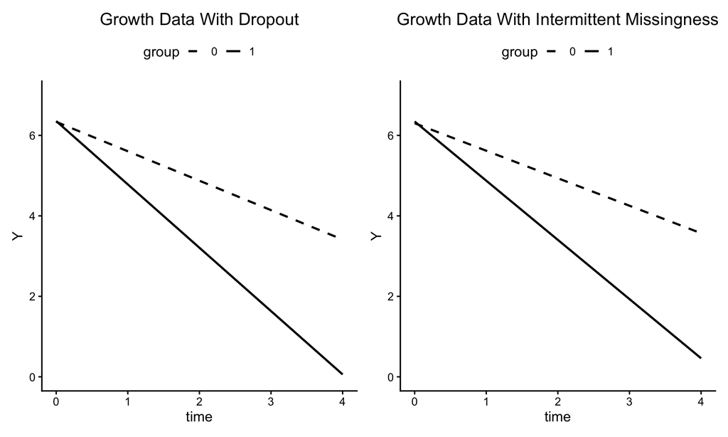

```r
p_growth_d <- plot_means(y ~ time | group, model = model1_gd,
    ylab = "Y", title = "Growth Data With Dropout",
    group_labels = c("0" = "0", "1" = "1"), use_latent_growth = TRUE) + ylim(0, 7) +
    theme(legend.position = "top", legend.justification = "center") +
    scale_linetype_manual(values = c("dashed", "solid"))

p_growth_i <- plot_means(y ~ time | group, model = model1_gi,
    ylab = "Y", title = "Growth Data With Intermittent Missingness",
    group_labels = c("0" = "0", "1" = "1"), use_latent_growth = TRUE) + ylim(0, 7) +
    theme(legend.position = "top", legend.justification = "center") +
    scale_linetype_manual(values = c("dashed", "solid"))

p_growth_d | p_growth_i
```

For the intensive data, the simple slopes come directly from the level-2 estimates: the group-specific intercept is $\gamma_{0\alpha} + \gamma_{1\alpha}(\mathit{GROUP})$ and the group-specific slope is $\gamma_{0\beta} + \gamma_{1\beta}(\mathit{GROUP})$, evaluated over the range of the within-person covariate $X^{w}$ (centered, so 0 is a person’s own mean). The helper below extracts the four coefficients from a fitted model and draws the lines.

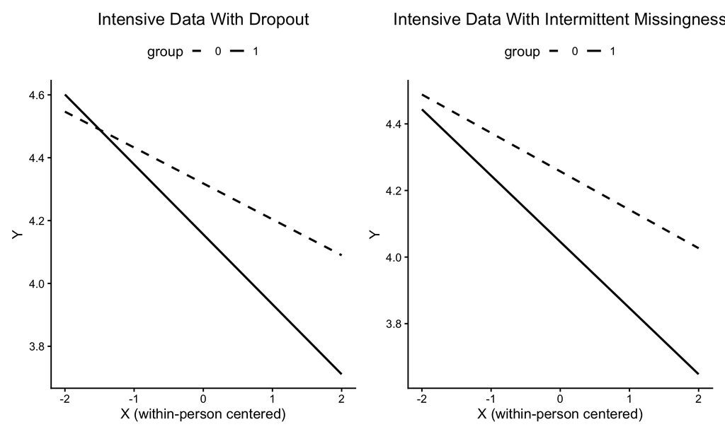

```r
plot_simple_slopes <- function(model, xrange = c(-2, 2), title = NULL, ylab = "Y") {
  est <- model@estimates[, "Estimate"]
  g0a <- est["alpha ~ Intercept"]; g1a <- est["alpha ~ group"]
  g0b <- est["beta ~ Intercept"];  g1b <- est["beta ~ group"]
  xw  <- seq(xrange[1], xrange[2], length.out = 50)
  dat <- rbind(data.frame(xw = xw, group = "0", y = g0a + g0b * xw),
               data.frame(xw = xw, group = "1", y = (g0a + g1a) + (g0b + g1b) * xw))
  ggplot(dat, aes(x = xw, y = y, linetype = group)) +
    geom_line(linewidth = 1) +
    scale_linetype_manual(values = c("0" = "dashed", "1" = "solid")) +
    labs(title = title, x = "X (within-person centered)", y = ylab, linetype = "group") +
    theme_classic(base_size = 14) +
    theme(plot.title = element_text(hjust = 0.5),
          legend.position = "top", legend.justification = "center")
}

p_int_d <- plot_simple_slopes(model1_id, title = "Intensive Data With Dropout")
p_int_i <- plot_simple_slopes(model1_ii, title = "Intensive Data With Intermittent Missingness")

p_int_d | p_int_i
```

The same two functions can be applied to any of the MNAR fits below (for example, `plot_means(y ~ time | group, model = model2_gd, use_latent_growth = TRUE)`) to see how a missingness assumption changes the model-implied trajectories.

## Reading the Output

The table below describes each section of the `rblimp` output in the order it appears. Detailed descriptions of the potential scale reduction (PSR) convergence diagnostic, the model summary tables, and the effective sample size autocorrelation diagnostic follow the table.

| Output Section | Description |
| --- | --- |
| `BURN-IN POTENTIAL SCALE REDUCTION (PSR) OUTPUT` | Assesses whether the MCMC warm-up period is sufficiently long; see detailed description below |
| `DATA INFORMATION` | Gives information about the sample size and missing data rates |
| `MODEL INFORMATION` | Reports the number of parameters and summarizes the fitted regression equations |
| `MODEL FIT` | Reports DIC and WAIC and custom Wald tests, if specified |
| `IMPUTED DATA SUMMARIES` | Reports summary statistics for every manifest and latent variable in the model |
| `CORRELATIONS AMONG RESIDUALS` | Reports correlations between pairs of residuals for a model’s outcome variables |
| `OUTCOME MODEL ESTIMATES` | Parameter estimates, standard errors, credible intervals, and diagnostics; see detailed description below |
| `GENERATED PARAMETERS` | Displays auxiliary parameters that are a function of the estimated parameters (e.g., mean difference, standardized mean difference) |

### PSR Convergence Diagnostic

The potential scale reduction factor (PSRF) or Rhat convergence diagnostic appears near the top of the output. The PSRF assesses whether the MCMC warm-up period is sufficiently long for the algorithm to converge, which occurs when independent chains produce similar parameter estimates. Smaller values closer to the theoretical minimum of 1 are better, and values below 1.05 (Asparouhov & Muthén, 2010) or 1.10 (Gelman et al., 2014) are generally considered adequate. The “Highest PSR” column displays the highest (worst) value across all model parameters. This value should be less than 1.05 (or 1.10) by the end of the burn-in period (the final row of the table). If the highest PSRF is too large, increase the number of burn-in iterations (specified using the `burn` argument).

```
BURN-IN RHAT CONVERGENCE DIAGNOSTIC OUTPUT:

  NOTE: Rank-normalized Rhat (Vehtari et al., 2021) is being used.
        This applies rank normalization and chain folding for robust
        convergence detection across all chains.

  Comparing iterations across 4 chains    Highest Rhat   Parameter #
                           626 to 1250           1.035            15
                          1251 to 2500           1.016            16
                          1876 to 3750           1.007             8
                          2501 to 5000           1.007            16
                          3126 to 6250           1.005            15
                          3751 to 7500           1.006             1
                          4376 to 8750           1.007            16
                          5001 to 10000          1.008            16
                          5626 to 11250          1.003            15
                          6251 to 12500          1.003            15
                          6876 to 13750          1.004            15
                          7501 to 15000          1.004            16
                          8126 to 16250          1.004            15
                          8751 to 17500          1.003             1
                          9376 to 18750          1.005             1
                         10001 to 20000          1.003             1
                         10626 to 21250          1.002            16
                         11251 to 22500          1.003            16
                         11876 to 23750          1.004            16
                         12501 to 25000          1.004             1
```

### Outcome Model Estimates

Each outcome variable has its own summary table containing raw and standardized coefficients, variances and standard deviations, and variance explained effect sizes. The Estimate column gives the point estimates (posterior median), the StdDev column displays “Bayesian standard errors” (posterior standard deviations), the 2.5% and 97.5% columns display 95% credible intervals. The ChiSq and PValue columns are frequentist significance tests (Wald chi-square values).

```
Latent Variable:   alpha

Parameters                         Estimate   StdDev     2.5%    97.5%       ChiSq  PValue     N_Eff
-----------------------------------------------------------------------------------------------------

Variances:
  Residual Var.                       0.330    0.055    0.227    0.442         ---     ---   1405.347

Coefficients:
  Intercept                           6.338    0.059    6.221    6.451   11671.323   0.000   5757.221
  group                               0.019    0.079   -0.134    0.178       0.059   0.809   5251.418

Standard Deviations:
  Residual SD                         0.575    0.048    0.476    0.665         ---     ---   1368.148

Standardized Coefficients:
  group                               0.017    0.069   -0.116    0.153       0.058   0.810   5223.293

Proportion Variance Explained
  by Coefficients                     0.002    0.007    0.000    0.025         ---     ---   9066.038
  by Residual Variation               0.998    0.007    0.975    1.000         ---     ---   9066.038

-----------------------------------------------------------------------------------------------------
```

The tables for alpha (random intercept) and beta (random slope) summarize the focal model’s level-2 regression equations and random coefficient variation. The intensive longitudinal examples add a table for omega (random within-person log-variation). The table for y displays the level-1 (within-person) residual variance.

The table for m displays the missingness model parameters. The missingness model’s pseudo-R2 (the proportion of variance explained on the latent response metric) is often the clearest indicator of model quality. Values around .70 or higher suggest that the predictors almost perfectly classify dropouts from completers, a condition known as near-separation. Very large effect sizes almost always signal that a model lacks support from the data.

### N_Eff Diagnostic

The rightmost column in the parameter summary tables labeled N_Eff is the effective sample size (ESS) diagnostic. The ESS provides a gauge of whether the post-warm-up parameter summaries have sufficient precision. Numerically, it reflects the effective number of MCMC iterations (the “sample size”) that contribute to these summaries after accounting for autocorrelation in the sampling process. Larger values are better, and values above 100 are generally considered adequate (Gelman et al., 2014, p. 287). Inadequate PSRF and ESS values indicate that more iterations are needed.

# Missing Data Indicators

MNAR analyses require a secondary model with a level-1 binary missing data indicator *M* as the outcome of a probit regression. The coding of *M* depends on whether missing data patterns reflect intermittent missingness, attrition, or both (Table 1 in the paper).

**Intermittent missingness** requires a generic indicator that codes whether the outcome is missing at occasion *t* (*M* = 1 if missing, 0 otherwise). Two commands added to a CMAR script create it:

```
TIMEID: time;                 # occasion index
DROPOUT: m = y (missing);     # m = 1 where y is missing, 0 otherwise
```

**Monotone dropout** requires an indicator that signals attrition: all occasions before dropout equal 0, the first missing occasion equals 1, and all later occasions are `NA` (those rows carry no information). The model-predicted probabilities are then the conditional probability of leaving at occasion *t* given participation at *t* – 1, matching hazard probabilities in discrete-time survival models.

```
TIMEID: time;                 # occasion index
DROPOUT: m = y (monotone);    # m = 1 at the first missing occasion, NA afterward
```

In `rblimp` these become `timeid = 'time'` and `dropout = 'm = y (missing)'` or `dropout = 'm = y (monotone)'`. Every model in this tutorial, including the CMAR baselines, carries one of these pairs; the CMAR section explains why. Blimp sorts the data by cluster and time and inserts rows for any occasions that are absent from the file, so lagged variables and the dropout indicator are correctly aligned even when the input data are not time-balanced.

# Modeling Time Trends in Missingness

The validity of any MNAR model hinges on correctly specifying the missingness process. Although that assumption cannot be verified, the missingness model should at least reproduce the observed pattern of missing data rates over time: the latent curve SEMs do so automatically through occasion-specific intercepts, and conditioning on time strengthens the CMAR portion of the model before MNAR terms are added. In stacked data there are two strategies, polynomial functions of time and dummy-coded occasions, and the sections below evaluate both with graphical diagnostics. Following the paper, intermittent missingness is treated first because the dropout models are obtained by fixing or removing parameters from the intermittent specification.

Every model in this section pairs the focal CMAR model with a `missingness:` block. The focal model is unchanged from the CMAR scripts above and is estimated jointly with the missingness model; only the missingness block is new.

## Intermittent Missingness

Intermittent patterns have missing values at every occasion, so the stacked vector of indicators can be partitioned into a between-person component (a person’s overall propensity for missingness) and within-person deviations from it. The recommended starting point is an empty random intercept model that quantifies the two sources.

$$M^*_{ti} = \lambda_0 + u_i + z_{ti},
\qquad u_i \sim \mathcal{N}(0, \sigma^2_u), \quad z_{ti} \sim
\mathcal{N}(0,1), \quad \tau = 0$$

Fixing the threshold at 0 and the within-person variance at 1 identifies the model. The intraclass correlation of the latent response, $\sigma^2_u / (\sigma^2_u + 1)$, is the proportion of variation in missingness propensity that is between persons. The scripts below fit only the missingness model (no focal model is needed for this step).

*Important features of the specification:*

- `m ~ intercept | intercept;` regresses the indicator on a fixed intercept, with a random intercept after the vertical pipe.
- The focal model is omitted, so `LATENT` and `FIXED` are not needed.

### Growth Data

The empty model for the growth data with intermittent missingness.

**Blimp script**

```
DATA: growth-intermittent.csv;     # raw data file
MISSING: NA;                       # missing value code
CLUSTERID: l2id;                   # level-2 identifier
TIMEID: time;                      # occasion index for lags and dropout coding
DROPOUT: m = y (missing);          # missingness indicator (intermittent)
MODEL: m ~ intercept | intercept;
SEED: 90291;                       # random number seed
BURN: 25000;                       # warm-up iterations
ITER: 25000;                       # analysis iterations
```

**rblimp**

```r
icc_gi <- rblimp(
  data = growth_intermittent,
  clusterid = 'l2id',
  timeid = 'time',
  dropout = 'm = y (missing)',
  model = 'm ~ intercept | intercept;',
  seed = 90291,
  burn = 25000,
  iter = 25000)

output(icc_gi)
```

```
---------------------------------------------------------------------------

                                   Blimp
                                   4.0.7

             Blimp was developed with funding from Institute of
           Education Sciences awards R305D150056 and R305D190002.

            Craig K. Enders, P.I. Email: cenders@psych.ucla.edu
           Brian T. Keller, Co-P.I. Email: btkeller@missouri.edu
                 Han Du, Co-P.I. Email: hdu@psych.ucla.edu
                 Roy Levy, Co-P.I. Email: roy.levy@asu.edu

              Programming and Blimp Studio by Brian T. Keller

                   There is no expressed license given.

---------------------------------------------------------------------------


ALGORITHMIC OPTIONS SPECIFIED:

  Imputation method:                 Fully Bayesian model-based
  MCMC algorithm:                    Full conditional Metropolis sampler with
                                       Auto-Derived Conditional Distributions
  Default Priors:
    Multilevel covariance matrices:  Zero matrix, df = -(p + 1) (PRIOR2)
    Outcome covariance matrices:     Zero matrix, df = -(p + 1) (PRIOR2)
    Predictor model variances:       Unit sum of squares, df = 2 (XPRIOR1)
  Chain Starting Values:             Random starting values


  NOTE: For complete list of priors include 'pinfo' in the options.


BURN-IN POTENTIAL SCALE REDUCTION (PSR) OUTPUT:

  NOTE: Rank-normalized Rhat (Vehtari et al., 2021) is being used.
        This applies rank normalization and chain folding for robust
        convergence detection across all chains.
```

[output cut: 105 more lines]

```
  Intercept                          -1.266      0.055     -1.381     -1.166    534.050      0.000   1174.447

Thresholds:
  Tau 1                               0.000      0.000      0.000      0.000        ---        ---        nan

Standard Deviations:
  L2 : SD(Intercept)                  0.633      0.062      0.514      0.761        ---        ---    802.436
  Residual SD                         1.000      0.000      1.000      1.000        ---        ---        nan

Proportion Variance Explained
  by Coefficients                     0.000      0.000      0.000      0.000        ---        ---        nan
  by Level-2 Random Intercepts        0.286      0.040      0.209      0.367        ---        ---    802.297
  by Level-1 Residual Variation       0.714      0.040      0.633      0.791        ---        ---    802.297

                                ------------------------------------------------------------------------------
```

```r
icc_latent(icc_gi)
```

```
[1] 0.286
```

### Intensive Data

The empty model for the intensive data with intermittent missingness.

**Blimp script**

```
DATA: intensive-intermittent.csv;  # raw data file
MISSING: NA;                       # missing value code
CLUSTERID: l2id;                   # level-2 identifier
TIMEID: time;                      # occasion index for lags and dropout coding
DROPOUT: m = y (missing);          # missingness indicator (intermittent)
MODEL: m ~ intercept | intercept;
SEED: 90291;                       # random number seed
BURN: 25000;                       # warm-up iterations
ITER: 25000;                       # analysis iterations
```

**rblimp**

```r
icc_ii <- rblimp(
  data = intensive_intermittent,
  clusterid = 'l2id',
  timeid = 'time',
  dropout = 'm = y (missing)',
  model = 'm ~ intercept | intercept;',
  seed = 90291,
  burn = 25000,
  iter = 25000)

output(icc_ii)
```

```
---------------------------------------------------------------------------

                                   Blimp
                                   4.0.7

             Blimp was developed with funding from Institute of
           Education Sciences awards R305D150056 and R305D190002.

            Craig K. Enders, P.I. Email: cenders@psych.ucla.edu
           Brian T. Keller, Co-P.I. Email: btkeller@missouri.edu
                 Han Du, Co-P.I. Email: hdu@psych.ucla.edu
                 Roy Levy, Co-P.I. Email: roy.levy@asu.edu

              Programming and Blimp Studio by Brian T. Keller

                   There is no expressed license given.

---------------------------------------------------------------------------


ALGORITHMIC OPTIONS SPECIFIED:

  Imputation method:                 Fully Bayesian model-based
  MCMC algorithm:                    Full conditional Metropolis sampler with
                                       Auto-Derived Conditional Distributions
  Default Priors:
    Multilevel covariance matrices:  Zero matrix, df = -(p + 1) (PRIOR2)
    Outcome covariance matrices:     Zero matrix, df = -(p + 1) (PRIOR2)
    Predictor model variances:       Unit sum of squares, df = 2 (XPRIOR1)
  Chain Starting Values:             Random starting values


  NOTE: For complete list of priors include 'pinfo' in the options.


BURN-IN POTENTIAL SCALE REDUCTION (PSR) OUTPUT:

  NOTE: Rank-normalized Rhat (Vehtari et al., 2021) is being used.
        This applies rank normalization and chain folding for robust
        convergence detection across all chains.
```

[output cut: 105 more lines]

```
  Intercept                          -1.249      0.066     -1.385     -1.122    353.819      0.000   1332.840

Thresholds:
  Tau 1                               0.000      0.000      0.000      0.000        ---        ---        nan

Standard Deviations:
  L2 : SD(Intercept)                  0.577      0.064      0.466      0.715        ---        ---   1670.334
  Residual SD                         1.000      0.000      1.000      1.000        ---        ---        nan

Proportion Variance Explained
  by Coefficients                     0.000      0.000      0.000      0.000        ---        ---        nan
  by Level-2 Random Intercepts        0.250      0.041      0.179      0.338        ---        ---   1669.571
  by Level-1 Residual Variation       0.750      0.041      0.662      0.821        ---        ---   1669.571

                                ------------------------------------------------------------------------------
```

```r
icc_latent(icc_ii)
```

```
[1] 0.25
```

### Polynomial and Dummy-Coded Time: Growth Data

The linear model adds a temporal predictor (*TIME* = 0, 1, …, *T* – 1), the grouping variable, and their interaction.

$$M^*_{ti} = \lambda_0 +
\lambda_1(\mathit{GROUP}_i) + \lambda_2(\mathit{TIME}_{ti}) +
\lambda_3(\mathit{GROUP}_i)(\mathit{TIME}_{ti}) + u_i +
z_{ti}$$

On the probability scale, $\lambda_0$ is the baseline missingness rate for *GROUP* = 0, $\lambda_1$ the group difference at baseline, $\lambda_2$ the monotonic change over time for *GROUP* = 0, and $\lambda_3$ the group difference in that change. Because the probit link is S-shaped, a linear model can only produce concave-up probability curves while probabilities stay below .50; the quadratic model relaxes that. The dummy-coded model instead includes *T* – 1 occasion dummy codes and their products with group, reproducing any temporal pattern.

$$M^*_{ti} = \lambda_0 +
\lambda_1(\mathit{GROUP}_i) + \sum_{t=1}^{T-1}\left[\lambda_{t0}(O_{ti})
+ \lambda_{t1}(O_{ti})(\mathit{GROUP}_i)\right] + u_i +
z_{ti}$$

*Important features of the specifications:*

- The three models differ only in the `missingness:` block; the `level2:` and `level1:` blocks are the CMAR growth model.
- `time^2` is the squared occasion index.
- In the dummy-coded model, `{ t in 1:4 } : m ~ (time == [t]) (time == [t])*group;` loops over occasions 1 through 4, adding a Boolean dummy code `(time == t)` and its product with `group` at each pass. This is equivalent to writing out eight terms by hand and mimics the summation in the equation.

#### Linear Time

**Blimp script**

```
DATA: growth-intermittent.csv;                      # raw data file
MISSING: NA;                                        # missing value code
CLUSTERID: l2id;                                    # level-2 identifier
TIMEID: time;                                       # occasion index for lags and dropout coding
DROPOUT: m = y (missing);                           # missingness indicator (intermittent)
LATENT: l2id = alpha beta;                          # level-2 latent variables (random effects)
FIXED: time group;                                  # complete predictors (speeds estimation)
MODEL:
  level2:
  alpha ~ intercept@g0a group@g1a;                  # random intercept equation
  beta ~ intercept@g0b group@g1b;                   # random slope equation
  alpha ~~ beta;                                    # random effect covariance
  level1:
  y ~ intercept@alpha time@beta;                    # level-1 (focal) model
  missingness:
  m ~ intercept time group time*group | intercept;  # missingness model
SEED: 90291;                                        # random number seed
BURN: 25000;                                        # warm-up iterations
ITER: 25000;                                        # analysis iterations
```

**rblimp**

```r
time_linear_gi <- rblimp(
  data = growth_intermittent,
  clusterid = 'l2id',
  timeid = 'time',
  dropout = 'm = y (missing)',
  latent = 'l2id = alpha beta',
  fixed = 'time group',
  model = '
    level2:
    alpha ~ intercept@g0a group@g1a;
    beta ~ intercept@g0b group@g1b;
    alpha ~~ beta;
    level1:
    y ~ intercept@alpha time@beta;
    missingness:
    m ~ intercept time group time*group | intercept;',
  seed = 90291,
  burn = 25000,
  iter = 25000)

output(time_linear_gi)
```

```
---------------------------------------------------------------------------

                                   Blimp
                                   4.0.7

             Blimp was developed with funding from Institute of
           Education Sciences awards R305D150056 and R305D190002.

            Craig K. Enders, P.I. Email: cenders@psych.ucla.edu
           Brian T. Keller, Co-P.I. Email: btkeller@missouri.edu
                 Han Du, Co-P.I. Email: hdu@psych.ucla.edu
                 Roy Levy, Co-P.I. Email: roy.levy@asu.edu

              Programming and Blimp Studio by Brian T. Keller

                   There is no expressed license given.

---------------------------------------------------------------------------


ALGORITHMIC OPTIONS SPECIFIED:

  Imputation method:                 Fully Bayesian model-based
  MCMC algorithm:                    Full conditional Metropolis sampler with
                                       Auto-Derived Conditional Distributions
  Default Priors:
    Multilevel covariance matrices:  Zero matrix, df = -(p + 1) (PRIOR2)
    Outcome covariance matrices:     Zero matrix, df = -(p + 1) (PRIOR2)
    Predictor model variances:       Unit sum of squares, df = 2 (XPRIOR1)
  Chain Starting Values:             Random starting values


  NOTE: For complete list of priors include 'pinfo' in the options.


BURN-IN POTENTIAL SCALE REDUCTION (PSR) OUTPUT:

  NOTE: Rank-normalized Rhat (Vehtari et al., 2021) is being used.
        This applies rank normalization and chain folding for robust
        convergence detection across all chains.
```

[output cut: 241 more lines]

```
Standard Deviations:
  L2 : SD(Intercept)                  0.651      0.067      0.530      0.789        ---        ---    697.278
  Residual SD                         1.000      0.000      1.000      1.000        ---        ---        nan

Standardized Coefficients:
  time                                0.183      0.044      0.096      0.269     17.222      0.000   4356.762
  group                               0.068      0.061     -0.050      0.188      1.272      0.259   3000.492
  time*group                          0.034      0.060     -0.084      0.151      0.328      0.567   4480.601

Proportion Variance Explained
  by Coefficients                     0.051      0.013      0.029      0.080        ---        ---   4087.424
  by Level-2 Random Intercepts        0.282      0.041      0.207      0.366        ---        ---    701.617
  by Level-1 Residual Variation       0.665      0.041      0.584      0.741        ---        ---    728.982

                                ------------------------------------------------------------------------------
```

#### Quadratic Time

**Blimp script**

```
DATA: growth-intermittent.csv;                                          # raw data file
MISSING: NA;                                                            # missing value code
CLUSTERID: l2id;                                                        # level-2 identifier
TIMEID: time;                                                           # occasion index for lags and dropout coding
DROPOUT: m = y (missing);                                               # missingness indicator (intermittent)
LATENT: l2id = alpha beta;                                              # level-2 latent variables (random effects)
FIXED: time group;                                                      # complete predictors (speeds estimation)
MODEL:
  level2:
  alpha ~ 1 group;                                                      # random intercept equation
  beta ~ 1 group;                                                       # random slope equation
  alpha ~~ beta;                                                        # random effect covariance
  level1:
  y ~ intercept@alpha time@beta;                                        # level-1 (focal) model
  missingness:
  m ~ intercept time time^2 group time*group time^2*group | intercept;  # missingness model
SEED: 90291;                                                            # random number seed
BURN: 25000;                                                            # warm-up iterations
ITER: 25000;                                                            # analysis iterations
```

**rblimp**

```r
time_quadratic_gi <- rblimp(
  data = growth_intermittent,
  clusterid = 'l2id',
  timeid = 'time',
  dropout = 'm = y (missing)',
  latent = 'l2id = alpha beta',
  fixed = 'time group',
  model = '
    level2:
    alpha ~ 1 group;
    beta ~ 1 group;
    alpha ~~ beta;
    level1:
    y ~ intercept@alpha time@beta;
    missingness:
    m ~ intercept time time^2 group time*group time^2*group | intercept;',
  seed = 90291,
  burn = 25000,
  iter = 25000)

output(time_quadratic_gi)
```

```
---------------------------------------------------------------------------

                                   Blimp
                                   4.0.7

             Blimp was developed with funding from Institute of
           Education Sciences awards R305D150056 and R305D190002.

            Craig K. Enders, P.I. Email: cenders@psych.ucla.edu
           Brian T. Keller, Co-P.I. Email: btkeller@missouri.edu
                 Han Du, Co-P.I. Email: hdu@psych.ucla.edu
                 Roy Levy, Co-P.I. Email: roy.levy@asu.edu

              Programming and Blimp Studio by Brian T. Keller

                   There is no expressed license given.

---------------------------------------------------------------------------


ALGORITHMIC OPTIONS SPECIFIED:

  Imputation method:                 Fully Bayesian model-based
  MCMC algorithm:                    Full conditional Metropolis sampler with
                                       Auto-Derived Conditional Distributions
  Default Priors:
    Multilevel covariance matrices:  Zero matrix, df = -(p + 1) (PRIOR2)
    Outcome covariance matrices:     Zero matrix, df = -(p + 1) (PRIOR2)
    Predictor model variances:       Unit sum of squares, df = 2 (XPRIOR1)
  Chain Starting Values:             Random starting values


  NOTE: For complete list of priors include 'pinfo' in the options.


BURN-IN POTENTIAL SCALE REDUCTION (PSR) OUTPUT:

  NOTE: Rank-normalized Rhat (Vehtari et al., 2021) is being used.
        This applies rank normalization and chain folding for robust
        convergence detection across all chains.
```

[output cut: 245 more lines]

```
  Residual SD                         1.000      0.000      1.000      1.000        ---        ---        nan

Standardized Coefficients:
  time                                0.409      0.160      0.094      0.719      6.466      0.011   3666.025
  group                               0.076      0.075     -0.069      0.223      1.031      0.310   2808.309
  time^2                             -0.225      0.154     -0.525      0.079      2.141      0.143   4087.388
  time*group                         -0.010      0.215     -0.427      0.415      0.002      0.969   3822.522
  time^2*group                        0.039      0.180     -0.316      0.387      0.044      0.834   4337.262

Proportion Variance Explained
  by Coefficients                     0.060      0.015      0.034      0.091        ---        ---   3584.979
  by Level-2 Random Intercepts        0.284      0.041      0.207      0.366        ---        ---    644.700
  by Level-1 Residual Variation       0.655      0.041      0.573      0.733        ---        ---    680.909

                                ------------------------------------------------------------------------------
```

#### Dummy-Coded Time

**Blimp script**

```
DATA: growth-intermittent.csv;                           # raw data file
MISSING: NA;                                             # missing value code
CLUSTERID: l2id;                                         # level-2 identifier
TIMEID: time;                                            # occasion index for lags and dropout coding
DROPOUT: m = y (missing);                                # missingness indicator (intermittent)
LATENT: l2id = alpha beta;                               # level-2 latent variables (random effects)
FIXED: time group;                                       # complete predictors (speeds estimation)
MODEL:
  level2:
  alpha ~ intercept@g0a group@g1a;                       # random intercept equation
  beta ~ intercept@g0b group@g1b;                        # random slope equation
  alpha ~~ beta;                                         # random effect covariance
  level1:
  y ~ intercept@alpha time@beta;                         # level-1 (focal) model
  missingness:
  m ~ intercept group | intercept;                       # missingness model
  { t in 1:4 } : m ~ (time == [t]) (time == [t])*group;  # loop adds occasion dummy codes
PARAMETERS:                                              # derived quantities (effect sizes)
  diff = (((g0a+g1a)  + 4*(g0b+g1b)) - (g0a + 4*g0b));
  d_diff = diff / sqrt(y.totalvar + alpha.totalvar);
SEED: 90291;                                             # random number seed
BURN: 25000;                                             # warm-up iterations
ITER: 25000;                                             # analysis iterations
```

**rblimp**

```r
time_dummy_gi <- rblimp(
  data = growth_intermittent,
  clusterid = 'l2id',
  timeid = 'time',
  dropout = 'm = y (missing)',
  latent = 'l2id = alpha beta',
  fixed = 'time group',
  model = '
    level2:
    alpha ~ intercept@g0a group@g1a;
    beta ~ intercept@g0b group@g1b;
    alpha ~~ beta;
    level1:
    y ~ intercept@alpha time@beta;
    missingness:
    m ~ intercept group | intercept;
    { t in 1:4 } : m ~ (time == [t]) (time == [t])*group;',
  parameters = '
    diff = (((g0a+g1a)  + 4*(g0b+g1b)) - (g0a + 4*g0b));
    d_diff = diff / sqrt(y.totalvar + alpha.totalvar);',
  seed = 90291,
  burn = 25000,
  iter = 25000)

output(time_dummy_gi)
```

```
---------------------------------------------------------------------------

                                   Blimp
                                   4.0.7

             Blimp was developed with funding from Institute of
           Education Sciences awards R305D150056 and R305D190002.

            Craig K. Enders, P.I. Email: cenders@psych.ucla.edu
           Brian T. Keller, Co-P.I. Email: btkeller@missouri.edu
                 Han Du, Co-P.I. Email: hdu@psych.ucla.edu
                 Roy Levy, Co-P.I. Email: roy.levy@asu.edu

              Programming and Blimp Studio by Brian T. Keller

                   There is no expressed license given.

---------------------------------------------------------------------------


ALGORITHMIC OPTIONS SPECIFIED:

  Imputation method:                 Fully Bayesian model-based
  MCMC algorithm:                    Full conditional Metropolis sampler with
                                       Auto-Derived Conditional Distributions
  Default Priors:
    Multilevel covariance matrices:  Zero matrix, df = -(p + 1) (PRIOR2)
    Outcome covariance matrices:     Zero matrix, df = -(p + 1) (PRIOR2)
    Predictor model variances:       Unit sum of squares, df = 2 (XPRIOR1)
  Chain Starting Values:             Random starting values


  NOTE: For complete list of priors include 'pinfo' in the options.


BURN-IN POTENTIAL SCALE REDUCTION (PSR) OUTPUT:

  NOTE: Rank-normalized Rhat (Vehtari et al., 2021) is being used.
        This applies rank normalization and chain folding for robust
        convergence detection across all chains.
```

[output cut: 275 more lines]

```


GENERATED PARAMETERS:

  Summaries based on 25000 iterations using 4 chains.
  NOTE: Estimate column based on posterior median.


Parameters                         Estimate     StdDev       2.5%      97.5%      ChiSq     PValue      N_Eff
                                ------------------------------------------------------------------------------

  diff                               -3.108      0.162     -3.428     -2.791    367.546      0.000  10109.213
  d_diff                             -1.381      0.071     -1.520     -1.242    381.860      0.000   9944.496

                                ------------------------------------------------------------------------------
```

#### Observed and Predicted Probabilities

The plots compare the observed occasion-specific missing data rates by group with the average individual predicted probabilities from each model (Figure 3, left column, in the paper).

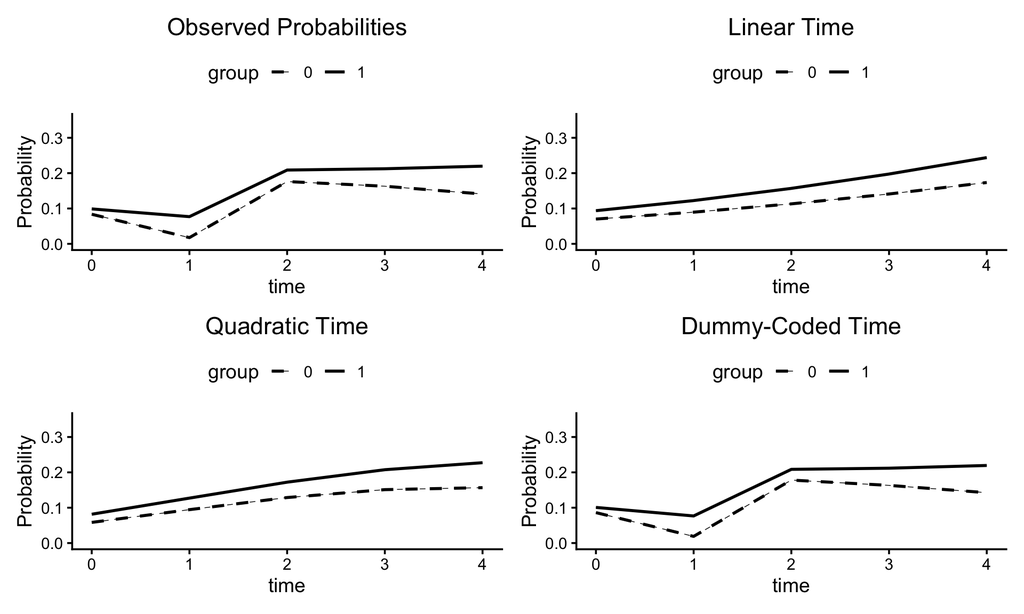

```r
ymin <- 0
ymax <- .35

plot_pmiss_obs_gi <- plot_means(m ~ time | group, model = time_dummy_gi,
    ylab = "Probability", title = "Observed Probabilities",
    group_labels = c("0" = "0", "1" = "1")) + ylim(ymin, ymax) +
    theme(legend.position = "top", legend.justification = "center") +
    scale_linetype_manual(values = c("dashed", "solid")) + geom_line(linewidth = .25)

plot_pmiss_linear_gi <- plot_means(m.1.probability ~ time | group, model = time_linear_gi,
    ylab = "Probability", title = "Linear Time",
    group_labels = c("0" = "0", "1" = "1")) + ylim(ymin, ymax) +
    theme(legend.position = "top", legend.justification = "center") +
    scale_linetype_manual(values = c("dashed", "solid")) + geom_line(linewidth = .25)

plot_pmiss_quadratic_gi <- plot_means(m.1.probability ~ time | group, model = time_quadratic_gi,
    ylab = "Probability", title = "Quadratic Time",
    group_labels = c("0" = "0", "1" = "1")) + ylim(ymin, ymax) +
    theme(legend.position = "top", legend.justification = "center") +
    scale_linetype_manual(values = c("dashed", "solid")) + geom_line(linewidth = .25)

plot_pmiss_dummy_gi <- plot_means(m.1.probability ~ time | group, model = time_dummy_gi,
    ylab = "Probability", title = "Dummy-Coded Time",
    group_labels = c("0" = "0", "1" = "1")) + ylim(ymin, ymax) +
    theme(legend.position = "top", legend.justification = "center") +
    scale_linetype_manual(values = c("dashed", "solid")) + geom_line(linewidth = .25)

(plot_pmiss_obs_gi | plot_pmiss_linear_gi) / (plot_pmiss_quadratic_gi | plot_pmiss_dummy_gi)
```

The table compares the observed probabilities with the average model-predicted probabilities from each specification (RMSE and the minimum, median, mean, and maximum occasion-specific discrepancy).

```r
pmiss_obs       <- aggregate(m ~ time + group,               data = time_dummy_gi@average_imp,     mean)
pmiss_linear    <- aggregate(m.1.probability ~ time + group, data = time_linear_gi@average_imp,    mean)
pmiss_quadratic <- aggregate(m.1.probability ~ time + group, data = time_quadratic_gi@average_imp, mean)
pmiss_dummy     <- aggregate(m.1.probability ~ time + group, data = time_dummy_gi@average_imp,     mean)

dev <- list(Linear    = pmiss_linear$m.1.probability    - pmiss_obs$m,
            Quadratic = pmiss_quadratic$m.1.probability - pmiss_obs$m,
            Dummy     = pmiss_dummy$m.1.probability     - pmiss_obs$m)

miss_fit_gi <- data.frame(
  RMSE   = round(sapply(dev, function(x) sqrt(mean(x^2))), 3),
  Min    = round(sapply(dev, min), 3),
  Median = round(sapply(dev, median), 3),
  Mean   = round(sapply(dev, mean), 3),
  Max    = round(sapply(dev, max), 3))
knitr::kable(miss_fit_gi, caption = "Predicted Minus Observed Missingness Probabilities")
```

Predicted Minus Observed Missingness Probabilities

|  | RMSE | Min | Median | Mean | Max |
| --- | --- | --- | --- | --- | --- |
| Linear | 0.041 | -0.063 | -0.009 | 0.000 | 0.072 |
| Quadratic | 0.037 | -0.047 | -0.008 | 0.001 | 0.077 |
| Dummy | 0.001 | -0.001 | 0.001 | 0.001 | 0.002 |

### Polynomial and Dummy-Coded Time: Intensive Data

The intensive data use the same three specifications. The only change is that the loop runs from *t* = 1 to 19. The dummy-coded model adds a `WALDTEST` command that jointly tests the occasion effects.

#### Linear Time

**Blimp script**

```
DATA: intensive-intermittent.csv;                   # raw data file
MISSING: NA;                                        # missing value code
CLUSTERID: l2id;                                    # level-2 identifier
TIMEID: time;                                       # occasion index for lags and dropout coding
DROPOUT: m = y (missing);                           # missingness indicator (intermittent)
LATENT: l2id = alpha beta omega;                    # level-2 latent variables (random effects)
FIXED: time group;                                  # complete predictors (speeds estimation)
CENTER: groupmean = x;                              # latent group-mean centering of the level-1 covariate
MODEL:
  level2:
  alpha ~ intercept@g0a group@g1a;                  # random intercept equation
  beta ~ intercept@g0b group@g1b;                   # random slope equation
  omega ~ intercept@g0o;                            # log-variance equation
  alpha beta omega ~~ alpha beta omega;             # random effect covariances
  level1:
  y ~ intercept@alpha x@beta;                       # level-1 (focal) model
  var(y) ~ intercept@omega;                         # within-person log-variance model
  missingness:
  m ~ intercept time group time*group | intercept;  # missingness model
SEED: 90291;                                        # random number seed
BURN: 25000;                                        # warm-up iterations
ITER: 25000;                                        # analysis iterations
```

**rblimp**

```r
time_linear_ii <- rblimp(
  data = intensive_intermittent,
  clusterid = 'l2id',
  timeid = 'time',
  dropout = 'm = y (missing)',
  latent = 'l2id = alpha beta omega',
  fixed = 'time group',
  center = 'groupmean = x',
  model = '
    level2:
    alpha ~ intercept@g0a group@g1a;
    beta ~ intercept@g0b group@g1b;
    omega ~ intercept@g0o;
    alpha beta omega ~~ alpha beta omega;
    level1:
    y ~ intercept@alpha x@beta;
    var(y) ~ intercept@omega;
    missingness:
    m ~ intercept time group time*group | intercept;',
  seed = 90291,
  burn = 25000,
  iter = 25000)

output(time_linear_ii)
```

```
---------------------------------------------------------------------------

                                   Blimp
                                   4.0.7

             Blimp was developed with funding from Institute of
           Education Sciences awards R305D150056 and R305D190002.

            Craig K. Enders, P.I. Email: cenders@psych.ucla.edu
           Brian T. Keller, Co-P.I. Email: btkeller@missouri.edu
                 Han Du, Co-P.I. Email: hdu@psych.ucla.edu
                 Roy Levy, Co-P.I. Email: roy.levy@asu.edu

              Programming and Blimp Studio by Brian T. Keller

                   There is no expressed license given.

---------------------------------------------------------------------------


ALGORITHMIC OPTIONS SPECIFIED:

  Imputation method:                 Fully Bayesian model-based
  MCMC algorithm:                    Full conditional Metropolis sampler with
                                       Auto-Derived Conditional Distributions
  Default Priors:
    Multilevel covariance matrices:  Zero matrix, df = -(p + 1) (PRIOR2)
    Outcome covariance matrices:     Zero matrix, df = -(p + 1) (PRIOR2)
    Predictor model variances:       Unit sum of squares, df = 2 (XPRIOR1)
  Chain Starting Values:             Random starting values


  NOTE: For complete list of priors include 'pinfo' in the options.


BURN-IN POTENTIAL SCALE REDUCTION (PSR) OUTPUT:

  NOTE: Rank-normalized Rhat (Vehtari et al., 2021) is being used.
        This applies rank normalization and chain folding for robust
        convergence detection across all chains.
```

[output cut: 329 more lines]

```

Parameters                         Estimate     StdDev       2.5%      97.5%      ChiSq     PValue      N_Eff
                                ------------------------------------------------------------------------------

Grand Mean                            4.012      0.070      3.875      4.149   3324.954      0.000  12615.644

Level 1:
  time                               -0.007      0.004     -0.014      0.001      2.873      0.090  10748.367
  Residual Var.                       1.070      0.034      1.006      1.140        ---        ---   9435.422

Level 2:
  group                              -0.048      0.143     -0.330      0.235      0.113      0.737  12551.917
  Residual Var.                       0.528      0.077      0.401      0.701        ---        ---   7359.967

                                ------------------------------------------------------------------------------
```

#### Quadratic Time

**Blimp script**

```
DATA: intensive-intermittent.csv;                                       # raw data file
MISSING: NA;                                                            # missing value code
CLUSTERID: l2id;                                                        # level-2 identifier
TIMEID: time;                                                           # occasion index for lags and dropout coding
DROPOUT: m = y (missing);                                               # missingness indicator (intermittent)
LATENT: l2id = alpha beta omega;                                        # level-2 latent variables (random effects)
FIXED: time group;                                                      # complete predictors (speeds estimation)
CENTER: groupmean = x;                                                  # latent group-mean centering of the level-1 covariate
MODEL:
  level2:
  alpha ~ intercept@g0a group@g1a;                                      # random intercept equation
  beta ~ intercept@g0b group@g1b;                                       # random slope equation
  omega ~ intercept@g0o;                                                # log-variance equation
  alpha beta omega ~~ alpha beta omega;                                 # random effect covariances
  level1:
  y ~ intercept@alpha x@beta;                                           # level-1 (focal) model
  var(y) ~ intercept@omega;                                             # within-person log-variance model
  missingness:
  m ~ intercept time time^2 group time*group time^2*group | intercept;  # missingness model
SEED: 90291;                                                            # random number seed
BURN: 25000;                                                            # warm-up iterations
ITER: 25000;                                                            # analysis iterations
```

**rblimp**

```r
time_quadratic_ii <- rblimp(
  data = intensive_intermittent,
  clusterid = 'l2id',
  timeid = 'time',
  dropout = 'm = y (missing)',
  latent = 'l2id = alpha beta omega',
  fixed = 'time group',
  center = 'groupmean = x',
  model = '
    level2:
    alpha ~ intercept@g0a group@g1a;
    beta ~ intercept@g0b group@g1b;
    omega ~ intercept@g0o;
    alpha beta omega ~~ alpha beta omega;
    level1:
    y ~ intercept@alpha x@beta;
    var(y) ~ intercept@omega;
    missingness:
    m ~ intercept time time^2 group time*group time^2*group | intercept;',
  seed = 90291,
  burn = 25000,
  iter = 25000)

output(time_quadratic_ii)
```

```
---------------------------------------------------------------------------

                                   Blimp
                                   4.0.7

             Blimp was developed with funding from Institute of
           Education Sciences awards R305D150056 and R305D190002.

            Craig K. Enders, P.I. Email: cenders@psych.ucla.edu
           Brian T. Keller, Co-P.I. Email: btkeller@missouri.edu
                 Han Du, Co-P.I. Email: hdu@psych.ucla.edu
                 Roy Levy, Co-P.I. Email: roy.levy@asu.edu

              Programming and Blimp Studio by Brian T. Keller

                   There is no expressed license given.

---------------------------------------------------------------------------


ALGORITHMIC OPTIONS SPECIFIED:

  Imputation method:                 Fully Bayesian model-based
  MCMC algorithm:                    Full conditional Metropolis sampler with
                                       Auto-Derived Conditional Distributions
  Default Priors:
    Multilevel covariance matrices:  Zero matrix, df = -(p + 1) (PRIOR2)
    Outcome covariance matrices:     Zero matrix, df = -(p + 1) (PRIOR2)
    Predictor model variances:       Unit sum of squares, df = 2 (XPRIOR1)
  Chain Starting Values:             Random starting values


  NOTE: For complete list of priors include 'pinfo' in the options.


BURN-IN POTENTIAL SCALE REDUCTION (PSR) OUTPUT:

  NOTE: Rank-normalized Rhat (Vehtari et al., 2021) is being used.
        This applies rank normalization and chain folding for robust
        convergence detection across all chains.
```

[output cut: 333 more lines]

```

Parameters                         Estimate     StdDev       2.5%      97.5%      ChiSq     PValue      N_Eff
                                ------------------------------------------------------------------------------

Grand Mean                            4.012      0.069      3.877      4.148   3362.355      0.000  12747.175

Level 1:
  time                               -0.007      0.004     -0.014      0.001      2.855      0.091  10784.632
  Residual Var.                       1.071      0.034      1.008      1.139        ---        ---   9753.039

Level 2:
  group                              -0.048      0.141     -0.328      0.226      0.116      0.734  11447.291
  Residual Var.                       0.524      0.077      0.400      0.698        ---        ---   7123.216

                                ------------------------------------------------------------------------------
```

#### Dummy-Coded Time

**Blimp script**

```
DATA: intensive-intermittent.csv;                         # raw data file
MISSING: NA;                                              # missing value code
CLUSTERID: l2id;                                          # level-2 identifier
TIMEID: time;                                             # occasion index for lags and dropout coding
DROPOUT: m = y (missing);                                 # missingness indicator (intermittent)
LATENT: l2id = alpha beta omega;                          # level-2 latent variables (random effects)
FIXED: time group;                                        # complete predictors (speeds estimation)
CENTER: groupmean = x;                                    # latent group-mean centering of the level-1 covariate
MODEL:
  level2:
  alpha ~ intercept@g0a group@g1a;                        # random intercept equation
  beta ~ intercept@g0b group@g1b;                         # random slope equation
  omega ~ intercept@g0o;                                  # log-variance equation
  alpha beta omega ~~ alpha beta omega;                   # random effect covariances
  level1:
  y ~ intercept@alpha x@beta;                             # level-1 (focal) model
  var(y) ~ intercept@omega;                               # within-person log-variance model
  missingness:
  m ~ intercept group | intercept;                        # missingness model
  { t in 1:19 } : m ~ (time == [t]) (time == [t])*group;  # loop adds occasion dummy codes
WALDTEST:                                                 # joint test of occasion effects
  m ~ intercept group | intercept;
  { t in 1:19 } : m ~ (time == [t]);
SEED: 90291;                                              # random number seed
BURN: 25000;                                              # warm-up iterations
ITER: 25000;                                              # analysis iterations
```

**rblimp**

```r
time_dummy_ii <- rblimp(
  data = intensive_intermittent,
  clusterid = 'l2id',
  timeid = 'time',
  dropout = 'm = y (missing)',
  latent = 'l2id = alpha beta omega',
  fixed = 'time group',
  center = 'groupmean = x',
  model = '
    level2:
    alpha ~ intercept@g0a group@g1a;
    beta ~ intercept@g0b group@g1b;
    omega ~ intercept@g0o;
    alpha beta omega ~~ alpha beta omega;
    level1:
    y ~ intercept@alpha x@beta;
    var(y) ~ intercept@omega;
    missingness:
    m ~ intercept group | intercept;
    { t in 1:19 } : m ~ (time == [t]) (time == [t])*group;',
  waldtest = '
    m ~ intercept group | intercept;
    { t in 1:19 } : m ~ (time == [t]);',
  seed = 90291,
  burn = 25000,
  iter = 25000)

output(time_dummy_ii)
```

```
---------------------------------------------------------------------------

                                   Blimp
                                   4.0.7

             Blimp was developed with funding from Institute of
           Education Sciences awards R305D150056 and R305D190002.

            Craig K. Enders, P.I. Email: cenders@psych.ucla.edu
           Brian T. Keller, Co-P.I. Email: btkeller@missouri.edu
                 Han Du, Co-P.I. Email: hdu@psych.ucla.edu
                 Roy Levy, Co-P.I. Email: roy.levy@asu.edu

              Programming and Blimp Studio by Brian T. Keller

                   There is no expressed license given.

---------------------------------------------------------------------------


ALGORITHMIC OPTIONS SPECIFIED:

  Imputation method:                 Fully Bayesian model-based
  MCMC algorithm:                    Full conditional Metropolis sampler with
                                       Auto-Derived Conditional Distributions
  Default Priors:
    Multilevel covariance matrices:  Zero matrix, df = -(p + 1) (PRIOR2)
    Outcome covariance matrices:     Zero matrix, df = -(p + 1) (PRIOR2)
    Predictor model variances:       Unit sum of squares, df = 2 (XPRIOR1)
  Chain Starting Values:             Random starting values


  NOTE: For complete list of priors include 'pinfo' in the options.


BURN-IN POTENTIAL SCALE REDUCTION (PSR) OUTPUT:

  NOTE: Rank-normalized Rhat (Vehtari et al., 2021) is being used.
        This applies rank normalization and chain folding for robust
        convergence detection across all chains.
```

[output cut: 439 more lines]

```

Parameters                         Estimate     StdDev       2.5%      97.5%      ChiSq     PValue      N_Eff
                                ------------------------------------------------------------------------------

Grand Mean                            4.013      0.069      3.877      4.148   3371.193      0.000  11249.483

Level 1:
  time                               -0.007      0.004     -0.014      0.001      2.804      0.094   9818.144
  Residual Var.                       1.071      0.034      1.008      1.139        ---        ---  10275.399

Level 2:
  group                              -0.050      0.141     -0.329      0.228      0.125      0.724  12444.336
  Residual Var.                       0.525      0.076      0.400      0.697        ---        ---   6841.074

                                ------------------------------------------------------------------------------
```

#### Observed and Predicted Probabilities

Figure 3, right column, in the paper.

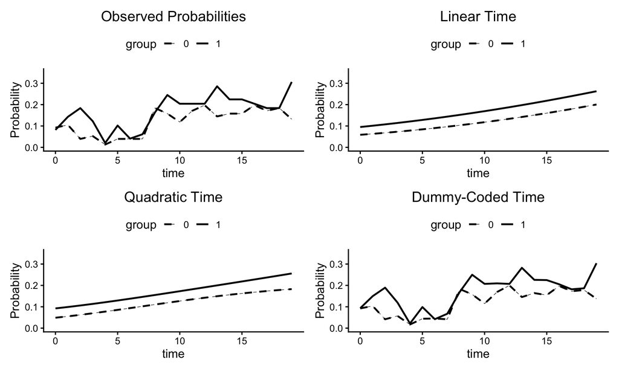

```r
ymin <- 0
ymax <- .35

plot_pmiss_obs_ii <- plot_means(m ~ time | group, model = time_dummy_ii,
    ylab = "Probability", title = "Observed Probabilities",
    group_labels = c("0" = "0", "1" = "1")) + ylim(ymin, ymax) +
    theme(legend.position = "top", legend.justification = "center") +
    scale_linetype_manual(values = c("dashed", "solid")) + geom_line(linewidth = .25)

plot_pmiss_linear_ii <- plot_means(m.1.probability ~ time | group, model = time_linear_ii,
    ylab = "Probability", title = "Linear Time",
    group_labels = c("0" = "0", "1" = "1")) + ylim(ymin, ymax) +
    theme(legend.position = "top", legend.justification = "center") +
    scale_linetype_manual(values = c("dashed", "solid")) + geom_line(linewidth = .25)

plot_pmiss_quadratic_ii <- plot_means(m.1.probability ~ time | group, model = time_quadratic_ii,
    ylab = "Probability", title = "Quadratic Time",
    group_labels = c("0" = "0", "1" = "1")) + ylim(ymin, ymax) +
    theme(legend.position = "top", legend.justification = "center") +
    scale_linetype_manual(values = c("dashed", "solid")) + geom_line(linewidth = .25)

plot_pmiss_dummy_ii <- plot_means(m.1.probability ~ time | group, model = time_dummy_ii,
    ylab = "Probability", title = "Dummy-Coded Time",
    group_labels = c("0" = "0", "1" = "1")) + ylim(ymin, ymax) +
    theme(legend.position = "top", legend.justification = "center") +
    scale_linetype_manual(values = c("dashed", "solid")) + geom_line(linewidth = .25)

(plot_pmiss_obs_ii | plot_pmiss_linear_ii) / (plot_pmiss_quadratic_ii | plot_pmiss_dummy_ii)
```

The table compares the observed probabilities with the average model-predicted probabilities from each specification (RMSE and the minimum, median, mean, and maximum occasion-specific discrepancy).

```r
pmiss_obs       <- aggregate(m ~ time + group,               data = time_dummy_ii@average_imp,     mean)
pmiss_linear    <- aggregate(m.1.probability ~ time + group, data = time_linear_ii@average_imp,    mean)
pmiss_quadratic <- aggregate(m.1.probability ~ time + group, data = time_quadratic_ii@average_imp, mean)
pmiss_dummy     <- aggregate(m.1.probability ~ time + group, data = time_dummy_ii@average_imp,     mean)

dev <- list(Linear    = pmiss_linear$m.1.probability    - pmiss_obs$m,
            Quadratic = pmiss_quadratic$m.1.probability - pmiss_obs$m,
            Dummy     = pmiss_dummy$m.1.probability     - pmiss_obs$m)

miss_fit_ii <- data.frame(
  RMSE   = round(sapply(dev, function(x) sqrt(mean(x^2))), 3),
  Min    = round(sapply(dev, min), 3),
  Median = round(sapply(dev, median), 3),
  Mean   = round(sapply(dev, mean), 3),
  Max    = round(sapply(dev, max), 3))
knitr::kable(miss_fit_ii, caption = "Predicted Minus Observed Missingness Probabilities")
```

Predicted Minus Observed Missingness Probabilities

|  | RMSE | Min | Median | Mean | Max |
| --- | --- | --- | --- | --- | --- |
| Linear | 0.050 | -0.088 | -0.004 | 0.000 | 0.101 |
| Quadratic | 0.049 | -0.086 | -0.004 | 0.001 | 0.101 |
| Dummy | 0.004 | -0.006 | 0.002 | 0.002 | 0.012 |

### Equivalence With IRT Missingness Models

Dummy coding is equivalent to the one- and two-parameter IRT missingness models of Cursio et al. (2019). After removing group effects, the dummy-coded model is a one-parameter IRT model in which the random intercept is the latent propensity and the occasion dummy codes are item difficulties; adding cross-level interactions between the random intercept and the dummy codes gives the two-parameter model with occasion-specific discriminations. The companion document *Dummy-Coded Missingness Models and Their IRT Equivalents* in the repository gives the algebra and fits both models to the intensive data.

## Dropout

Monotone patterns differ from intermittent patterns in two ways. Each person’s dropout vector contains at most one *M* = 1, so there is no within-person variation to support a random intercept, and dropout can only occur after the first measurement. The dropout models therefore omit the random intercept (`| intercept@0`) and the baseline group effect, and they fix the fixed intercept at a value that yields a near-zero probability at baseline: `intercept@-3` gives $\Phi(-3) \approx .0014$ and supports stable estimation. Latent curve SEMs achieve the same thing by omitting the baseline indicator.

$$M^*_{ti} = \lambda_0 +
\lambda_1(\mathit{TIME}_{ti}) +
\lambda_2(\mathit{GROUP}_i)(\mathit{TIME}_{ti}) + z_{ti}$$

$$M^*_{ti} = \lambda_0 +
\sum_{t=1}^{T-1}\left[\lambda_{t0}(O_{ti}) +
\lambda_{t1}(O_{ti})(\mathit{GROUP}_i)\right] + z_{ti}$$

*Important features of the specifications:*

- `dropout = 'm = y (monotone)'` creates the attrition indicator.
- `intercept@-3` fixes the fixed intercept; `| intercept@0` fixes the random intercept variance to zero. The `@` symbol fixes a parameter at the value that follows it.
- The group main effect is omitted because it is not estimable at baseline, where nobody has dropped out.

### Polynomial and Dummy-Coded Time: Growth Data

#### Linear Time

**Blimp script**

```
DATA: growth-dropout.csv;                                # raw data file
MISSING: NA;                                             # missing value code
CLUSTERID: l2id;                                         # level-2 identifier
TIMEID: time;                                            # occasion index for lags and dropout coding
DROPOUT: m = y (monotone);                               # dropout indicator (monotone)
LATENT: l2id = alpha beta;                               # level-2 latent variables (random effects)
FIXED: time group;                                       # complete predictors (speeds estimation)
MODEL:
  level2:
  alpha ~ intercept group;                               # random intercept equation
  beta ~ intercept group;                                # random slope equation
  alpha ~~ beta;                                         # random effect covariance
  level1:
  y ~ intercept@alpha time@beta;                         # level-1 (focal) model
  missingness:
  m ~ intercept@-3 time@b1 time*group@b2 | intercept@0;  # missingness model
SEED: 90291;                                             # random number seed
BURN: 25000;                                             # warm-up iterations
ITER: 25000;                                             # analysis iterations
```

**rblimp**

```r
time_linear_gd <- rblimp(
  data = growth_dropout,
  clusterid = 'l2id',
  timeid = 'time',
  dropout = 'm = y (monotone)',
  latent = 'l2id = alpha beta',
  fixed = 'time group',
  model = '
    level2:
    alpha ~ intercept group;
    beta ~ intercept group;
    alpha ~~ beta;
    level1:
    y ~ intercept@alpha time@beta;
    missingness:
    m ~ intercept@-3 time@b1 time*group@b2 | intercept@0;',
  seed = 90291,
  burn = 25000,
  iter = 25000)

output(time_linear_gd)
```

```
---------------------------------------------------------------------------

                                   Blimp
                                   4.0.7

             Blimp was developed with funding from Institute of
           Education Sciences awards R305D150056 and R305D190002.

            Craig K. Enders, P.I. Email: cenders@psych.ucla.edu
           Brian T. Keller, Co-P.I. Email: btkeller@missouri.edu
                 Han Du, Co-P.I. Email: hdu@psych.ucla.edu
                 Roy Levy, Co-P.I. Email: roy.levy@asu.edu

              Programming and Blimp Studio by Brian T. Keller

                   There is no expressed license given.

---------------------------------------------------------------------------


ALGORITHMIC OPTIONS SPECIFIED:

  Imputation method:                 Fully Bayesian model-based
  MCMC algorithm:                    Full conditional Metropolis sampler with
                                       Auto-Derived Conditional Distributions
  Default Priors:
    Multilevel covariance matrices:  Zero matrix, df = -(p + 1) (PRIOR2)
    Outcome covariance matrices:     Zero matrix, df = -(p + 1) (PRIOR2)
    Predictor model variances:       Unit sum of squares, df = 2 (XPRIOR1)
  Chain Starting Values:             Random starting values


  NOTE: For complete list of priors include 'pinfo' in the options.


BURN-IN POTENTIAL SCALE REDUCTION (PSR) OUTPUT:

  NOTE: Rank-normalized Rhat (Vehtari et al., 2021) is being used.
        This applies rank normalization and chain folding for robust
        convergence detection across all chains.
```

[output cut: 234 more lines]

```
Thresholds:
  Tau 1                               0.000      0.000      0.000      0.000        ---        ---        nan

Standard Deviations:
  Residual SD                         1.000      0.000      1.000      1.000        ---        ---        nan

Standardized Coefficients:
  time                                0.657      0.017      0.623      0.689   1508.203      0.000   7667.083
  time*group                          0.062      0.027      0.009      0.115      5.348      0.021   7960.069

Proportion Variance Explained
  by Coefficients                     0.478      0.010      0.457      0.497        ---        ---   8464.619
  by Residual Variation               0.522      0.010      0.503      0.543        ---        ---   8464.619

                                ------------------------------------------------------------------------------
```

#### Quadratic Time

**Blimp script**

```
DATA: growth-dropout.csv;                                              # raw data file
MISSING: NA;                                                           # missing value code
CLUSTERID: l2id;                                                       # level-2 identifier
TIMEID: time;                                                          # occasion index for lags and dropout coding
DROPOUT: m = y (monotone);                                             # dropout indicator (monotone)
LATENT: l2id = alpha beta;                                             # level-2 latent variables (random effects)
FIXED: time group;                                                     # complete predictors (speeds estimation)
MODEL:
  level2:
  alpha ~ intercept group;                                             # random intercept equation
  beta ~ intercept group;                                              # random slope equation
  alpha ~~ beta;                                                       # random effect covariance
  level1:
  y ~ intercept@alpha time@beta;                                       # level-1 (focal) model
  missingness:
  m ~ intercept@-3 time time^2 time*group time^2*group | intercept@0;  # missingness model
SEED: 90291;                                                           # random number seed
BURN: 25000;                                                           # warm-up iterations
ITER: 25000;                                                           # analysis iterations
```

**rblimp**

```r
time_quadratic_gd <- rblimp(
  data = growth_dropout,
  clusterid = 'l2id',
  timeid = 'time',
  dropout = 'm = y (monotone)',
  latent = 'l2id = alpha beta',
  fixed = 'time group',
  model = '
    level2:
    alpha ~ intercept group;
    beta ~ intercept group;
    alpha ~~ beta;
    level1:
    y ~ intercept@alpha time@beta;
    missingness:
    m ~ intercept@-3 time time^2 time*group time^2*group | intercept@0;',
  seed = 90291,
  burn = 25000,
  iter = 25000)

output(time_quadratic_gd)
```

```
---------------------------------------------------------------------------

                                   Blimp
                                   4.0.7

             Blimp was developed with funding from Institute of
           Education Sciences awards R305D150056 and R305D190002.

            Craig K. Enders, P.I. Email: cenders@psych.ucla.edu
           Brian T. Keller, Co-P.I. Email: btkeller@missouri.edu
                 Han Du, Co-P.I. Email: hdu@psych.ucla.edu
                 Roy Levy, Co-P.I. Email: roy.levy@asu.edu

              Programming and Blimp Studio by Brian T. Keller

                   There is no expressed license given.

---------------------------------------------------------------------------


ALGORITHMIC OPTIONS SPECIFIED:

  Imputation method:                 Fully Bayesian model-based
  MCMC algorithm:                    Full conditional Metropolis sampler with
                                       Auto-Derived Conditional Distributions
  Default Priors:
    Multilevel covariance matrices:  Zero matrix, df = -(p + 1) (PRIOR2)
    Outcome covariance matrices:     Zero matrix, df = -(p + 1) (PRIOR2)
    Predictor model variances:       Unit sum of squares, df = 2 (XPRIOR1)
  Chain Starting Values:             Random starting values


  NOTE: For complete list of priors include 'pinfo' in the options.


BURN-IN POTENTIAL SCALE REDUCTION (PSR) OUTPUT:

  NOTE: Rank-normalized Rhat (Vehtari et al., 2021) is being used.
        This applies rank normalization and chain folding for robust
        convergence detection across all chains.
```

[output cut: 238 more lines]

```

Standard Deviations:
  Residual SD                         1.000      0.000      1.000      1.000        ---        ---        nan

Standardized Coefficients:
  time                                1.525      0.084      1.357      1.688    326.961      0.000   6147.019
  time^2                             -1.021      0.103     -1.224     -0.819     98.879      0.000   6234.153
  time*group                          0.560      0.106      0.350      0.765     27.817      0.000   6482.571
  time^2*group                       -0.569      0.115     -0.791     -0.342     24.456      0.000   6213.602

Proportion Variance Explained
  by Coefficients                     0.459      0.009      0.441      0.477        ---        ---   8018.618
  by Residual Variation               0.541      0.009      0.523      0.559        ---        ---   8018.618

                                ------------------------------------------------------------------------------
```

#### Dummy-Coded Time

**Blimp script**

```
DATA: growth-dropout.csv;                                # raw data file
MISSING: NA;                                             # missing value code
CLUSTERID: l2id;                                         # level-2 identifier
TIMEID: time;                                            # occasion index for lags and dropout coding
DROPOUT: m = y (monotone);                               # dropout indicator (monotone)
LATENT: l2id = alpha beta;                               # level-2 latent variables (random effects)
FIXED: time group;                                       # complete predictors (speeds estimation)
MODEL:
  level2:
  alpha ~ intercept@g0a group@g1a;                       # random intercept equation
  beta ~ intercept@g0b group@g1b;                        # random slope equation
  alpha ~~ beta;                                         # random effect covariance
  level1:
  y ~ intercept@alpha time@beta;                         # level-1 (focal) model
  missingness:
  m ~ intercept@-3 | intercept@0;                        # missingness model
  { t in 1:4 } : m ~ (time == [t]) (time == [t])*group;  # loop adds occasion dummy codes
PARAMETERS:                                              # derived quantities (effect sizes)
  diff = (((g0a+g1a)  + 4*(g0b+g1b)) - (g0a + 4*g0b));
  d_diff = diff / sqrt(y.totalvar + alpha.totalvar);
SEED: 90291;                                             # random number seed
BURN: 25000;                                             # warm-up iterations
ITER: 25000;                                             # analysis iterations
```

**rblimp**

```r
time_dummy_gd <- rblimp(
  data = growth_dropout,
  clusterid = 'l2id',
  timeid = 'time',
  dropout = 'm = y (monotone)',
  latent = 'l2id = alpha beta',
  fixed = 'time group',
  model = '
    level2:
    alpha ~ intercept@g0a group@g1a;
    beta ~ intercept@g0b group@g1b;
    alpha ~~ beta;
    level1:
    y ~ intercept@alpha time@beta;
    missingness:
    m ~ intercept@-3 | intercept@0;
    { t in 1:4 } : m ~ (time == [t]) (time == [t])*group;',
  parameters = '
    diff = (((g0a+g1a)  + 4*(g0b+g1b)) - (g0a + 4*g0b));
    d_diff = diff / sqrt(y.totalvar + alpha.totalvar);',
  seed = 90291,
  burn = 25000,
  iter = 25000)

output(time_dummy_gd)
```

```
---------------------------------------------------------------------------

                                   Blimp
                                   4.0.7

             Blimp was developed with funding from Institute of
           Education Sciences awards R305D150056 and R305D190002.

            Craig K. Enders, P.I. Email: cenders@psych.ucla.edu
           Brian T. Keller, Co-P.I. Email: btkeller@missouri.edu
                 Han Du, Co-P.I. Email: hdu@psych.ucla.edu
                 Roy Levy, Co-P.I. Email: roy.levy@asu.edu

              Programming and Blimp Studio by Brian T. Keller

                   There is no expressed license given.

---------------------------------------------------------------------------


ALGORITHMIC OPTIONS SPECIFIED:

  Imputation method:                 Fully Bayesian model-based
  MCMC algorithm:                    Full conditional Metropolis sampler with
                                       Auto-Derived Conditional Distributions
  Default Priors:
    Multilevel covariance matrices:  Zero matrix, df = -(p + 1) (PRIOR2)
    Outcome covariance matrices:     Zero matrix, df = -(p + 1) (PRIOR2)
    Predictor model variances:       Unit sum of squares, df = 2 (XPRIOR1)
  Chain Starting Values:             Random starting values


  NOTE: For complete list of priors include 'pinfo' in the options.


BURN-IN POTENTIAL SCALE REDUCTION (PSR) OUTPUT:

  NOTE: Rank-normalized Rhat (Vehtari et al., 2021) is being used.
        This applies rank normalization and chain folding for robust
        convergence detection across all chains.
```

[output cut: 268 more lines]

```


GENERATED PARAMETERS:

  Summaries based on 25000 iterations using 4 chains.
  NOTE: Estimate column based on posterior median.


Parameters                         Estimate     StdDev       2.5%      97.5%      ChiSq     PValue      N_Eff
                                ------------------------------------------------------------------------------

  diff                               -3.351      0.188     -3.716     -2.976    317.646      0.000   6037.519
  d_diff                             -1.518      0.082     -1.678     -1.356    342.152      0.000   7023.936

                                ------------------------------------------------------------------------------
```

#### Observed and Predicted Probabilities

Figure 4, left column, in the paper. The rates are conditional dropout probabilities given participation at the prior occasion.

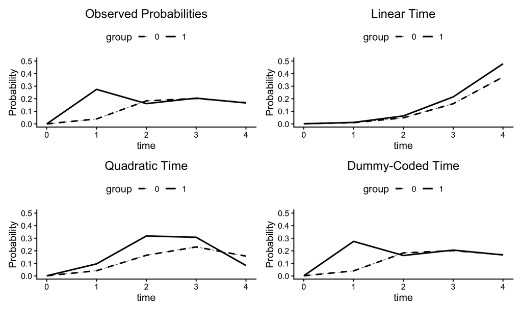

```r
ymin <- 0
ymax <- .5

plot_pmiss_obs_gd <- plot_means(m ~ time | group, model = time_dummy_gd,
    ylab = "Probability", title = "Observed Probabilities",
    group_labels = c("0" = "0", "1" = "1")) + ylim(ymin, ymax) +
    theme(legend.position = "top", legend.justification = "center") +
    scale_linetype_manual(values = c("dashed", "solid")) + geom_line(linewidth = .25)

plot_pmiss_linear_gd <- plot_means(m.1.probability ~ time | group, model = time_linear_gd,
    ylab = "Probability", title = "Linear Time",
    group_labels = c("0" = "0", "1" = "1")) + ylim(ymin, ymax) +
    theme(legend.position = "top", legend.justification = "center") +
    scale_linetype_manual(values = c("dashed", "solid")) + geom_line(linewidth = .25)

plot_pmiss_quadratic_gd <- plot_means(m.1.probability ~ time | group, model = time_quadratic_gd,
    ylab = "Probability", title = "Quadratic Time",
    group_labels = c("0" = "0", "1" = "1")) + ylim(ymin, ymax) +
    theme(legend.position = "top", legend.justification = "center") +
    scale_linetype_manual(values = c("dashed", "solid")) + geom_line(linewidth = .25)

plot_pmiss_dummy_gd <- plot_means(m.1.probability ~ time | group, model = time_dummy_gd,
    ylab = "Probability", title = "Dummy-Coded Time",
    group_labels = c("0" = "0", "1" = "1")) + ylim(ymin, ymax) +
    theme(legend.position = "top", legend.justification = "center") +
    scale_linetype_manual(values = c("dashed", "solid")) + geom_line(linewidth = .25)

(plot_pmiss_obs_gd | plot_pmiss_linear_gd) / (plot_pmiss_quadratic_gd | plot_pmiss_dummy_gd)
```

The table compares the observed probabilities with the average model-predicted probabilities from each specification (RMSE and the minimum, median, mean, and maximum occasion-specific discrepancy).

```r
pmiss_obs       <- aggregate(m ~ time + group,               data = time_dummy_gd@average_imp,     mean)
pmiss_linear    <- aggregate(m.1.probability ~ time + group, data = time_linear_gd@average_imp,    mean)
pmiss_quadratic <- aggregate(m.1.probability ~ time + group, data = time_quadratic_gd@average_imp, mean)
pmiss_dummy     <- aggregate(m.1.probability ~ time + group, data = time_dummy_gd@average_imp,     mean)

dev <- list(Linear    = pmiss_linear$m.1.probability    - pmiss_obs$m,
            Quadratic = pmiss_quadratic$m.1.probability - pmiss_obs$m,
            Dummy     = pmiss_dummy$m.1.probability     - pmiss_obs$m)

miss_fit_gd <- data.frame(
  RMSE   = round(sapply(dev, function(x) sqrt(mean(x^2))), 3),
  Min    = round(sapply(dev, min), 3),
  Median = round(sapply(dev, median), 3),
  Mean   = round(sapply(dev, mean), 3),
  Max    = round(sapply(dev, max), 3))
knitr::kable(miss_fit_gd, caption = "Predicted Minus Observed Missingness Probabilities")
```

Predicted Minus Observed Missingness Probabilities

|  | RMSE | Min | Median | Mean | Max |
| --- | --- | --- | --- | --- | --- |
| Linear | 0.154 | -0.263 | -0.014 | -0.004 | 0.312 |
| Quadratic | 0.087 | -0.179 | 0.001 | 0.000 | 0.156 |
| Dummy | 0.001 | -0.001 | 0.001 | 0.000 | 0.001 |

### Polynomial and Dummy-Coded Time: Intensive Data

In the intensive data the first seven occasions are complete, so dropout rates jump from zero at *t* = 7. Modeling this requires a dummy variable *D* that equals 0 before *t* = 7 and 1 thereafter; products with *D* switch the time effects on at occasions where dropout can occur.

$$M^*_{ti} = \lambda_0 +
\sum_{t=1}^{T-1}\left[\lambda_{t0}(O_{ti})(D_{ti}) +
\lambda_{t1}(O_{ti})(\mathit{GROUP}_i)(D_{ti})\right] +
z_{ti}$$

*Important features of the specifications:*

- `d = ifelse(time < 7, 0, 1);` is a definition variable: an expression substituted into the equations that follow, not a new random variable.
- In the polynomial models, `(time - 7)` restarts the time index at the switch point, and every term is multiplied by `d`.
- In the dummy-coded model, the loop runs from 1 to 19 but every dummy code is multiplied by `d`, so occasions 1–6 contribute nothing.
- `nimps = 20` in the polynomial models saves 20 imputed data sets; the other scripts rely on the default. The plotting function averages the saved predicted probabilities either way.

#### Linear Time

**Blimp script**

```
DATA: intensive-dropout.csv;                                                 # raw data file
MISSING: NA;                                                                 # missing value code
CLUSTERID: l2id;                                                             # level-2 identifier
TIMEID: time;                                                                # occasion index for lags and dropout coding
DROPOUT: m = y (monotone);                                                   # dropout indicator (monotone)
LATENT: l2id = alpha beta omega;                                             # level-2 latent variables (random effects)
FIXED: time group;                                                           # complete predictors (speeds estimation)
CENTER: groupmean = x;                                                       # latent group-mean centering of the level-1 covariate
MODEL:
  level2:
  alpha ~ intercept@g0a group@g1a;                                           # random intercept equation
  beta ~ intercept@g0b group@g1b;                                            # random slope equation
  omega ~ intercept@g0o;                                                     # log-variance equation
  alpha beta omega ~~ alpha beta omega;                                      # random effect covariances
  level1:
  y ~ intercept@alpha x@beta;                                                # level-1 (focal) model
  var(y) ~ intercept@omega;                                                  # within-person log-variance model
  missingness:
  d = ifelse(time < 7, 0, 1);                                                # definition variable: switch dummy code
  m ~ intercept@-3 d group*d (time - 7)*d (time - 7)*group*d | intercept@0;  # missingness model
SEED: 90291;                                                                 # random number seed
BURN: 25000;                                                                 # warm-up iterations
ITER: 25000;                                                                 # analysis iterations
NIMPS: 20;                                                                   # imputations saved for plotting
```

**rblimp**

```r
time_linear_id <- rblimp(
  data = intensive_dropout,
  clusterid = 'l2id',
  timeid = 'time',
  dropout = 'm = y (monotone)',
  latent = 'l2id = alpha beta omega',
  fixed = 'time group',
  center = 'groupmean = x',
  model = '
    level2:
    alpha ~ intercept@g0a group@g1a;
    beta ~ intercept@g0b group@g1b;
    omega ~ intercept@g0o;
    alpha beta omega ~~ alpha beta omega;
    level1:
    y ~ intercept@alpha x@beta;
    var(y) ~ intercept@omega;
    missingness:
    d = ifelse(time < 7, 0, 1);
    m ~ intercept@-3 d group*d (time - 7)*d (time - 7)*group*d | intercept@0;',
  seed = 90291,
  burn = 25000,
  iter = 25000,
  nimps = 20)

output(time_linear_id)
```

```
---------------------------------------------------------------------------

                                   Blimp
                                   4.0.7

             Blimp was developed with funding from Institute of
           Education Sciences awards R305D150056 and R305D190002.

            Craig K. Enders, P.I. Email: cenders@psych.ucla.edu
           Brian T. Keller, Co-P.I. Email: btkeller@missouri.edu
                 Han Du, Co-P.I. Email: hdu@psych.ucla.edu
                 Roy Levy, Co-P.I. Email: roy.levy@asu.edu

              Programming and Blimp Studio by Brian T. Keller

                   There is no expressed license given.

---------------------------------------------------------------------------


ALGORITHMIC OPTIONS SPECIFIED:

  Imputation method:                 Fully Bayesian model-based
  MCMC algorithm:                    Full conditional Metropolis sampler with
                                       Auto-Derived Conditional Distributions
  Default Priors:
    Multilevel covariance matrices:  Zero matrix, df = -(p + 1) (PRIOR2)
    Outcome covariance matrices:     Zero matrix, df = -(p + 1) (PRIOR2)
    Predictor model variances:       Unit sum of squares, df = 2 (XPRIOR1)
  Chain Starting Values:             Random starting values


  NOTE: For complete list of priors include 'pinfo' in the options.


BURN-IN POTENTIAL SCALE REDUCTION (PSR) OUTPUT:

  NOTE: Rank-normalized Rhat (Vehtari et al., 2021) is being used.
        This applies rank normalization and chain folding for robust
        convergence detection across all chains.
```

[output cut: 329 more lines]

```

Parameters                         Estimate     StdDev       2.5%      97.5%      ChiSq     PValue      N_Eff
                                ------------------------------------------------------------------------------

Grand Mean                            3.975      0.071      3.834      4.113   3149.840      0.000  12113.719

Level 1:
  time                               -0.011      0.004     -0.019     -0.002      5.861      0.015  12533.330
  Residual Var.                       1.080      0.035      1.014      1.152        ---        ---  15052.420

Level 2:
  group                              -0.074      0.144     -0.353      0.209      0.260      0.610  13368.877
  Residual Var.                       0.539      0.080      0.407      0.718        ---        ---   8511.318

                                ------------------------------------------------------------------------------
```

#### Quadratic Time

**Blimp script**

```
DATA: intensive-dropout.csv;                                                                                     # raw data file
MISSING: NA;                                                                                                     # missing value code
CLUSTERID: l2id;                                                                                                 # level-2 identifier
TIMEID: time;                                                                                                    # occasion index for lags and dropout coding
DROPOUT: m = y (monotone);                                                                                       # dropout indicator (monotone)
LATENT: l2id = alpha beta omega;                                                                                 # level-2 latent variables (random effects)
FIXED: time group;                                                                                               # complete predictors (speeds estimation)
CENTER: groupmean = x;                                                                                           # latent group-mean centering of the level-1 covariate
MODEL:
  level2:
  alpha ~ intercept@g0a group@g1a;                                                                               # random intercept equation
  beta ~ intercept@g0b group@g1b;                                                                                # random slope equation
  omega ~ intercept@g0o;                                                                                         # log-variance equation
  alpha beta omega ~~ alpha beta omega;                                                                          # random effect covariances
  level1:
  y ~ intercept@alpha x@beta;                                                                                    # level-1 (focal) model
  var(y) ~ intercept@omega;                                                                                      # within-person log-variance model
  missingness:
  d = ifelse(time < 7, 0, 1);                                                                                    # definition variable: switch dummy code
  m ~ intercept@-3 d group*d (time - 7)*d (time - 7)^2*d (time - 7)*group*d (time - 7)^2*group*d | intercept@0;  # missingness model
SEED: 90291;                                                                                                     # random number seed
BURN: 25000;                                                                                                     # warm-up iterations
ITER: 25000;                                                                                                     # analysis iterations
NIMPS: 20;                                                                                                       # imputations saved for plotting
```

**rblimp**

```r
time_quadratic_id <- rblimp(
  data = intensive_dropout,
  clusterid = 'l2id',
  timeid = 'time',
  dropout = 'm = y (monotone)',
  latent = 'l2id = alpha beta omega',
  fixed = 'time group',
  center = 'groupmean = x',
  model = '
    level2:
    alpha ~ intercept@g0a group@g1a;
    beta ~ intercept@g0b group@g1b;
    omega ~ intercept@g0o;
    alpha beta omega ~~ alpha beta omega;
    level1:
    y ~ intercept@alpha x@beta;
    var(y) ~ intercept@omega;
    missingness:
    d = ifelse(time < 7, 0, 1);
    m ~ intercept@-3 d group*d (time - 7)*d (time - 7)^2*d (time - 7)*group*d (time - 7)^2*group*d | intercept@0;',
  seed = 90291,
  burn = 25000,
  iter = 25000,
  nimps = 20)

output(time_quadratic_id)
```

```
---------------------------------------------------------------------------

                                   Blimp
                                   4.0.7

             Blimp was developed with funding from Institute of
           Education Sciences awards R305D150056 and R305D190002.

            Craig K. Enders, P.I. Email: cenders@psych.ucla.edu
           Brian T. Keller, Co-P.I. Email: btkeller@missouri.edu
                 Han Du, Co-P.I. Email: hdu@psych.ucla.edu
                 Roy Levy, Co-P.I. Email: roy.levy@asu.edu

              Programming and Blimp Studio by Brian T. Keller

                   There is no expressed license given.

---------------------------------------------------------------------------


ALGORITHMIC OPTIONS SPECIFIED:

  Imputation method:                 Fully Bayesian model-based
  MCMC algorithm:                    Full conditional Metropolis sampler with
                                       Auto-Derived Conditional Distributions
  Default Priors:
    Multilevel covariance matrices:  Zero matrix, df = -(p + 1) (PRIOR2)
    Outcome covariance matrices:     Zero matrix, df = -(p + 1) (PRIOR2)
    Predictor model variances:       Unit sum of squares, df = 2 (XPRIOR1)
  Chain Starting Values:             Random starting values


  NOTE: For complete list of priors include 'pinfo' in the options.


BURN-IN POTENTIAL SCALE REDUCTION (PSR) OUTPUT:

  NOTE: Rank-normalized Rhat (Vehtari et al., 2021) is being used.
        This applies rank normalization and chain folding for robust
        convergence detection across all chains.
```

[output cut: 334 more lines]

```

Parameters                         Estimate     StdDev       2.5%      97.5%      ChiSq     PValue      N_Eff
                                ------------------------------------------------------------------------------

Grand Mean                            3.974      0.071      3.835      4.111   3175.700      0.000  11851.553

Level 1:
  time                               -0.011      0.004     -0.019     -0.002      5.911      0.015  12332.501
  Residual Var.                       1.081      0.035      1.016      1.151        ---        ---  14131.915

Level 2:
  group                              -0.076      0.144     -0.360      0.209      0.279      0.597  13193.074
  Residual Var.                       0.539      0.080      0.407      0.723        ---        ---   7766.853

                                ------------------------------------------------------------------------------
```

#### Dummy-Coded Time

**Blimp script**

```
DATA: intensive-dropout.csv;                                  # raw data file
MISSING: NA;                                                  # missing value code
CLUSTERID: l2id;                                              # level-2 identifier
TIMEID: time;                                                 # occasion index for lags and dropout coding
DROPOUT: m = y (monotone);                                    # dropout indicator (monotone)
LATENT: l2id = alpha beta omega;                              # level-2 latent variables (random effects)
FIXED: time group;                                            # complete predictors (speeds estimation)
CENTER: groupmean = x;                                        # latent group-mean centering of the level-1 covariate
MODEL:
  level2:
  alpha ~ intercept@g0a group@g1a;                            # random intercept equation
  beta ~ intercept@g0b group@g1b;                             # random slope equation
  omega ~ intercept@g0o;                                      # log-variance equation
  alpha beta omega ~~ alpha beta omega;                       # random effect covariances
  level1:
  y ~ intercept@alpha x@beta;                                 # level-1 (focal) model
  var(y) ~ intercept@omega;                                   # within-person log-variance model
  missingness:
  d = ifelse(time < 7, 0, 1);                                 # definition variable: switch dummy code
  m ~ intercept@-3 | intercept@0;                             # missingness model
  { t in 1:19 } : m ~ (time == [t])*d (time == [t])*group*d;  # loop adds occasion dummy codes
SEED: 90291;                                                  # random number seed
BURN: 25000;                                                  # warm-up iterations
ITER: 25000;                                                  # analysis iterations
```

**rblimp**

```r
time_dummy_id <- rblimp(
  data = intensive_dropout,
  clusterid = 'l2id',
  timeid = 'time',
  dropout = 'm = y (monotone)',
  latent = 'l2id = alpha beta omega',
  fixed = 'time group',
  center = 'groupmean = x',
  model = '
    level2:
    alpha ~ intercept@g0a group@g1a;
    beta ~ intercept@g0b group@g1b;
    omega ~ intercept@g0o;
    alpha beta omega ~~ alpha beta omega;
    level1:
    y ~ intercept@alpha x@beta;
    var(y) ~ intercept@omega;
    missingness:
    d = ifelse(time < 7, 0, 1);
    m ~ intercept@-3 | intercept@0;
    { t in 1:19 } : m ~ (time == [t])*d (time == [t])*group*d;',
  seed = 90291,
  burn = 25000,
  iter = 25000)

output(time_dummy_id)
```

```
---------------------------------------------------------------------------

                                   Blimp
                                   4.0.7

             Blimp was developed with funding from Institute of
           Education Sciences awards R305D150056 and R305D190002.

            Craig K. Enders, P.I. Email: cenders@psych.ucla.edu
           Brian T. Keller, Co-P.I. Email: btkeller@missouri.edu
                 Han Du, Co-P.I. Email: hdu@psych.ucla.edu
                 Roy Levy, Co-P.I. Email: roy.levy@asu.edu

              Programming and Blimp Studio by Brian T. Keller

                   There is no expressed license given.

---------------------------------------------------------------------------


ALGORITHMIC OPTIONS SPECIFIED:

  Imputation method:                 Fully Bayesian model-based
  MCMC algorithm:                    Full conditional Metropolis sampler with
                                       Auto-Derived Conditional Distributions
  Default Priors:
    Multilevel covariance matrices:  Zero matrix, df = -(p + 1) (PRIOR2)
    Outcome covariance matrices:     Zero matrix, df = -(p + 1) (PRIOR2)
    Predictor model variances:       Unit sum of squares, df = 2 (XPRIOR1)
  Chain Starting Values:             Random starting values


  NOTE: For complete list of priors include 'pinfo' in the options.


BURN-IN POTENTIAL SCALE REDUCTION (PSR) OUTPUT:

  NOTE: Rank-normalized Rhat (Vehtari et al., 2021) is being used.
        This applies rank normalization and chain folding for robust
        convergence detection across all chains.
```

[output cut: 409 more lines]

```

Parameters                         Estimate     StdDev       2.5%      97.5%      ChiSq     PValue      N_Eff
                                ------------------------------------------------------------------------------

Grand Mean                            3.973      0.070      3.836      4.111   3190.339      0.000  12009.272

Level 1:
  time                               -0.011      0.004     -0.019     -0.002      5.830      0.016  11131.172
  Residual Var.                       1.081      0.035      1.015      1.152        ---        ---  13870.293

Level 2:
  group                              -0.074      0.144     -0.357      0.206      0.270      0.603  12481.606
  Residual Var.                       0.539      0.079      0.409      0.718        ---        ---   7641.347

                                ------------------------------------------------------------------------------
```

#### Observed and Predicted Probabilities

Figure 4, right column, in the paper.

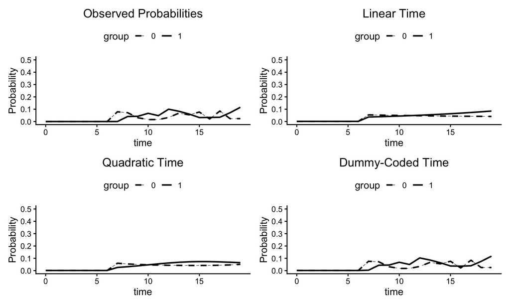

```r
ymin <- 0
ymax <- .5

plot_pmiss_obs_id <- plot_means(m ~ time | group, model = time_dummy_id,
    ylab = "Probability", title = "Observed Probabilities",
    group_labels = c("0" = "0", "1" = "1")) + ylim(ymin, ymax) +
    theme(legend.position = "top", legend.justification = "center") +
    scale_linetype_manual(values = c("dashed", "solid")) + geom_line(linewidth = .25)

plot_pmiss_linear_id <- plot_means(m.1.probability ~ time | group, model = time_linear_id,
    ylab = "Probability", title = "Linear Time",
    group_labels = c("0" = "0", "1" = "1")) + ylim(ymin, ymax) +
    theme(legend.position = "top", legend.justification = "center") +
    scale_linetype_manual(values = c("dashed", "solid")) + geom_line(linewidth = .25)

plot_pmiss_quadratic_id <- plot_means(m.1.probability ~ time | group, model = time_quadratic_id,
    ylab = "Probability", title = "Quadratic Time",
    group_labels = c("0" = "0", "1" = "1")) + ylim(ymin, ymax) +
    theme(legend.position = "top", legend.justification = "center") +
    scale_linetype_manual(values = c("dashed", "solid")) + geom_line(linewidth = .25)

plot_pmiss_dummy_id <- plot_means(m.1.probability ~ time | group, model = time_dummy_id,
    ylab = "Probability", title = "Dummy-Coded Time",
    group_labels = c("0" = "0", "1" = "1")) + ylim(ymin, ymax) +
    theme(legend.position = "top", legend.justification = "center") +
    scale_linetype_manual(values = c("dashed", "solid")) + geom_line(linewidth = .25)

(plot_pmiss_obs_id | plot_pmiss_linear_id) / (plot_pmiss_quadratic_id | plot_pmiss_dummy_id)
```

The table compares the observed probabilities with the average model-predicted probabilities from each specification (RMSE and the minimum, median, mean, and maximum occasion-specific discrepancy).

```r
pmiss_obs       <- aggregate(m ~ time + group,               data = time_dummy_id@average_imp,     mean)
pmiss_linear    <- aggregate(m.1.probability ~ time + group, data = time_linear_id@average_imp,    mean)
pmiss_quadratic <- aggregate(m.1.probability ~ time + group, data = time_quadratic_id@average_imp, mean)
pmiss_dummy     <- aggregate(m.1.probability ~ time + group, data = time_dummy_id@average_imp,     mean)

dev <- list(Linear    = pmiss_linear$m.1.probability    - pmiss_obs$m,
            Quadratic = pmiss_quadratic$m.1.probability - pmiss_obs$m,
            Dummy     = pmiss_dummy$m.1.probability     - pmiss_obs$m)

miss_fit_id <- data.frame(
  RMSE   = round(sapply(dev, function(x) sqrt(mean(x^2))), 3),
  Min    = round(sapply(dev, min), 3),
  Median = round(sapply(dev, median), 3),
  Mean   = round(sapply(dev, mean), 3),
  Max    = round(sapply(dev, max), 3))
knitr::kable(miss_fit_id, caption = "Predicted Minus Observed Missingness Probabilities")
```

Predicted Minus Observed Missingness Probabilities

|  | RMSE | Min | Median | Mean | Max |
| --- | --- | --- | --- | --- | --- |
| Linear | 0.021 | -0.049 | 0.001 | 0.001 | 0.039 |
| Quadratic | 0.022 | -0.051 | 0.001 | 0.001 | 0.041 |
| Dummy | 0.002 | -0.003 | 0.001 | 0.002 | 0.006 |

# Shared Parameter Models

The defining feature of the Wu–Carroll (1988) shared parameter model is that the random effects of the focal model appear as predictors in the missingness model. Because the same latent variables drive both the outcome and nonresponse, they induce an association between *Y* and *M*. Any random effect in the focal model can play this role, which makes the model readily applicable to intensive repeated measures data. All models continue to use dummy-coded time. Results for every model are collected in the Sensitivity Analysis Results section.

## Growth Data With Dropout

With attrition, the first occasion is structurally complete. The SEM omits the first dropout indicator; the MLM instead needs a time-varying dummy variable *D* (0 at baseline, 1 afterward) whose products with the random effects switch their influence on at occasions where dropout can occur.

$$M^*_{ti} = \lambda_0 +
\sum_{t=1}^{T-1}\left[\lambda_{t0}(O_{ti}) +
\lambda_{t1}(O_{ti})(\mathit{GROUP}_i)\right] +
\lambda_1(\alpha_i)(D_{ti}) + \lambda_2(\beta_i)(D_{ti}) +
z_{ti}$$

The $\lambda_1$ and $\lambda_2$ terms induce the MNAR mechanism. The fixed intercept of –3 plays the role of omitting the baseline indicator, the occasion dummy codes allow occasion-specific dropout rates, and the interactions with *D* confine the random effects to post-baseline occasions, so the model is fully equivalent to the latent curve shared parameter model.

### Model 2: Random Effects Predicting Attrition

The missingness block adds the switched random effects to the dummy-coded dropout model from the previous section.

*Important features of the specification:*

- `d = ifelse(time < 1, 0, 1);` defines the switch (0 at baseline, 1 afterward).
- `alpha*d beta*d` are the random intercept and slope, activated after baseline.
- The `level2:` labels `@g0a`, `@g1a`, `@g0b`, `@g1b` are used by `PARAMETERS` and, in Model 4, by the residual definition variables.

**Blimp script**

```
DATA: growth-dropout.csv;                                # raw data file
MISSING: NA;                                             # missing value code
CLUSTERID: l2id;                                         # level-2 identifier
TIMEID: time;                                            # occasion index for lags and dropout coding
DROPOUT: m = y (monotone);                               # dropout indicator (monotone)
LATENT: l2id = alpha beta;                               # level-2 latent variables (random effects)
FIXED: group time;                                       # complete predictors (speeds estimation)
MODEL:
  level2:
  alpha ~ intercept@g0a group@g1a;                       # random intercept equation
  beta ~ intercept@g0b group@g1b;                        # random slope equation
  alpha ~~ beta;                                         # random effect covariance
  level1:
  y ~ intercept@alpha time@beta;                         # level-1 (focal) model
  missingness:
  d = ifelse(time < 1, 0, 1);                            # definition variable: switch dummy code
  m ~ intercept@-3 alpha*d beta*d | intercept@0;         # missingness model
  { t in 1:4 } : m ~ (time == [t]) (time == [t])*group;  # loop adds occasion dummy codes
PARAMETERS:                                              # derived quantities (effect sizes)
  diff = (((g0a+g1a)  + 4*(g0b+g1b)) - (g0a + 4*g0b));
  d_diff = diff / sqrt(y.totalvar + alpha.totalvar);
SEED: 90291;                                             # random number seed
BURN: 25000;                                             # warm-up iterations
ITER: 25000;                                             # analysis iterations
```

**rblimp**

```r
model2_gd <- rblimp(
  data = growth_dropout,
  clusterid = 'l2id',
  timeid = 'time',
  dropout = 'm = y (monotone)',
  latent = 'l2id = alpha beta',
  fixed = 'group time',
  model = '
    level2:
    alpha ~ intercept@g0a group@g1a;
    beta ~ intercept@g0b group@g1b;
    alpha ~~ beta;
    level1:
    y ~ intercept@alpha time@beta;
    missingness:
    d = ifelse(time < 1, 0, 1);
    m ~ intercept@-3 alpha*d beta*d | intercept@0;
    { t in 1:4 } : m ~ (time == [t]) (time == [t])*group;',
  parameters = '
    diff = (((g0a+g1a)  + 4*(g0b+g1b)) - (g0a + 4*g0b));
    d_diff = diff / sqrt(y.totalvar + alpha.totalvar);',
  seed = 90291,
  burn = 25000,
  iter = 25000)

output(model2_gd)
```

```
---------------------------------------------------------------------------

                                   Blimp
                                   4.0.7

             Blimp was developed with funding from Institute of
           Education Sciences awards R305D150056 and R305D190002.

            Craig K. Enders, P.I. Email: cenders@psych.ucla.edu
           Brian T. Keller, Co-P.I. Email: btkeller@missouri.edu
                 Han Du, Co-P.I. Email: hdu@psych.ucla.edu
                 Roy Levy, Co-P.I. Email: roy.levy@asu.edu

              Programming and Blimp Studio by Brian T. Keller

                   There is no expressed license given.

---------------------------------------------------------------------------


ALGORITHMIC OPTIONS SPECIFIED:

  Imputation method:                 Fully Bayesian model-based
  MCMC algorithm:                    Full conditional Metropolis sampler with
                                       Auto-Derived Conditional Distributions
  Default Priors:
    Multilevel covariance matrices:  Zero matrix, df = -(p + 1) (PRIOR2)
    Outcome covariance matrices:     Zero matrix, df = -(p + 1) (PRIOR2)
    Predictor model variances:       Unit sum of squares, df = 2 (XPRIOR1)
  Chain Starting Values:             Random starting values


  NOTE: For complete list of priors include 'pinfo' in the options.


BURN-IN POTENTIAL SCALE REDUCTION (PSR) OUTPUT:

  NOTE: Rank-normalized Rhat (Vehtari et al., 2021) is being used.
        This applies rank normalization and chain folding for robust
        convergence detection across all chains.
```

[output cut: 276 more lines]

```


GENERATED PARAMETERS:

  Summaries based on 25000 iterations using 4 chains.
  NOTE: Estimate column based on posterior median.


Parameters                         Estimate     StdDev       2.5%      97.5%      ChiSq     PValue      N_Eff
                                ------------------------------------------------------------------------------

  diff                               -3.095      0.205     -3.489     -2.685    226.803      0.000   3504.913
  d_diff                             -1.424      0.092     -1.601     -1.241    241.452      0.000   4174.722

                                ------------------------------------------------------------------------------
```

### Model 3: Random Effects and Their Squares Predicting Attrition

A linear specification lets only one tail of the random effect distribution predict higher nonresponse. Adding squared random effects allows attrition to depend on both tails (for example, both rapid improvers and non-responders disengaging). Nonlinear effects of latent variables are computationally demanding and may require larger samples.

*Important features of the specification:*

- `alpha*d^2` and `beta*d^2` are the squared random effects; because `d` is 0 or 1, `d^2 = d`, and the terms are the squares of `alpha` and `beta` activated after baseline.

**Blimp script**

```
DATA: growth-dropout.csv;                                            # raw data file
MISSING: NA;                                                         # missing value code
CLUSTERID: l2id;                                                     # level-2 identifier
TIMEID: time;                                                        # occasion index for lags and dropout coding
DROPOUT: m = y (monotone);                                           # dropout indicator (monotone)
LATENT: l2id = alpha beta;                                           # level-2 latent variables (random effects)
FIXED: group time;                                                   # complete predictors (speeds estimation)
MODEL:
  level2:
  alpha ~ intercept@g0a group@g1a;                                   # random intercept equation
  beta ~ intercept@g0b group@g1b;                                    # random slope equation
  alpha ~~ beta;                                                     # random effect covariance
  level1:
  y ~ intercept@alpha time@beta;                                     # level-1 (focal) model
  missingness:
  d = ifelse(time < 1, 0, 1);                                        # definition variable: switch dummy code
  m ~ intercept@-3 alpha*d alpha*d^2 beta*d beta*d^2 | intercept@0;  # missingness model
  { t in 1:4 } : m ~ (time == [t]) (time == [t])*group;              # loop adds occasion dummy codes
PARAMETERS:                                                          # derived quantities (effect sizes)
  diff = (((g0a+g1a)  + 4*(g0b+g1b)) - (g0a + 4*g0b));
  d_diff = diff / sqrt(y.totalvar + alpha.totalvar);
SEED: 90291;                                                         # random number seed
BURN: 25000;                                                         # warm-up iterations
ITER: 25000;                                                         # analysis iterations
```

**rblimp**

```r
model3_gd <- rblimp(
  data = growth_dropout,
  clusterid = 'l2id',
  timeid = 'time',
  dropout = 'm = y (monotone)',
  latent = 'l2id = alpha beta',
  fixed = 'group time',
  model = '
    level2:
    alpha ~ intercept@g0a group@g1a;
    beta ~ intercept@g0b group@g1b;
    alpha ~~ beta;
    level1:
    y ~ intercept@alpha time@beta;
    missingness:
    d = ifelse(time < 1, 0, 1);
    m ~ intercept@-3 alpha*d alpha*d^2 beta*d beta*d^2 | intercept@0;
    { t in 1:4 } : m ~ (time == [t]) (time == [t])*group;',
  parameters = '
    diff = (((g0a+g1a)  + 4*(g0b+g1b)) - (g0a + 4*g0b));
    d_diff = diff / sqrt(y.totalvar + alpha.totalvar);',
  seed = 90291,
  burn = 25000,
  iter = 25000)

output(model3_gd)
```

```
---------------------------------------------------------------------------

                                   Blimp
                                   4.0.7

             Blimp was developed with funding from Institute of
           Education Sciences awards R305D150056 and R305D190002.

            Craig K. Enders, P.I. Email: cenders@psych.ucla.edu
           Brian T. Keller, Co-P.I. Email: btkeller@missouri.edu
                 Han Du, Co-P.I. Email: hdu@psych.ucla.edu
                 Roy Levy, Co-P.I. Email: roy.levy@asu.edu

              Programming and Blimp Studio by Brian T. Keller

                   There is no expressed license given.

---------------------------------------------------------------------------


ALGORITHMIC OPTIONS SPECIFIED:

  Imputation method:                 Fully Bayesian model-based
  MCMC algorithm:                    Full conditional Metropolis sampler with
                                       Auto-Derived Conditional Distributions
  Default Priors:
    Multilevel covariance matrices:  Zero matrix, df = -(p + 1) (PRIOR2)
    Outcome covariance matrices:     Zero matrix, df = -(p + 1) (PRIOR2)
    Predictor model variances:       Unit sum of squares, df = 2 (XPRIOR1)
  Chain Starting Values:             Random starting values


  NOTE: For complete list of priors include 'pinfo' in the options.


BURN-IN POTENTIAL SCALE REDUCTION (PSR) OUTPUT:

  NOTE: Rank-normalized Rhat (Vehtari et al., 2021) is being used.
        This applies rank normalization and chain folding for robust
        convergence detection across all chains.
```

[output cut: 280 more lines]

```


GENERATED PARAMETERS:

  Summaries based on 25000 iterations using 4 chains.
  NOTE: Estimate column based on posterior median.


Parameters                         Estimate     StdDev       2.5%      97.5%      ChiSq     PValue      N_Eff
                                ------------------------------------------------------------------------------

  diff                               -3.093      0.203     -3.492     -2.693    232.530      0.000   4508.792
  d_diff                             -1.424      0.090     -1.600     -1.245    247.723      0.000   5329.046

                                ------------------------------------------------------------------------------
```

### Model 4: Random Effect Residuals Predicting Attrition

When the focal model includes predictors of the random effects, as it does here, `alpha` and `beta` in the missingness model are composites that include the group effect, so $\lambda_1$ and $\lambda_2$ are not pure estimates of MNAR signal. The alternative uses the level-2 residuals, isolating the component of each random effect that is orthogonal to its predictors. The residuals are computed at every MCMC iteration from the current random effects and the current level-2 coefficients.

$$\zeta_{\alpha i} = \alpha_i -
\left[\gamma_{0\alpha} + \gamma_{1\alpha}(\mathit{GROUP}_i)\right]
\qquad \zeta_{\beta i} = \beta_i - \left[\gamma_{0\beta} +
\gamma_{1\beta}(\mathit{GROUP}_i)\right]$$

*Important features of the specification:*

- `alpha_res = alpha - (g0a + g1a*group);` and `beta_res = ...` are definition variables that subtract the level-2 predicted values; the labels `g0a`, `g1a`, `g0b`, `g1b` refer to the coefficients named in the `level2:` block.
- This model needed 100,000 iterations to reach adequate diagnostics.

**Blimp script**

```
DATA: growth-dropout.csv;                                 # raw data file
MISSING: NA;                                              # missing value code
CLUSTERID: l2id;                                          # level-2 identifier
TIMEID: time;                                             # occasion index for lags and dropout coding
DROPOUT: m = y (monotone);                                # dropout indicator (monotone)
LATENT: l2id = alpha beta;                                # level-2 latent variables (random effects)
FIXED: group time;                                        # complete predictors (speeds estimation)
MODEL:
  level2:
  alpha ~ intercept@g0a group@g1a;                        # random intercept equation
  beta ~ intercept@g0b group@g1b;                         # random slope equation
  alpha ~~ beta;                                          # random effect covariance
  level1:
  y ~ intercept@alpha time@beta;                          # level-1 (focal) model
  missingness:
  alpha_res = alpha - (g0a + g1a*group);                  # definition variable: intercept residual
  beta_res = beta - (g0b + g1b*group);                    # definition variable: slope residual
  d = ifelse(time < 1, 0, 1);                             # definition variable: switch dummy code
  m ~ intercept@-3 alpha_res*d beta_res*d | intercept@0;  # missingness model
  { t in 1:4 } : m ~ (time == [t]) (time == [t])*group;   # loop adds occasion dummy codes
PARAMETERS:                                               # derived quantities (effect sizes)
  diff = (((g0a+g1a)  + 4*(g0b+g1b)) - (g0a + 4*g0b));
  d_diff = diff / sqrt(y.totalvar + alpha.totalvar);
SEED: 90291;                                              # random number seed
BURN: 100000;                                             # warm-up iterations
ITER: 100000;                                             # analysis iterations
```

**rblimp**

```r
model4_gd <- rblimp(
  data = growth_dropout,
  clusterid = 'l2id',
  timeid = 'time',
  dropout = 'm = y (monotone)',
  latent = 'l2id = alpha beta',
  fixed = 'group time',
  model = '
    level2:
    alpha ~ intercept@g0a group@g1a;
    beta ~ intercept@g0b group@g1b;
    alpha ~~ beta;
    level1:
    y ~ intercept@alpha time@beta;
    missingness:
    alpha_res = alpha - (g0a + g1a*group);
    beta_res = beta - (g0b + g1b*group);
    d = ifelse(time < 1, 0, 1);
    m ~ intercept@-3 alpha_res*d beta_res*d | intercept@0;
    { t in 1:4 } : m ~ (time == [t]) (time == [t])*group;',
  parameters = '
    diff = (((g0a+g1a)  + 4*(g0b+g1b)) - (g0a + 4*g0b));
    d_diff = diff / sqrt(y.totalvar + alpha.totalvar);',
  seed = 90291,
  burn = 100000,
  iter = 100000)

output(model4_gd)
```

```
---------------------------------------------------------------------------

                                   Blimp
                                   4.0.7

             Blimp was developed with funding from Institute of
           Education Sciences awards R305D150056 and R305D190002.

            Craig K. Enders, P.I. Email: cenders@psych.ucla.edu
           Brian T. Keller, Co-P.I. Email: btkeller@missouri.edu
                 Han Du, Co-P.I. Email: hdu@psych.ucla.edu
                 Roy Levy, Co-P.I. Email: roy.levy@asu.edu

              Programming and Blimp Studio by Brian T. Keller

                   There is no expressed license given.

---------------------------------------------------------------------------


ALGORITHMIC OPTIONS SPECIFIED:

  Imputation method:                 Fully Bayesian model-based
  MCMC algorithm:                    Full conditional Metropolis sampler with
                                       Auto-Derived Conditional Distributions
  Default Priors:
    Multilevel covariance matrices:  Zero matrix, df = -(p + 1) (PRIOR2)
    Outcome covariance matrices:     Zero matrix, df = -(p + 1) (PRIOR2)
    Predictor model variances:       Unit sum of squares, df = 2 (XPRIOR1)
  Chain Starting Values:             Random starting values


  NOTE: For complete list of priors include 'pinfo' in the options.


BURN-IN POTENTIAL SCALE REDUCTION (PSR) OUTPUT:

  NOTE: Rank-normalized Rhat (Vehtari et al., 2021) is being used.
        This applies rank normalization and chain folding for robust
        convergence detection across all chains.
```

[output cut: 278 more lines]

```


GENERATED PARAMETERS:

  Summaries based on 100000 iterations using 4 chains.
  NOTE: Estimate column based on posterior median.


Parameters                         Estimate     StdDev       2.5%      97.5%      ChiSq     PValue      N_Eff
                                ------------------------------------------------------------------------------

  diff                               -3.108      0.200     -3.498     -2.714    242.511      0.000   7187.043
  d_diff                             -1.447      0.090     -1.622     -1.267    256.113      0.000   7007.153

                                ------------------------------------------------------------------------------
```

## Growth Data With Intermittent Missingness

With missingness at every occasion, the random effects can influence nonresponse over the whole study, so no switch is needed. The fixed intercept is estimable, the group main effect returns, and a random intercept allows person-level missingness propensities to vary.

$$M^*_{ti} = \lambda_0 +
\lambda_1(\mathit{GROUP}_i) + \sum_{t=1}^{T-1}\left[\lambda_{t0}(O_{ti})
+ \lambda_{t1}(O_{ti})(\mathit{GROUP}_i)\right] + \lambda_2(\alpha_i) +
\lambda_3(\beta_i) + u_i + z_{ti}$$

### Model 2: Random Effects Predicting Missingness

The missingness block adds `alpha` and `beta` to the dummy-coded intermittent model.

*Important features of the specification:*

- `m ~ intercept group alpha beta | intercept;` – all parameters are free, including the random intercept after the pipe.

**Blimp script**

```
DATA: growth-intermittent.csv;                           # raw data file
MISSING: NA;                                             # missing value code
CLUSTERID: l2id;                                         # level-2 identifier
TIMEID: time;                                            # occasion index for lags and dropout coding
DROPOUT: m = y (missing);                                # missingness indicator (intermittent)
LATENT: l2id = alpha beta;                               # level-2 latent variables (random effects)
FIXED: group time;                                       # complete predictors (speeds estimation)
MODEL:
  level2:
  alpha ~ intercept@g0a group@g1a;                       # random intercept equation
  beta ~ intercept@g0b group@g1b;                        # random slope equation
  alpha ~~ beta;                                         # random effect covariance
  level1:
  y ~ intercept@alpha time@beta;                         # level-1 (focal) model
  missingness:
  m ~ intercept group alpha beta | intercept;            # missingness model
  { t in 1:4 } : m ~ (time == [t]) (time == [t])*group;  # loop adds occasion dummy codes
PARAMETERS:                                              # derived quantities (effect sizes)
  diff = (((g0a+g1a)  + 4*(g0b+g1b)) - (g0a + 4*g0b));
  d_diff = diff / sqrt(y.totalvar + alpha.totalvar);
SEED: 90291;                                             # random number seed
BURN: 25000;                                             # warm-up iterations
ITER: 25000;                                             # analysis iterations
```

**rblimp**

```r
model2_gi <- rblimp(
  data = growth_intermittent,
  clusterid = 'l2id',
  timeid = 'time',
  dropout = 'm = y (missing)',
  latent = 'l2id = alpha beta',
  fixed = 'group time',
  model = '
    level2:
    alpha ~ intercept@g0a group@g1a;
    beta ~ intercept@g0b group@g1b;
    alpha ~~ beta;
    level1:
    y ~ intercept@alpha time@beta;
    missingness:
    m ~ intercept group alpha beta | intercept;
    { t in 1:4 } : m ~ (time == [t]) (time == [t])*group;',
  parameters = '
    diff = (((g0a+g1a)  + 4*(g0b+g1b)) - (g0a + 4*g0b));
    d_diff = diff / sqrt(y.totalvar + alpha.totalvar);',
  seed = 90291,
  burn = 25000,
  iter = 25000)

output(model2_gi)
```

```
---------------------------------------------------------------------------

                                   Blimp
                                   4.0.7

             Blimp was developed with funding from Institute of
           Education Sciences awards R305D150056 and R305D190002.

            Craig K. Enders, P.I. Email: cenders@psych.ucla.edu
           Brian T. Keller, Co-P.I. Email: btkeller@missouri.edu
                 Han Du, Co-P.I. Email: hdu@psych.ucla.edu
                 Roy Levy, Co-P.I. Email: roy.levy@asu.edu

              Programming and Blimp Studio by Brian T. Keller

                   There is no expressed license given.

---------------------------------------------------------------------------


ALGORITHMIC OPTIONS SPECIFIED:

  Imputation method:                 Fully Bayesian model-based
  MCMC algorithm:                    Full conditional Metropolis sampler with
                                       Auto-Derived Conditional Distributions
  Default Priors:
    Multilevel covariance matrices:  Zero matrix, df = -(p + 1) (PRIOR2)
    Outcome covariance matrices:     Zero matrix, df = -(p + 1) (PRIOR2)
    Predictor model variances:       Unit sum of squares, df = 2 (XPRIOR1)
  Chain Starting Values:             Random starting values


  NOTE: For complete list of priors include 'pinfo' in the options.


BURN-IN POTENTIAL SCALE REDUCTION (PSR) OUTPUT:

  NOTE: Rank-normalized Rhat (Vehtari et al., 2021) is being used.
        This applies rank normalization and chain folding for robust
        convergence detection across all chains.
```

[output cut: 280 more lines]

```


GENERATED PARAMETERS:

  Summaries based on 25000 iterations using 4 chains.
  NOTE: Estimate column based on posterior median.


Parameters                         Estimate     StdDev       2.5%      97.5%      ChiSq     PValue      N_Eff
                                ------------------------------------------------------------------------------

  diff                               -3.077      0.163     -3.394     -2.755    356.654      0.000   9840.350
  d_diff                             -1.374      0.071     -1.511     -1.233    370.394      0.000  10080.321

                                ------------------------------------------------------------------------------
```

### Model 3: Random Effects and Their Squares Predicting Missingness

Squared random effects allow both tails of the distribution to predict missingness.

*Important features of the specification:*

- `alpha^2` and `beta^2` are the squared latent variables.

**Blimp script**

```
DATA: growth-intermittent.csv;                                # raw data file
MISSING: NA;                                                  # missing value code
CLUSTERID: l2id;                                              # level-2 identifier
TIMEID: time;                                                 # occasion index for lags and dropout coding
DROPOUT: m = y (missing);                                     # missingness indicator (intermittent)
LATENT: l2id = alpha beta;                                    # level-2 latent variables (random effects)
FIXED: group time;                                            # complete predictors (speeds estimation)
MODEL:
  level2:
  alpha ~ intercept@g0a group@g1a;                            # random intercept equation
  beta ~ intercept@g0b group@g1b;                             # random slope equation
  alpha ~~ beta;                                              # random effect covariance
  level1:
  y ~ intercept@alpha time@beta;                              # level-1 (focal) model
  missingness:
  m ~ intercept group alpha alpha^2 beta beta^2 | intercept;  # missingness model
  { t in 1:4 } : m ~ (time == [t]) (time == [t])*group;       # loop adds occasion dummy codes
PARAMETERS:                                                   # derived quantities (effect sizes)
  diff = (((g0a+g1a)  + 4*(g0b+g1b)) - (g0a + 4*g0b));
  d_diff = diff / sqrt(y.totalvar + alpha.totalvar);
SEED: 90291;                                                  # random number seed
BURN: 25000;                                                  # warm-up iterations
ITER: 25000;                                                  # analysis iterations
```

**rblimp**

```r
model3_gi <- rblimp(
  data = growth_intermittent,
  clusterid = 'l2id',
  timeid = 'time',
  dropout = 'm = y (missing)',
  latent = 'l2id = alpha beta',
  fixed = 'group time',
  model = '
    level2:
    alpha ~ intercept@g0a group@g1a;
    beta ~ intercept@g0b group@g1b;
    alpha ~~ beta;
    level1:
    y ~ intercept@alpha time@beta;
    missingness:
    m ~ intercept group alpha alpha^2 beta beta^2 | intercept;
    { t in 1:4 } : m ~ (time == [t]) (time == [t])*group;',
  parameters = '
    diff = (((g0a+g1a)  + 4*(g0b+g1b)) - (g0a + 4*g0b));
    d_diff = diff / sqrt(y.totalvar + alpha.totalvar);',
  seed = 90291,
  burn = 25000,
  iter = 25000)

output(model3_gi)
```

```
---------------------------------------------------------------------------

                                   Blimp
                                   4.0.7

             Blimp was developed with funding from Institute of
           Education Sciences awards R305D150056 and R305D190002.

            Craig K. Enders, P.I. Email: cenders@psych.ucla.edu
           Brian T. Keller, Co-P.I. Email: btkeller@missouri.edu
                 Han Du, Co-P.I. Email: hdu@psych.ucla.edu
                 Roy Levy, Co-P.I. Email: roy.levy@asu.edu

              Programming and Blimp Studio by Brian T. Keller

                   There is no expressed license given.

---------------------------------------------------------------------------


ALGORITHMIC OPTIONS SPECIFIED:

  Imputation method:                 Fully Bayesian model-based
  MCMC algorithm:                    Full conditional Metropolis sampler with
                                       Auto-Derived Conditional Distributions
  Default Priors:
    Multilevel covariance matrices:  Zero matrix, df = -(p + 1) (PRIOR2)
    Outcome covariance matrices:     Zero matrix, df = -(p + 1) (PRIOR2)
    Predictor model variances:       Unit sum of squares, df = 2 (XPRIOR1)
  Chain Starting Values:             Random starting values


  NOTE: For complete list of priors include 'pinfo' in the options.


BURN-IN POTENTIAL SCALE REDUCTION (PSR) OUTPUT:

  NOTE: Rank-normalized Rhat (Vehtari et al., 2021) is being used.
        This applies rank normalization and chain folding for robust
        convergence detection across all chains.
```

[output cut: 295 more lines]

```


GENERATED PARAMETERS:

  Summaries based on 25000 iterations using 4 chains.
  NOTE: Estimate column based on posterior median.


Parameters                         Estimate     StdDev       2.5%      97.5%      ChiSq     PValue      N_Eff
                                ------------------------------------------------------------------------------

  diff                               -3.052      0.162     -3.366     -2.731    355.364      0.000   4477.365
  d_diff                             -1.366      0.071     -1.504     -1.224    367.998      0.000   6281.056

                                ------------------------------------------------------------------------------
```

### Model 4: Random Effect Residuals Predicting Missingness

The residualized version uses the level-2 residuals in place of the raw random effects.

*Important features of the specification:*

- The residual definition variables are the same as in the dropout example; no switch is needed.

**Blimp script**

```
DATA: growth-intermittent.csv;                           # raw data file
MISSING: NA;                                             # missing value code
CLUSTERID: l2id;                                         # level-2 identifier
TIMEID: time;                                            # occasion index for lags and dropout coding
DROPOUT: m = y (missing);                                # missingness indicator (intermittent)
LATENT: l2id = alpha beta;                               # level-2 latent variables (random effects)
FIXED: group time;                                       # complete predictors (speeds estimation)
MODEL:
  level2:
  alpha ~ intercept@g0a group@g1a;                       # random intercept equation
  beta ~ intercept@g0b group@g1b;                        # random slope equation
  alpha ~~ beta;                                         # random effect covariance
  level1:
  y ~ intercept@alpha time@beta;                         # level-1 (focal) model
  missingness:
  alpha_res = alpha - (g0a + g1a*group);                 # definition variable: intercept residual
  beta_res = beta - (g0b + g1b*group);                   # definition variable: slope residual
  m ~ intercept group alpha_res beta_res | intercept;    # missingness model
  { t in 1:4 } : m ~ (time == [t]) (time == [t])*group;  # loop adds occasion dummy codes
PARAMETERS:                                              # derived quantities (effect sizes)
  diff = (((g0a+g1a)  + 4*(g0b+g1b)) - (g0a + 4*g0b));
  d_diff = diff / sqrt(y.totalvar + alpha.totalvar);
SEED: 90291;                                             # random number seed
BURN: 25000;                                             # warm-up iterations
ITER: 25000;                                             # analysis iterations
```

**rblimp**

```r
model4_gi <- rblimp(
  data = growth_intermittent,
  clusterid = 'l2id',
  timeid = 'time',
  dropout = 'm = y (missing)',
  latent = 'l2id = alpha beta',
  fixed = 'group time',
  model = '
    level2:
    alpha ~ intercept@g0a group@g1a;
    beta ~ intercept@g0b group@g1b;
    alpha ~~ beta;
    level1:
    y ~ intercept@alpha time@beta;
    missingness:
    alpha_res = alpha - (g0a + g1a*group);
    beta_res = beta - (g0b + g1b*group);
    m ~ intercept group alpha_res beta_res | intercept;
    { t in 1:4 } : m ~ (time == [t]) (time == [t])*group;',
  parameters = '
    diff = (((g0a+g1a)  + 4*(g0b+g1b)) - (g0a + 4*g0b));
    d_diff = diff / sqrt(y.totalvar + alpha.totalvar);',
  seed = 90291,
  burn = 25000,
  iter = 25000)

output(model4_gi)
```

```
---------------------------------------------------------------------------

                                   Blimp
                                   4.0.7

             Blimp was developed with funding from Institute of
           Education Sciences awards R305D150056 and R305D190002.

            Craig K. Enders, P.I. Email: cenders@psych.ucla.edu
           Brian T. Keller, Co-P.I. Email: btkeller@missouri.edu
                 Han Du, Co-P.I. Email: hdu@psych.ucla.edu
                 Roy Levy, Co-P.I. Email: roy.levy@asu.edu

              Programming and Blimp Studio by Brian T. Keller

                   There is no expressed license given.

---------------------------------------------------------------------------


ALGORITHMIC OPTIONS SPECIFIED:

  Imputation method:                 Fully Bayesian model-based
  MCMC algorithm:                    Full conditional Metropolis sampler with
                                       Auto-Derived Conditional Distributions
  Default Priors:
    Multilevel covariance matrices:  Zero matrix, df = -(p + 1) (PRIOR2)
    Outcome covariance matrices:     Zero matrix, df = -(p + 1) (PRIOR2)
    Predictor model variances:       Unit sum of squares, df = 2 (XPRIOR1)
  Chain Starting Values:             Random starting values


  NOTE: For complete list of priors include 'pinfo' in the options.


BURN-IN POTENTIAL SCALE REDUCTION (PSR) OUTPUT:

  NOTE: Rank-normalized Rhat (Vehtari et al., 2021) is being used.
        This applies rank normalization and chain folding for robust
        convergence detection across all chains.
```

[output cut: 284 more lines]

```


GENERATED PARAMETERS:

  Summaries based on 25000 iterations using 4 chains.
  NOTE: Estimate column based on posterior median.


Parameters                         Estimate     StdDev       2.5%      97.5%      ChiSq     PValue      N_Eff
                                ------------------------------------------------------------------------------

  diff                               -3.084      0.163     -3.408     -2.768    356.158      0.000   2932.281
  d_diff                             -1.377      0.072     -1.519     -1.237    369.650      0.000   2764.442

                                ------------------------------------------------------------------------------
```

## Intensive Data With Dropout

In a stationary intensive design it is less obvious which random effects belong in the missingness model. The random intercept is the stable component of a person’s outcome (their average level) and is the natural first choice. Whether to include the random slope for a time-varying covariate is a substantive decision. The paper’s examples instead use the log-variance random effect $\omega_i$, on the grounds that the magnitude of a person’s intraindividual variability is itself a plausible determinant of nonresponse: two people with the same average level can differ in how much they fluctuate, and the one with larger swings may find the protocol harder to sustain.

Dropout begins after occasion 7, so *D* switches at *t* = 7, and the occasion dummy codes are also multiplied by *D* as in the time-trend models.

$$M^*_{ti} = \lambda_0 +
\sum_{t=1}^{T-1}\left[\lambda_{t0}(O_{ti})(D_{ti}) +
\lambda_{t1}(O_{ti})(\mathit{GROUP}_i)(D_{ti})\right] +
\lambda_1(\alpha_i)(D_{ti}) + \lambda_2(\omega_i)(D_{ti}) +
z_{ti}$$

### Model 2: Random Effects Predicting Attrition

The random intercept and the log-variance random effect, activated after occasion 7.

*Important features of the specification:*

- `d = ifelse(time < 7, 0, 1);` switches at occasion 7.
- `alpha*d omega*d` are the random intercept and log-variance, activated by `d`.
- Both the random-effect terms and the dummy codes in the loop are multiplied by `d`.

**Blimp script**

```
DATA: intensive-dropout.csv;                                  # raw data file
MISSING: NA;                                                  # missing value code
CLUSTERID: l2id;                                              # level-2 identifier
TIMEID: time;                                                 # occasion index for lags and dropout coding
DROPOUT: m = y (monotone);                                    # dropout indicator (monotone)
LATENT: l2id = alpha beta omega;                              # level-2 latent variables (random effects)
FIXED: group time;                                            # complete predictors (speeds estimation)
CENTER: groupmean = x;                                        # latent group-mean centering of the level-1 covariate
MODEL:
  level2:
  alpha ~ intercept@g0a group@g1a;                            # random intercept equation
  beta ~ intercept@g0b group@g1b;                             # random slope equation
  omega ~ intercept@g0o;                                      # log-variance equation
  alpha beta omega ~~ alpha beta omega;                       # random effect covariances
  level1:
  y ~ intercept@alpha x@beta;                                 # level-1 (focal) model
  var(y) ~ intercept@omega;                                   # within-person log-variance model
  missingness:
  d = ifelse(time < 7, 0, 1);                                 # definition variable: switch dummy code
  m ~ intercept@-3 alpha*d omega*d | intercept@0;             # missingness model
  { t in 1:19 } : m ~ (time == [t])*d (time == [t])*group*d;  # loop adds occasion dummy codes
PARAMETERS:                                                   # derived quantities (effect sizes)
  diff = g1a;
  d_diff = diff / sqrt(alpha.totalvar);
SEED: 90291;                                                  # random number seed
BURN: 75000;                                                  # warm-up iterations
ITER: 75000;                                                  # analysis iterations
```

**rblimp**

```r
model2_id <- rblimp(
  data = intensive_dropout,
  clusterid = 'l2id',
  timeid = 'time',
  dropout = 'm = y (monotone)',
  latent = 'l2id = alpha beta omega',
  fixed = 'group time',
  center = 'groupmean = x',
  model = '
    level2:
    alpha ~ intercept@g0a group@g1a;
    beta ~ intercept@g0b group@g1b;
    omega ~ intercept@g0o;
    alpha beta omega ~~ alpha beta omega;
    level1:
    y ~ intercept@alpha x@beta;
    var(y) ~ intercept@omega;
    missingness:
    d = ifelse(time < 7, 0, 1);
    m ~ intercept@-3 alpha*d omega*d | intercept@0;
    { t in 1:19 } : m ~ (time == [t])*d (time == [t])*group*d;',
  parameters = '
    diff = g1a;
    d_diff = diff / sqrt(alpha.totalvar);',
  seed = 90291,
  burn = 75000,
  iter = 75000)

output(model2_id)
```

```
---------------------------------------------------------------------------

                                   Blimp
                                   4.0.7

             Blimp was developed with funding from Institute of
           Education Sciences awards R305D150056 and R305D190002.

            Craig K. Enders, P.I. Email: cenders@psych.ucla.edu
           Brian T. Keller, Co-P.I. Email: btkeller@missouri.edu
                 Han Du, Co-P.I. Email: hdu@psych.ucla.edu
                 Roy Levy, Co-P.I. Email: roy.levy@asu.edu

              Programming and Blimp Studio by Brian T. Keller

                   There is no expressed license given.

---------------------------------------------------------------------------


ALGORITHMIC OPTIONS SPECIFIED:

  Imputation method:                 Fully Bayesian model-based
  MCMC algorithm:                    Full conditional Metropolis sampler with
                                       Auto-Derived Conditional Distributions
  Default Priors:
    Multilevel covariance matrices:  Zero matrix, df = -(p + 1) (PRIOR2)
    Outcome covariance matrices:     Zero matrix, df = -(p + 1) (PRIOR2)
    Predictor model variances:       Unit sum of squares, df = 2 (XPRIOR1)
  Chain Starting Values:             Random starting values


  NOTE: For complete list of priors include 'pinfo' in the options.


BURN-IN POTENTIAL SCALE REDUCTION (PSR) OUTPUT:

  NOTE: Rank-normalized Rhat (Vehtari et al., 2021) is being used.
        This applies rank normalization and chain folding for robust
        convergence detection across all chains.
```

[output cut: 432 more lines]

```

Parameters                         Estimate     StdDev       2.5%      97.5%      ChiSq     PValue      N_Eff
                                ------------------------------------------------------------------------------

Grand Mean                            3.970      0.070      3.833      4.108   3190.701      0.000  38409.563

Level 1:
  time                               -0.011      0.004     -0.019     -0.002      6.203      0.013  35200.418
  Residual Var.                       1.081      0.035      1.016      1.152        ---        ---  46810.413

Level 2:
  group                              -0.077      0.145     -0.360      0.208      0.286      0.593  38774.837
  Residual Var.                       0.538      0.080      0.409      0.719        ---        ---  25581.634

                                ------------------------------------------------------------------------------
```

### Model 3: Random Effects and Their Squares Predicting Attrition

Squared terms for both random effects.

*Important features of the specification:*

- This model reached the 200,000-iteration cap and is flagged as inadmissible in Table 4.

**Blimp script**

```
DATA: intensive-dropout.csv;                                           # raw data file
MISSING: NA;                                                           # missing value code
CLUSTERID: l2id;                                                       # level-2 identifier
TIMEID: time;                                                          # occasion index for lags and dropout coding
DROPOUT: m = y (monotone);                                             # dropout indicator (monotone)
LATENT: l2id = alpha beta omega;                                       # level-2 latent variables (random effects)
FIXED: group time;                                                     # complete predictors (speeds estimation)
CENTER: groupmean = x;                                                 # latent group-mean centering of the level-1 covariate
MODEL:
  level2:
  alpha ~ intercept@g0a group@g1a;                                     # random intercept equation
  beta ~ intercept@g0b group@g1b;                                      # random slope equation
  omega ~ intercept@g0o;                                               # log-variance equation
  alpha beta omega ~~ alpha beta omega;                                # random effect covariances
  level1:
  y ~ intercept@alpha x@beta;                                          # level-1 (focal) model
  var(y) ~ intercept@omega;                                            # within-person log-variance model
  missingness:
  d = ifelse(time < 7, 0, 1);                                          # definition variable: switch dummy code
  m ~ intercept@-3 alpha*d omega*d alpha^2*d omega^2*d | intercept@0;  # missingness model
  { t in 1:19 } : m ~ (time == [t])*d (time == [t])*group*d;           # loop adds occasion dummy codes
PARAMETERS:                                                            # derived quantities (effect sizes)
  diff = g1a;
  d_diff = diff / sqrt(alpha.totalvar);
SEED: 90291;                                                           # random number seed
BURN: 200000;                                                          # warm-up iterations
ITER: 200000;                                                          # analysis iterations
```

**rblimp**

```r
model3_id <- rblimp(
  data = intensive_dropout,
  clusterid = 'l2id',
  timeid = 'time',
  dropout = 'm = y (monotone)',
  latent = 'l2id = alpha beta omega',
  fixed = 'group time',
  center = 'groupmean = x',
  model = '
    level2:
    alpha ~ intercept@g0a group@g1a;
    beta ~ intercept@g0b group@g1b;
    omega ~ intercept@g0o;
    alpha beta omega ~~ alpha beta omega;
    level1:
    y ~ intercept@alpha x@beta;
    var(y) ~ intercept@omega;
    missingness:
    d = ifelse(time < 7, 0, 1);
    m ~ intercept@-3 alpha*d omega*d alpha^2*d omega^2*d | intercept@0;
    { t in 1:19 } : m ~ (time == [t])*d (time == [t])*group*d;',
  parameters = '
    diff = g1a;
    d_diff = diff / sqrt(alpha.totalvar);',
  seed = 90291,
  burn = 200000,
  iter = 200000)

output(model3_id)
```

```
---------------------------------------------------------------------------

                                   Blimp
                                   4.0.7

             Blimp was developed with funding from Institute of
           Education Sciences awards R305D150056 and R305D190002.

            Craig K. Enders, P.I. Email: cenders@psych.ucla.edu
           Brian T. Keller, Co-P.I. Email: btkeller@missouri.edu
                 Han Du, Co-P.I. Email: hdu@psych.ucla.edu
                 Roy Levy, Co-P.I. Email: roy.levy@asu.edu

              Programming and Blimp Studio by Brian T. Keller

                   There is no expressed license given.

---------------------------------------------------------------------------


ALGORITHMIC OPTIONS SPECIFIED:

  Imputation method:                 Fully Bayesian model-based
  MCMC algorithm:                    Full conditional Metropolis sampler with
                                       Auto-Derived Conditional Distributions
  Default Priors:
    Multilevel covariance matrices:  Zero matrix, df = -(p + 1) (PRIOR2)
    Outcome covariance matrices:     Zero matrix, df = -(p + 1) (PRIOR2)
    Predictor model variances:       Unit sum of squares, df = 2 (XPRIOR1)
  Chain Starting Values:             Random starting values


  NOTE: For complete list of priors include 'pinfo' in the options.


BURN-IN POTENTIAL SCALE REDUCTION (PSR) OUTPUT:

  NOTE: Rank-normalized Rhat (Vehtari et al., 2021) is being used.
        This applies rank normalization and chain folding for robust
        convergence detection across all chains.
```

[output cut: 437 more lines]

```

Parameters                         Estimate     StdDev       2.5%      97.5%      ChiSq     PValue      N_Eff
                                ------------------------------------------------------------------------------

Grand Mean                            3.970      0.071      3.831      4.108   3164.220      0.000  92680.904

Level 1:
  time                               -0.011      0.004     -0.020     -0.002      6.349      0.012  88427.518
  Residual Var.                       1.081      0.035      1.015      1.153        ---        ---  1.208e+05

Level 2:
  group                              -0.078      0.143     -0.361      0.204      0.298      0.585  97160.806
  Residual Var.                       0.539      0.080      0.408      0.720        ---        ---  59647.177

                                ------------------------------------------------------------------------------
```

### Model 4: Random Effect Residuals Predicting Attrition

The random intercept residual replaces the raw random intercept. Because `omega` has no level-2 predictors, it is already a residual and enters as is.

*Important features of the specification:*

- `alpha_res = alpha - (g0a + g1a*group);` uses the labeled level-2 coefficients.

**Blimp script**

```
DATA: intensive-dropout.csv;                                  # raw data file
MISSING: NA;                                                  # missing value code
CLUSTERID: l2id;                                              # level-2 identifier
TIMEID: time;                                                 # occasion index for lags and dropout coding
DROPOUT: m = y (monotone);                                    # dropout indicator (monotone)
LATENT: l2id = alpha beta omega;                              # level-2 latent variables (random effects)
FIXED: group time;                                            # complete predictors (speeds estimation)
CENTER: groupmean = x;                                        # latent group-mean centering of the level-1 covariate
MODEL:
  level2:
  alpha ~ intercept@g0a group@g1a;                            # random intercept equation
  beta ~ intercept@g0b group@g1b;                             # random slope equation
  omega ~ intercept@g0o;                                      # log-variance equation
  alpha beta omega ~~ alpha beta omega;                       # random effect covariances
  level1:
  y ~ intercept@alpha x@beta;                                 # level-1 (focal) model
  var(y) ~ intercept@omega;                                   # within-person log-variance model
  missingness:
  d = ifelse(time < 7, 0, 1);                                 # definition variable: switch dummy code
  alpha_res = alpha - (g0a + g1a*group);                      # definition variable: intercept residual
  m ~ intercept@-3 d*alpha_res d*omega | intercept@0;         # missingness model
  { t in 1:19 } : m ~ d*(time == [t]) d*(time == [t])*group;  # loop adds occasion dummy codes
PARAMETERS:                                                   # derived quantities (effect sizes)
  diff = g1a;
  d_diff = diff / sqrt(alpha.totalvar);
SEED: 90291;                                                  # random number seed
BURN: 25000;                                                  # warm-up iterations
ITER: 25000;                                                  # analysis iterations
```

**rblimp**

```r
model4_id <- rblimp(
  data = intensive_dropout,
  clusterid = 'l2id',
  timeid = 'time',
  dropout = 'm = y (monotone)',
  latent = 'l2id = alpha beta omega',
  fixed = 'group time',
  center = 'groupmean = x',
  model = '
    level2:
    alpha ~ intercept@g0a group@g1a;
    beta ~ intercept@g0b group@g1b;
    omega ~ intercept@g0o;
    alpha beta omega ~~ alpha beta omega;
    level1:
    y ~ intercept@alpha x@beta;
    var(y) ~ intercept@omega;
    missingness:
    d = ifelse(time < 7, 0, 1);
    alpha_res = alpha - (g0a + g1a*group);
    m ~ intercept@-3 d*alpha_res d*omega | intercept@0;
    { t in 1:19 } : m ~ d*(time == [t]) d*(time == [t])*group;',
  parameters = '
    diff = g1a;
    d_diff = diff / sqrt(alpha.totalvar);',
  seed = 90291,
  burn = 25000,
  iter = 25000)

output(model4_id)
```

```
---------------------------------------------------------------------------

                                   Blimp
                                   4.0.7

             Blimp was developed with funding from Institute of
           Education Sciences awards R305D150056 and R305D190002.

            Craig K. Enders, P.I. Email: cenders@psych.ucla.edu
           Brian T. Keller, Co-P.I. Email: btkeller@missouri.edu
                 Han Du, Co-P.I. Email: hdu@psych.ucla.edu
                 Roy Levy, Co-P.I. Email: roy.levy@asu.edu

              Programming and Blimp Studio by Brian T. Keller

                   There is no expressed license given.

---------------------------------------------------------------------------


ALGORITHMIC OPTIONS SPECIFIED:

  Imputation method:                 Fully Bayesian model-based
  MCMC algorithm:                    Full conditional Metropolis sampler with
                                       Auto-Derived Conditional Distributions
  Default Priors:
    Multilevel covariance matrices:  Zero matrix, df = -(p + 1) (PRIOR2)
    Outcome covariance matrices:     Zero matrix, df = -(p + 1) (PRIOR2)
    Predictor model variances:       Unit sum of squares, df = 2 (XPRIOR1)
  Chain Starting Values:             Random starting values


  NOTE: For complete list of priors include 'pinfo' in the options.


BURN-IN POTENTIAL SCALE REDUCTION (PSR) OUTPUT:

  NOTE: Rank-normalized Rhat (Vehtari et al., 2021) is being used.
        This applies rank normalization and chain folding for robust
        convergence detection across all chains.
```

[output cut: 433 more lines]

```

Parameters                         Estimate     StdDev       2.5%      97.5%      ChiSq     PValue      N_Eff
                                ------------------------------------------------------------------------------

Grand Mean                            3.971      0.070      3.833      4.108   3204.634      0.000  12988.788

Level 1:
  time                               -0.011      0.004     -0.019     -0.002      6.209      0.013  12144.813
  Residual Var.                       1.080      0.035      1.015      1.152        ---        ---  16070.317

Level 2:
  group                              -0.080      0.144     -0.363      0.207      0.304      0.582  13705.899
  Residual Var.                       0.538      0.080      0.409      0.725        ---        ---   8387.224

                                ------------------------------------------------------------------------------
```

### Model 5: Random Effects and *X* Latent Means Predicting Attrition

When both *X* and *Y* are missing at the same occasions, *M* indicates joint nonresponse. If the unseen *X* scores plausibly relate to attrition, the level-2 latent mean of *X* can be added as a shared parameter, so that nonresponse depends on the unobserved values of both variables. Blimp constructs a background model for *X* to estimate its person means and impute its missing values.

$$M^*_{ti} = \lambda_0 +
\sum_{t=1}^{T-1}\left[\lambda_{t0}(O_{ti})(D_{ti}) +
\lambda_{t1}(O_{ti})(\mathit{GROUP}_i)(D_{ti})\right] +
\lambda_1(\alpha_i)(D_{ti}) + \lambda_2(\omega_i)(D_{ti}) +
\lambda_3(\mu_{Xi})(D_{ti}) + z_{ti}$$

*Important features of the specification:*

- `x.mean` is the latent person mean of `x`, the same quantity used by `CENTER: groupmean = x`.
- This model reached the 200,000-iteration cap and is flagged as inadmissible in Table 4.

**Blimp script**

```
DATA: intensive-dropout.csv;                                  # raw data file
MISSING: NA;                                                  # missing value code
CLUSTERID: l2id;                                              # level-2 identifier
TIMEID: time;                                                 # occasion index for lags and dropout coding
DROPOUT: m = y (monotone);                                    # dropout indicator (monotone)
LATENT: l2id = alpha beta omega;                              # level-2 latent variables (random effects)
FIXED: group time;                                            # complete predictors (speeds estimation)
CENTER: groupmean = x;                                        # latent group-mean centering of the level-1 covariate
MODEL:
  level2:
  alpha ~ intercept@g0a group@g1a;                            # random intercept equation
  beta ~ intercept@g0b group@g1b;                             # random slope equation
  omega ~ intercept@g0o;                                      # log-variance equation
  alpha beta omega ~~ alpha beta omega;                       # random effect covariances
  level1:
  y ~ intercept@alpha x@beta;                                 # level-1 (focal) model
  var(y) ~ intercept@omega;                                   # within-person log-variance model
  missingness:
  d = ifelse(time < 7, 0, 1);                                 # definition variable: switch dummy code
  m ~ intercept@-3 d*alpha d*omega d*x.mean | intercept@0;    # missingness model
  { t in 1:19 } : m ~ d*(time == [t]) d*(time == [t])*group;  # loop adds occasion dummy codes
PARAMETERS:                                                   # derived quantities (effect sizes)
  diff = g1a;
  d_diff = diff / sqrt(alpha.totalvar);
SEED: 90291;                                                  # random number seed
BURN: 200000;                                                 # warm-up iterations
ITER: 200000;                                                 # analysis iterations
```

**rblimp**

```r
model5_id <- rblimp(
  data = intensive_dropout,
  clusterid = 'l2id',
  timeid = 'time',
  dropout = 'm = y (monotone)',
  latent = 'l2id = alpha beta omega',
  fixed = 'group time',
  center = 'groupmean = x',
  model = '
    level2:
    alpha ~ intercept@g0a group@g1a;
    beta ~ intercept@g0b group@g1b;
    omega ~ intercept@g0o;
    alpha beta omega ~~ alpha beta omega;
    level1:
    y ~ intercept@alpha x@beta;
    var(y) ~ intercept@omega;
    missingness:
    d = ifelse(time < 7, 0, 1);
    m ~ intercept@-3 d*alpha d*omega d*x.mean | intercept@0;
    { t in 1:19 } : m ~ d*(time == [t]) d*(time == [t])*group;',
  parameters = '
    diff = g1a;
    d_diff = diff / sqrt(alpha.totalvar);',
  seed = 90291,
  burn = 200000,
  iter = 200000)

output(model5_id)
```

```
---------------------------------------------------------------------------

                                   Blimp
                                   4.0.7

             Blimp was developed with funding from Institute of
           Education Sciences awards R305D150056 and R305D190002.

            Craig K. Enders, P.I. Email: cenders@psych.ucla.edu
           Brian T. Keller, Co-P.I. Email: btkeller@missouri.edu
                 Han Du, Co-P.I. Email: hdu@psych.ucla.edu
                 Roy Levy, Co-P.I. Email: roy.levy@asu.edu

              Programming and Blimp Studio by Brian T. Keller

                   There is no expressed license given.

---------------------------------------------------------------------------


ALGORITHMIC OPTIONS SPECIFIED:

  Imputation method:                 Fully Bayesian model-based
  MCMC algorithm:                    Full conditional Metropolis sampler with
                                       Auto-Derived Conditional Distributions
  Default Priors:
    Multilevel covariance matrices:  Zero matrix, df = -(p + 1) (PRIOR2)
    Outcome covariance matrices:     Zero matrix, df = -(p + 1) (PRIOR2)
    Predictor model variances:       Unit sum of squares, df = 2 (XPRIOR1)
  Chain Starting Values:             Random starting values


  NOTE: For complete list of priors include 'pinfo' in the options.


BURN-IN POTENTIAL SCALE REDUCTION (PSR) OUTPUT:

  NOTE: Rank-normalized Rhat (Vehtari et al., 2021) is being used.
        This applies rank normalization and chain folding for robust
        convergence detection across all chains.
```

[output cut: 437 more lines]

```

Parameters                         Estimate     StdDev       2.5%      97.5%      ChiSq     PValue      N_Eff
                                ------------------------------------------------------------------------------

Grand Mean                            3.969      0.070      3.831      4.108   3178.509      0.000  98517.479

Level 1:
  time                               -0.011      0.004     -0.020     -0.003      6.451      0.011  79951.714
  Residual Var.                       1.081      0.035      1.015      1.153        ---        ---  1.259e+05

Level 2:
  group                              -0.079      0.144     -0.360      0.204      0.299      0.584  1.007e+05
  Residual Var.                       0.536      0.079      0.407      0.717        ---        ---  65366.192

                                ------------------------------------------------------------------------------
```

## Intensive Data With Intermittent Missingness

The intermittent versions parallel the growth models: no switch, an estimable intercept, a group main effect, and a random intercept in the missingness model. The log-variance random effect replaces the random slope as a predictor.

### Model 2: Random Effects Predicting Missingness

Random intercept and log-variance predicting missingness.

**Blimp script**

```
DATA: intensive-intermittent.csv;                         # raw data file
MISSING: NA;                                              # missing value code
CLUSTERID: l2id;                                          # level-2 identifier
TIMEID: time;                                             # occasion index for lags and dropout coding
DROPOUT: m = y (missing);                                 # missingness indicator (intermittent)
LATENT: l2id = alpha beta omega;                          # level-2 latent variables (random effects)
FIXED: group time;                                        # complete predictors (speeds estimation)
CENTER: groupmean = x;                                    # latent group-mean centering of the level-1 covariate
MODEL:
  level2:
  alpha ~ intercept@g0a group@g1a;                        # random intercept equation
  beta ~ intercept@g0b group@g1b;                         # random slope equation
  omega ~ intercept@g0o;                                  # log-variance equation
  alpha beta omega ~~ alpha beta omega;                   # random effect covariances
  level1:
  y ~ intercept@alpha x@beta;                             # level-1 (focal) model
  var(y) ~ intercept@omega;                               # within-person log-variance model
  missingness:
  m ~ intercept group alpha omega | intercept;            # missingness model
  { t in 1:19 } : m ~ (time == [t]) (time == [t])*group;  # loop adds occasion dummy codes
PARAMETERS:                                               # derived quantities (effect sizes)
  diff = g1a;
  d_diff = diff / sqrt(alpha.totalvar);
SEED: 90291;                                              # random number seed
BURN: 25000;                                              # warm-up iterations
ITER: 25000;                                              # analysis iterations
```

**rblimp**

```r
model2_ii <- rblimp(
  data = intensive_intermittent,
  clusterid = 'l2id',
  timeid = 'time',
  dropout = 'm = y (missing)',
  latent = 'l2id = alpha beta omega',
  fixed = 'group time',
  center = 'groupmean = x',
  model = '
    level2:
    alpha ~ intercept@g0a group@g1a;
    beta ~ intercept@g0b group@g1b;
    omega ~ intercept@g0o;
    alpha beta omega ~~ alpha beta omega;
    level1:
    y ~ intercept@alpha x@beta;
    var(y) ~ intercept@omega;
    missingness:
    m ~ intercept group alpha omega | intercept;
    { t in 1:19 } : m ~ (time == [t]) (time == [t])*group;',
  parameters = '
    diff = g1a;
    d_diff = diff / sqrt(alpha.totalvar);',
  seed = 90291,
  burn = 25000,
  iter = 25000)

output(model2_ii)
```

```
---------------------------------------------------------------------------

                                   Blimp
                                   4.0.7

             Blimp was developed with funding from Institute of
           Education Sciences awards R305D150056 and R305D190002.

            Craig K. Enders, P.I. Email: cenders@psych.ucla.edu
           Brian T. Keller, Co-P.I. Email: btkeller@missouri.edu
                 Han Du, Co-P.I. Email: hdu@psych.ucla.edu
                 Roy Levy, Co-P.I. Email: roy.levy@asu.edu

              Programming and Blimp Studio by Brian T. Keller

                   There is no expressed license given.

---------------------------------------------------------------------------


ALGORITHMIC OPTIONS SPECIFIED:

  Imputation method:                 Fully Bayesian model-based
  MCMC algorithm:                    Full conditional Metropolis sampler with
                                       Auto-Derived Conditional Distributions
  Default Priors:
    Multilevel covariance matrices:  Zero matrix, df = -(p + 1) (PRIOR2)
    Outcome covariance matrices:     Zero matrix, df = -(p + 1) (PRIOR2)
    Predictor model variances:       Unit sum of squares, df = 2 (XPRIOR1)
  Chain Starting Values:             Random starting values


  NOTE: For complete list of priors include 'pinfo' in the options.


BURN-IN POTENTIAL SCALE REDUCTION (PSR) OUTPUT:

  NOTE: Rank-normalized Rhat (Vehtari et al., 2021) is being used.
        This applies rank normalization and chain folding for robust
        convergence detection across all chains.
```

[output cut: 434 more lines]

```

Parameters                         Estimate     StdDev       2.5%      97.5%      ChiSq     PValue      N_Eff
                                ------------------------------------------------------------------------------

Grand Mean                            4.010      0.069      3.874      4.147   3356.346      0.000  12602.087

Level 1:
  time                               -0.007      0.004     -0.014      0.001      2.798      0.094  11420.031
  Residual Var.                       1.070      0.034      1.007      1.139        ---        ---  10148.795

Level 2:
  group                              -0.048      0.142     -0.329      0.230      0.115      0.734  12064.622
  Residual Var.                       0.528      0.077      0.402      0.704        ---        ---   6682.975

                                ------------------------------------------------------------------------------
```

### Model 3: Random Effects and Their Squares Predicting Missingness

Squared random effects.

**Blimp script**

```
DATA: intensive-intermittent.csv;                               # raw data file
MISSING: NA;                                                    # missing value code
CLUSTERID: l2id;                                                # level-2 identifier
TIMEID: time;                                                   # occasion index for lags and dropout coding
DROPOUT: m = y (missing);                                       # missingness indicator (intermittent)
LATENT: l2id = alpha beta omega;                                # level-2 latent variables (random effects)
FIXED: group time;                                              # complete predictors (speeds estimation)
CENTER: groupmean = x;                                          # latent group-mean centering of the level-1 covariate
MODEL:
  level2:
  alpha ~ intercept@g0a group@g1a;                              # random intercept equation
  beta ~ intercept@g0b group@g1b;                               # random slope equation
  omega ~ intercept@g0o;                                        # log-variance equation
  alpha beta omega ~~ alpha beta omega;                         # random effect covariances
  level1:
  y ~ intercept@alpha x@beta;                                   # level-1 (focal) model
  var(y) ~ intercept@omega;                                     # within-person log-variance model
  missingness:
  m ~ intercept group alpha alpha^2 omega omega^2 | intercept;  # missingness model
  { t in 1:19 } : m ~ (time == [t]) (time == [t])*group;        # loop adds occasion dummy codes
PARAMETERS:                                                     # derived quantities (effect sizes)
  diff = g1a;
  d_diff = diff / sqrt(alpha.totalvar);
SEED: 90291;                                                    # random number seed
BURN: 25000;                                                    # warm-up iterations
ITER: 25000;                                                    # analysis iterations
```

**rblimp**

```r
model3_ii <- rblimp(
  data = intensive_intermittent,
  clusterid = 'l2id',
  timeid = 'time',
  dropout = 'm = y (missing)',
  latent = 'l2id = alpha beta omega',
  fixed = 'group time',
  center = 'groupmean = x',
  model = '
    level2:
    alpha ~ intercept@g0a group@g1a;
    beta ~ intercept@g0b group@g1b;
    omega ~ intercept@g0o;
    alpha beta omega ~~ alpha beta omega;
    level1:
    y ~ intercept@alpha x@beta;
    var(y) ~ intercept@omega;
    missingness:
    m ~ intercept group alpha alpha^2 omega omega^2 | intercept;
    { t in 1:19 } : m ~ (time == [t]) (time == [t])*group;',
  parameters = '
    diff = g1a;
    d_diff = diff / sqrt(alpha.totalvar);',
  seed = 90291,
  burn = 25000,
  iter = 25000)

output(model3_ii)
```

```
---------------------------------------------------------------------------

                                   Blimp
                                   4.0.7

             Blimp was developed with funding from Institute of
           Education Sciences awards R305D150056 and R305D190002.

            Craig K. Enders, P.I. Email: cenders@psych.ucla.edu
           Brian T. Keller, Co-P.I. Email: btkeller@missouri.edu
                 Han Du, Co-P.I. Email: hdu@psych.ucla.edu
                 Roy Levy, Co-P.I. Email: roy.levy@asu.edu

              Programming and Blimp Studio by Brian T. Keller

                   There is no expressed license given.

---------------------------------------------------------------------------


ALGORITHMIC OPTIONS SPECIFIED:

  Imputation method:                 Fully Bayesian model-based
  MCMC algorithm:                    Full conditional Metropolis sampler with
                                       Auto-Derived Conditional Distributions
  Default Priors:
    Multilevel covariance matrices:  Zero matrix, df = -(p + 1) (PRIOR2)
    Outcome covariance matrices:     Zero matrix, df = -(p + 1) (PRIOR2)
    Predictor model variances:       Unit sum of squares, df = 2 (XPRIOR1)
  Chain Starting Values:             Random starting values


  NOTE: For complete list of priors include 'pinfo' in the options.


BURN-IN POTENTIAL SCALE REDUCTION (PSR) OUTPUT:

  NOTE: Rank-normalized Rhat (Vehtari et al., 2021) is being used.
        This applies rank normalization and chain folding for robust
        convergence detection across all chains.
```

[output cut: 440 more lines]

```

Parameters                         Estimate     StdDev       2.5%      97.5%      ChiSq     PValue      N_Eff
                                ------------------------------------------------------------------------------

Grand Mean                            4.009      0.069      3.874      4.146   3361.844      0.000   9794.490

Level 1:
  time                               -0.007      0.004     -0.014      0.001      2.913      0.088  11168.723
  Residual Var.                       1.070      0.034      1.007      1.138        ---        ---  10997.548

Level 2:
  group                              -0.048      0.142     -0.326      0.230      0.118      0.732  11887.766
  Residual Var.                       0.525      0.078      0.399      0.705        ---        ---   7252.494

                                ------------------------------------------------------------------------------
```

### Model 4: Random Effect Residuals Predicting Missingness

Residualized random intercept with the log-variance random effect.

**Blimp script**

```
DATA: intensive-intermittent.csv;                         # raw data file
MISSING: NA;                                              # missing value code
CLUSTERID: l2id;                                          # level-2 identifier
TIMEID: time;                                             # occasion index for lags and dropout coding
DROPOUT: m = y (missing);                                 # missingness indicator (intermittent)
LATENT: l2id = alpha beta omega;                          # level-2 latent variables (random effects)
FIXED: group time;                                        # complete predictors (speeds estimation)
CENTER: groupmean = x;                                    # latent group-mean centering of the level-1 covariate
MODEL:
  level2:
  alpha ~ intercept@g0a group@g1a;                        # random intercept equation
  beta ~ intercept@g0b group@g1b;                         # random slope equation
  omega ~ intercept@g0o;                                  # log-variance equation
  alpha beta omega ~~ alpha beta omega;                   # random effect covariances
  level1:
  y ~ intercept@alpha x@beta;                             # level-1 (focal) model
  var(y) ~ intercept@omega;                               # within-person log-variance model
  missingness:
  alpha_res = alpha - (g0a + g1a*group);                  # definition variable: intercept residual
  m ~ intercept group alpha_res omega | intercept;        # missingness model
  { t in 1:19 } : m ~ (time == [t]) (time == [t])*group;  # loop adds occasion dummy codes
PARAMETERS:                                               # derived quantities (effect sizes)
  diff = g1a;
  d_diff = diff / sqrt(alpha.totalvar);
SEED: 90291;                                              # random number seed
BURN: 25000;                                              # warm-up iterations
ITER: 25000;                                              # analysis iterations
```

**rblimp**

```r
model4_ii <- rblimp(
  data = intensive_intermittent,
  clusterid = 'l2id',
  timeid = 'time',
  dropout = 'm = y (missing)',
  latent = 'l2id = alpha beta omega',
  fixed = 'group time',
  center = 'groupmean = x',
  model = '
    level2:
    alpha ~ intercept@g0a group@g1a;
    beta ~ intercept@g0b group@g1b;
    omega ~ intercept@g0o;
    alpha beta omega ~~ alpha beta omega;
    level1:
    y ~ intercept@alpha x@beta;
    var(y) ~ intercept@omega;
    missingness:
    alpha_res = alpha - (g0a + g1a*group);
    m ~ intercept group alpha_res omega | intercept;
    { t in 1:19 } : m ~ (time == [t]) (time == [t])*group;',
  parameters = '
    diff = g1a;
    d_diff = diff / sqrt(alpha.totalvar);',
  seed = 90291,
  burn = 25000,
  iter = 25000)

output(model4_ii)
```

```
---------------------------------------------------------------------------

                                   Blimp
                                   4.0.7

             Blimp was developed with funding from Institute of
           Education Sciences awards R305D150056 and R305D190002.

            Craig K. Enders, P.I. Email: cenders@psych.ucla.edu
           Brian T. Keller, Co-P.I. Email: btkeller@missouri.edu
                 Han Du, Co-P.I. Email: hdu@psych.ucla.edu
                 Roy Levy, Co-P.I. Email: roy.levy@asu.edu

              Programming and Blimp Studio by Brian T. Keller

                   There is no expressed license given.

---------------------------------------------------------------------------


ALGORITHMIC OPTIONS SPECIFIED:

  Imputation method:                 Fully Bayesian model-based
  MCMC algorithm:                    Full conditional Metropolis sampler with
                                       Auto-Derived Conditional Distributions
  Default Priors:
    Multilevel covariance matrices:  Zero matrix, df = -(p + 1) (PRIOR2)
    Outcome covariance matrices:     Zero matrix, df = -(p + 1) (PRIOR2)
    Predictor model variances:       Unit sum of squares, df = 2 (XPRIOR1)
  Chain Starting Values:             Random starting values


  NOTE: For complete list of priors include 'pinfo' in the options.


BURN-IN POTENTIAL SCALE REDUCTION (PSR) OUTPUT:

  NOTE: Rank-normalized Rhat (Vehtari et al., 2021) is being used.
        This applies rank normalization and chain folding for robust
        convergence detection across all chains.
```

[output cut: 437 more lines]

```

Parameters                         Estimate     StdDev       2.5%      97.5%      ChiSq     PValue      N_Eff
                                ------------------------------------------------------------------------------

Grand Mean                            4.011      0.068      3.877      4.144   3437.293      0.000  12607.970

Level 1:
  time                               -0.007      0.004     -0.014      0.001      2.958      0.085  11047.807
  Residual Var.                       1.070      0.033      1.007      1.139        ---        ---  10146.275

Level 2:
  group                              -0.051      0.141     -0.326      0.226      0.132      0.716  13384.416
  Residual Var.                       0.525      0.076      0.400      0.699        ---        ---   7317.907

                                ------------------------------------------------------------------------------
```

### Model 5: Random Effects and *X* Latent Means Predicting Missingness

Adds the latent person mean of *X*.

**Blimp script**

```
DATA: intensive-intermittent.csv;                         # raw data file
MISSING: NA;                                              # missing value code
CLUSTERID: l2id;                                          # level-2 identifier
TIMEID: time;                                             # occasion index for lags and dropout coding
DROPOUT: m = y (missing);                                 # missingness indicator (intermittent)
LATENT: l2id = alpha beta omega;                          # level-2 latent variables (random effects)
FIXED: group time;                                        # complete predictors (speeds estimation)
CENTER: groupmean = x;                                    # latent group-mean centering of the level-1 covariate
MODEL:
  level2:
  alpha ~ intercept@g0a group@g1a;                        # random intercept equation
  beta ~ intercept@g0b group@g1b;                         # random slope equation
  omega ~ intercept@g0o;                                  # log-variance equation
  alpha beta omega ~~ alpha beta omega;                   # random effect covariances
  level1:
  y ~ intercept@alpha x@beta;                             # level-1 (focal) model
  var(y) ~ intercept@omega;                               # within-person log-variance model
  missingness:
  m ~ intercept group alpha omega x.mean | intercept;     # missingness model
  { t in 1:19 } : m ~ (time == [t]) (time == [t])*group;  # loop adds occasion dummy codes
PARAMETERS:                                               # derived quantities (effect sizes)
  diff = g1a;
  d_diff = diff / sqrt(alpha.totalvar);
SEED: 90291;                                              # random number seed
BURN: 25000;                                              # warm-up iterations
ITER: 25000;                                              # analysis iterations
```

**rblimp**

```r
model5_ii <- rblimp(
  data = intensive_intermittent,
  clusterid = 'l2id',
  timeid = 'time',
  dropout = 'm = y (missing)',
  latent = 'l2id = alpha beta omega',
  fixed = 'group time',
  center = 'groupmean = x',
  model = '
    level2:
    alpha ~ intercept@g0a group@g1a;
    beta ~ intercept@g0b group@g1b;
    omega ~ intercept@g0o;
    alpha beta omega ~~ alpha beta omega;
    level1:
    y ~ intercept@alpha x@beta;
    var(y) ~ intercept@omega;
    missingness:
    m ~ intercept group alpha omega x.mean | intercept;
    { t in 1:19 } : m ~ (time == [t]) (time == [t])*group;',
  parameters = '
    diff = g1a;
    d_diff = diff / sqrt(alpha.totalvar);',
  seed = 90291,
  burn = 25000,
  iter = 25000)

output(model5_ii)
```

```
---------------------------------------------------------------------------

                                   Blimp
                                   4.0.7

             Blimp was developed with funding from Institute of
           Education Sciences awards R305D150056 and R305D190002.

            Craig K. Enders, P.I. Email: cenders@psych.ucla.edu
           Brian T. Keller, Co-P.I. Email: btkeller@missouri.edu
                 Han Du, Co-P.I. Email: hdu@psych.ucla.edu
                 Roy Levy, Co-P.I. Email: roy.levy@asu.edu

              Programming and Blimp Studio by Brian T. Keller

                   There is no expressed license given.

---------------------------------------------------------------------------


ALGORITHMIC OPTIONS SPECIFIED:

  Imputation method:                 Fully Bayesian model-based
  MCMC algorithm:                    Full conditional Metropolis sampler with
                                       Auto-Derived Conditional Distributions
  Default Priors:
    Multilevel covariance matrices:  Zero matrix, df = -(p + 1) (PRIOR2)
    Outcome covariance matrices:     Zero matrix, df = -(p + 1) (PRIOR2)
    Predictor model variances:       Unit sum of squares, df = 2 (XPRIOR1)
  Chain Starting Values:             Random starting values


  NOTE: For complete list of priors include 'pinfo' in the options.


BURN-IN POTENTIAL SCALE REDUCTION (PSR) OUTPUT:

  NOTE: Rank-normalized Rhat (Vehtari et al., 2021) is being used.
        This applies rank normalization and chain folding for robust
        convergence detection across all chains.
```

[output cut: 440 more lines]

```

Parameters                         Estimate     StdDev       2.5%      97.5%      ChiSq     PValue      N_Eff
                                ------------------------------------------------------------------------------

Grand Mean                            4.008      0.069      3.872      4.143   3360.047      0.000  12112.187

Level 1:
  time                               -0.007      0.004     -0.014      0.001      2.983      0.084  11499.512
  Residual Var.                       1.071      0.034      1.008      1.140        ---        ---  10165.608

Level 2:
  group                              -0.049      0.140     -0.323      0.227      0.116      0.733  12722.189
  Residual Var.                       0.524      0.077      0.400      0.700        ---        ---   7605.156

                                ------------------------------------------------------------------------------
```

# Selection Models

In the Diggle–Kenward (1994) selection model, occasion-specific realizations of the outcome, rather than stable levels or trends, drive nonresponse. The multilevel version requires a lagged outcome $Y_{t-1}$ that shifts each person’s scores down by one row; Blimp’s DSEM facilities create and impute lagged variables when a variable name carries the `.lag` suffix. Lagging requires each person to have a row for every occasion, and Blimp inserts missing rows to make the data time-balanced if they are not.

## Growth Data With Dropout

The structure parallels the shared parameter model: the fixed intercept of –3 replaces the omitted baseline indicator, and products with *D* confine the outcome and its lag to post-baseline occasions.

$$M^*_{ti} = \lambda_0 +
\sum_{t=1}^{T-1}\left[\lambda_{t0}(O_{ti}) +
\lambda_{t1}(O_{ti})(\mathit{GROUP}_i)\right] +
\lambda_1(Y_{ti})(D_{ti}) + \lambda_2(Y_{t-1,i})(D_{ti}) +
z_{ti}$$

The $\lambda_1$ term induces the MNAR mechanism: the unobserved value of *Y* influences attrition after conditioning on the observed data.

### Model 5: Outcome and its Lag Predicting Attrition

The outcome and its lag, switched on after baseline.

*Important features of the specification:*

- `y*d y.lag*d` – `y.lag` is the previous occasion’s outcome, created by Blimp from `timeid`.
- At baseline `y.lag` does not exist; `d` = 0 there, so the term contributes nothing.

**Blimp script**

```
DATA: growth-dropout.csv;                                # raw data file
MISSING: NA;                                             # missing value code
CLUSTERID: l2id;                                         # level-2 identifier
TIMEID: time;                                            # occasion index for lags and dropout coding
DROPOUT: m = y (monotone);                               # dropout indicator (monotone)
LATENT: l2id = alpha beta;                               # level-2 latent variables (random effects)
FIXED: group time;                                       # complete predictors (speeds estimation)
MODEL:
  level2:
  alpha ~ intercept@g0a group@g1a;                       # random intercept equation
  beta ~ intercept@g0b group@g1b;                        # random slope equation
  alpha ~~ beta;                                         # random effect covariance
  level1:
  y ~ intercept@alpha time@beta;                         # level-1 (focal) model
  missingness:
  d = ifelse(time < 1, 0, 1);                            # definition variable: switch dummy code
  m ~ intercept@-3 y*d y.lag*d | intercept@0;            # missingness model
  { t in 1:4 } : m ~ (time == [t]) (time == [t])*group;  # loop adds occasion dummy codes
PARAMETERS:                                              # derived quantities (effect sizes)
  diff = (((g0a+g1a)  + 4*(g0b+g1b)) - (g0a + 4*g0b));
  d_diff = diff / sqrt(y.totalvar + alpha.totalvar);
SEED: 90291;                                             # random number seed
BURN: 25000;                                             # warm-up iterations
ITER: 25000;                                             # analysis iterations
```

**rblimp**

```r
model5_gd <- rblimp(
  data = growth_dropout,
  clusterid = 'l2id',
  timeid = 'time',
    dropout = 'm = y (monotone)',
  latent = 'l2id = alpha beta',
  fixed = 'group time',
  model = '
    level2:
    alpha ~ intercept@g0a group@g1a;
    beta ~ intercept@g0b group@g1b;
    alpha ~~ beta;
    level1:
    y ~ intercept@alpha time@beta;
    missingness:
    d = ifelse(time < 1, 0, 1);
    m ~ intercept@-3 y*d y.lag*d | intercept@0;
    { t in 1:4 } : m ~ (time == [t]) (time == [t])*group;',
  parameters = '
    diff = (((g0a+g1a)  + 4*(g0b+g1b)) - (g0a + 4*g0b));
    d_diff = diff / sqrt(y.totalvar + alpha.totalvar);',
  seed = 90291,
  burn = 25000,
  iter = 25000)

output(model5_gd)
```

```
---------------------------------------------------------------------------

                                   Blimp
                                   4.0.7

             Blimp was developed with funding from Institute of
           Education Sciences awards R305D150056 and R305D190002.

            Craig K. Enders, P.I. Email: cenders@psych.ucla.edu
           Brian T. Keller, Co-P.I. Email: btkeller@missouri.edu
                 Han Du, Co-P.I. Email: hdu@psych.ucla.edu
                 Roy Levy, Co-P.I. Email: roy.levy@asu.edu

              Programming and Blimp Studio by Brian T. Keller

                   There is no expressed license given.

---------------------------------------------------------------------------


ALGORITHMIC OPTIONS SPECIFIED:

  Imputation method:                 Fully Bayesian model-based
  MCMC algorithm:                    Full conditional Metropolis sampler with
                                       Auto-Derived Conditional Distributions
  Default Priors:
    Multilevel covariance matrices:  Zero matrix, df = -(p + 1) (PRIOR2)
    Outcome covariance matrices:     Zero matrix, df = -(p + 1) (PRIOR2)
    Predictor model variances:       Unit sum of squares, df = 2 (XPRIOR1)
  Chain Starting Values:             Random starting values


  NOTE: For complete list of priors include 'pinfo' in the options.


BURN-IN POTENTIAL SCALE REDUCTION (PSR) OUTPUT:

  NOTE: Rank-normalized Rhat (Vehtari et al., 2021) is being used.
        This applies rank normalization and chain folding for robust
        convergence detection across all chains.
```

[output cut: 277 more lines]

```


GENERATED PARAMETERS:

  Summaries based on 25000 iterations using 4 chains.
  NOTE: Estimate column based on posterior median.


Parameters                         Estimate     StdDev       2.5%      97.5%      ChiSq     PValue      N_Eff
                                ------------------------------------------------------------------------------

  diff                               -3.121      0.210     -3.529     -2.709    221.299      0.000   5344.895
  d_diff                             -1.442      0.094     -1.624     -1.258    234.732      0.000   6343.841

                                ------------------------------------------------------------------------------
```